# YouTube数据集频繁模式和关联规则挖掘

仓库地址：https://github.com/lucien1998/DataMingLDY

```python
import pandas as pd
import numpy as np
import json
from matplotlib import pyplot as plt
import math
from mlxtend.preprocessing import TransactionEncoder as TE
from mlxtend.frequent_patterns import apriori
from mlxtend.frequent_patterns import association_rules as ar
```

# 对CA数据集进行频繁模式与关联规则挖掘

```python
file1 = "CAvideos.csv"
file2 = "CA_category_id.json"
data = pd.read_csv(file1, keep_default_na=False, low_memory=False)
data
```

|  | video_id | trending_date | title | channel_title | category_id | publish_time | tags | views | likes | dislikes | comment_count | thumbnail_link | comments_disabled | ratings_disabled | video_error_or_removed | description |
| --- | --- | --- | --- | --- | --- | --- | --- | --- | --- | --- | --- | --- | --- | --- | --- | --- |
| 0 | n1WpP7iowLc | 17.14.11 | Eminem - Walk On Water (Audio) ft. Beyoncé | EminemVEVO | 10 | 2017-11-10T17:00:03.000Z | Eminem\|"Walk"\|"On"\|"Water"\|"Aftermath/Shady/In... | 17158579 | 787425 | 43420 | 125882 | https://i.ytimg.com/vi/n1WpP7iowLc/default.jpg | False | False | False | Eminem's new track Walk on Water ft. Beyoncé i... |
| 1 | 0dBIkQ4Mz1M | 17.14.11 | PLUSH - Bad Unboxing Fan Mail | iDubbbzTV | 23 | 2017-11-13T17:00:00.000Z | plush\|"bad unboxing"\|"unboxing"\|"fan mail"\|"id... | 1014651 | 127794 | 1688 | 13030 | https://i.ytimg.com/vi/0dBIkQ4Mz1M/default.jpg | False | False | False | STill got a lot of packages. Probably will las... |
| 2 | 5qpjK5DgCt4 | 17.14.11 | Racist Superman \| Rudy Mancuso, King Bach & Le... | Rudy Mancuso | 23 | 2017-11-12T19:05:24.000Z | racist superman\|"rudy"\|"mancuso"\|"king"\|"bach"... | 3191434 | 146035 | 5339 | 8181 | https://i.ytimg.com/vi/5qpjK5DgCt4/default.jpg | False | False | False | WATCH MY PREVIOUS VIDEO ▶ \n\nSUBSCRIBE ► http... |
| 3 | d380meD0W0M | 17.14.11 | I Dare You: GOING BALD!? | nigahiga | 24 | 2017-11-12T18:01:41.000Z | ryan\|"higa"\|"higatv"\|"nigahiga"\|"i dare you"\|"... | 2095828 | 132239 | 1989 | 17518 | https://i.ytimg.com/vi/d380meD0W0M/default.jpg | False | False | False | I know it's been a while since we did this sho... |
| 4 | 2Vv-BfVoq4g | 17.14.11 | Ed Sheeran - Perfect (Official Music Video) | Ed Sheeran | 10 | 2017-11-09T11:04:14.000Z | edsheeran\|"ed sheeran"\|"acoustic"\|"live"\|"cove... | 33523622 | 1634130 | 21082 | 85067 | https://i.ytimg.com/vi/2Vv-BfVoq4g/default.jpg | False | False | False | 🎧: https://ad.gt/yt-perfect\n💰: https://atlant... |
| ... | ... | ... | ... | ... | ... | ... | ... | ... | ... | ... | ... | ... | ... | ... | ... | ... |
| 40876 | sGolxsMSGfQ | 18.14.06 | HOW2: How to Solve a Mystery | Annoying Orange | 24 | 2018-06-13T18:00:07.000Z | annoying orange\|"funny"\|"fruit"\|"talking"\|"ani... | 80685 | 1701 | 99 | 1312 | https://i.ytimg.com/vi/sGolxsMSGfQ/default.jpg | False | False | False | 🚨 NEW MERCH! http://amzn.to/annoyingorange 🚨➤ ... |
| 40877 | 8HNuRNi8t70 | 18.14.06 | Eli Lik Lik Episode 13 Partie 01 | Elhiwar Ettounsi | 24 | 2018-06-13T19:01:18.000Z | hkayet tounsia\|"elhiwar ettounsi"\|"denya okhra... | 103339 | 460 | 66 | 51 | https://i.ytimg.com/vi/8HNuRNi8t70/default.jpg | False | False | False | ► Retrouvez vos programmes préférés : https://... |
| 40878 | GWlKEM3m2EE | 18.14.06 | KINGDOM HEARTS III – SQUARE ENIX E3 SHOWCASE 2... | Kingdom Hearts | 20 | 2018-06-11T17:30:53.000Z | Kingdom Hearts\|"KH3"\|"Kingdom Hearts 3"\|"Froze... | 773347 | 25900 | 224 | 3881 | https://i.ytimg.com/vi/GWlKEM3m2EE/default.jpg | False | False | False | Find out more about Kingdom Hearts 3: https://... |
| 40879 | lbMKLzQ4cNQ | 18.14.06 | Trump Advisor Grovels To Trudeau | The Young Turks | 25 | 2018-06-13T04:00:05.000Z | 180612__TB02SorryExcuse\|"News"\|"Politics"\|"The... | 115225 | 2115 | 182 | 1672 | https://i.ytimg.com/vi/lbMKLzQ4cNQ/default.jpg | False | False | False | Peter Navarro isn’t talking so tough now. Ana ... |
| 40880 | POTgw38-m58 | 18.14.06 | 【完整版】遇到恐怖情人該怎麼辦？2018.06.13小明星大跟班 | 我愛小明星大跟班 | 24 | 2018-06-13T16:00:03.000Z | 吳宗憲\|"吳姍儒"\|"小明星大跟班"\|"Sandy"\|"Jacky wu"\|"憲哥"\|"中天... | 107392 | 300 | 62 | 251 | https://i.ytimg.com/vi/POTgw38-m58/default.jpg | False | False | False | 藝人：李妍瑾、玉兔、班傑、LaLa、小優、少少專家：陳筱屏(律師)、Wendy(心理師)、羅... |

40881 rows × 16 columns

```python
print("数据包含：")
title_list = ('video_id  视频id','trending_date  流行日期','title  标题',
              'channel_title  频道标题','category_id  类别id','publish_time  发布时间',
              'tags  标签','views  观看量','likes  点赞量','dislikes  踩量',
              'comment_count  评论数量','thumbnail_link  视频链接',
              'comments_disabled  是否禁止评论','ratings_disabled  是否禁止评分',
              'video_error_or_removed  视频是否失效或被移除','description  介绍')
for i in range(len(title_list)):
    print(str(i+1) + '. ' + title_list[i])
```

```
数据包含：
1. video_id  视频id
2. trending_date  流行日期
3. title  标题
4. channel_title  频道标题
5. category_id  类别id
6. publish_time  发布时间
7. tags  标签
8. views  观看量
9. likes  点赞量
10. dislikes  踩量
11. comment_count  评论数量
12. thumbnail_link  视频链接
13. comments_disabled  是否禁止评论
14. ratings_disabled  是否禁止评分
15. video_error_or_removed  视频是否失效或被移除
16. description  介绍
```

# 对数据集进行处理，转换成适合进行关联规则挖掘的形式

在数据处理时，我们挖掘视频类别(category)与观看量(views)的关联关系，从而挖掘出更多人喜欢的视频类别。

```python
df = data[['category_id','views']]
df
```

|  | category_id | views |
| --- | --- | --- |
| 0 | 10 | 17158579 |
| 1 | 23 | 1014651 |
| 2 | 23 | 3191434 |
| 3 | 24 | 2095828 |
| 4 | 10 | 33523622 |
| ... | ... | ... |
| 40876 | 24 | 80685 |
| 40877 | 24 | 103339 |
| 40878 | 20 | 773347 |
| 40879 | 25 | 115225 |
| 40880 | 24 | 107392 |

40881 rows × 2 columns

把.json文件中的category_id映射到具体的category类别名

```python
with open(file2, 'r') as f:
    content = json.load(f)
category_map = {}
for i in content['items']:
    category_map[int(i['id'])] = i['snippet']['title']
category_map
```

```
{1: 'Film & Animation',
 2: 'Autos & Vehicles',
 10: 'Music',
 15: 'Pets & Animals',
 17: 'Sports',
 18: 'Short Movies',
 19: 'Travel & Events',
 20: 'Gaming',
 21: 'Videoblogging',
 22: 'People & Blogs',
 23: 'Comedy',
 24: 'Entertainment',
 25: 'News & Politics',
 26: 'Howto & Style',
 27: 'Education',
```

[output cut: 16 more lines]

```python
t = df['category_id'].map(category_map)
df = pd.concat([df,t],axis=1)
df.columns=['category_id','views','category']
```

由于观看量（views）为数值型数据，需要将其转化为离散型数据。按照五数分布及离群点划分视频观看等级，并按照模型传入数据的格式将其转换为模型可接受的数据。

```python
grade = []
for i in df['views'].values:
    views_map = lambda x:{x>=2192402:'A',963302<=x<2192402:'B',371204<=x<963302:'C',
                          143902<=x<371204:'D',733<=x<143902:'E'}
    grade.append(views_map(i)[True])
df['views_grade'] = grade
df = df.drop(['category_id', 'views'], axis = 1)
df
```

|  | category | views_grade |
| --- | --- | --- |
| 0 | Music | A |
| 1 | Comedy | B |
| 2 | Comedy | A |
| 3 | Entertainment | B |
| 4 | Music | A |
| ... | ... | ... |
| 40876 | Entertainment | E |
| 40877 | Entertainment | E |
| 40878 | Gaming | C |
| 40879 | News & Politics | E |
| 40880 | Entertainment | E |

40881 rows × 2 columns

```python
def deal(data):
    return data.dropna().tolist()
df_arr = df.apply(deal,axis=1).tolist() # 转化成列表
te = TE()  # 定义模型
df_tf = te.fit_transform(df_arr)
df = pd.DataFrame(df_tf,columns=te.columns_)
df
```

|  | A | Autos & Vehicles | B | C | Comedy | D | E | Education | Entertainment | Film & Animation | ... | Howto & Style | Movies | Music | News & Politics | People & Blogs | Pets & Animals | Science & Technology | Shows | Sports | Travel & Events |
| --- | --- | --- | --- | --- | --- | --- | --- | --- | --- | --- | --- | --- | --- | --- | --- | --- | --- | --- | --- | --- | --- |
| 0 | True | False | False | False | False | False | False | False | False | False | ... | False | False | True | False | False | False | False | False | False | False |
| 1 | False | False | True | False | True | False | False | False | False | False | ... | False | False | False | False | False | False | False | False | False | False |
| 2 | True | False | False | False | True | False | False | False | False | False | ... | False | False | False | False | False | False | False | False | False | False |
| 3 | False | False | True | False | False | False | False | False | True | False | ... | False | False | False | False | False | False | False | False | False | False |
| 4 | True | False | False | False | False | False | False | False | False | False | ... | False | False | True | False | False | False | False | False | False | False |
| ... | ... | ... | ... | ... | ... | ... | ... | ... | ... | ... | ... | ... | ... | ... | ... | ... | ... | ... | ... | ... | ... |
| 40876 | False | False | False | False | False | False | True | False | True | False | ... | False | False | False | False | False | False | False | False | False | False |
| 40877 | False | False | False | False | False | False | True | False | True | False | ... | False | False | False | False | False | False | False | False | False | False |
| 40878 | False | False | False | True | False | False | False | False | False | False | ... | False | False | False | False | False | False | False | False | False | False |
| 40879 | False | False | False | False | False | False | True | False | False | False | ... | False | False | False | True | False | False | False | False | False | False |
| 40880 | False | False | False | False | False | False | True | False | True | False | ... | False | False | False | False | False | False | False | False | False | False |

40881 rows × 21 columns

# 找出频繁模式

```python
freq_itemsets = apriori(df,min_support=0.005,use_colnames=True)
freq_itemsets.sort_values(by='support',ascending=False,inplace=True)
freq_itemsets
```

|  | support | itemsets |
| --- | --- | --- |
| 8 | 0.329028 | (Entertainment) |
| 3 | 0.249994 | (C) |
| 5 | 0.249994 | (D) |
| 6 | 0.249994 | (E) |
| 2 | 0.140823 | (B) |
| ... | ... | ... |
| 33 | 0.006335 | (B, Science & Technology) |
| 59 | 0.006311 | (Education, E) |
| 56 | 0.006066 | (D, Science & Technology) |
| 28 | 0.005748 | (B, Gaming) |
| 58 | 0.005602 | (D, Travel & Events) |

67 rows × 2 columns

# 导出关联规则，计算其支持度和置信度

```python
a_r = ar(freq_itemsets,metric='lift')
a_r = a_r.sort_values(by='lift',ascending=False).reset_index(drop=True)
a_r
```

|  | antecedents | consequents | antecedent support | consequent support | support | confidence | lift | leverage | conviction |
| --- | --- | --- | --- | --- | --- | --- | --- | --- | --- |
| 0 | (Music) | (A) | 0.091265 | 0.109195 | 0.031751 | 0.347896 | 3.186007 | 0.021785 | 1.366047 |
| 1 | (A) | (Music) | 0.109195 | 0.091265 | 0.031751 | 0.290771 | 3.186007 | 0.021785 | 1.281299 |
| 2 | (D) | (Travel & Events) | 0.249994 | 0.009589 | 0.005602 | 0.022407 | 2.336792 | 0.003204 | 1.013112 |
| 3 | (Travel & Events) | (D) | 0.009589 | 0.249994 | 0.005602 | 0.584184 | 2.336792 | 0.003204 | 1.803696 |
| 4 | (News & Politics) | (E) | 0.101734 | 0.249994 | 0.048189 | 0.473672 | 1.894733 | 0.022756 | 1.424977 |
| ... | ... | ... | ... | ... | ... | ... | ... | ... | ... |
| 75 | (D) | (Sports) | 0.249994 | 0.068173 | 0.014481 | 0.057926 | 0.849680 | -0.002562 | 0.989122 |
| 76 | (D) | (Comedy) | 0.249994 | 0.092292 | 0.018884 | 0.075538 | 0.818467 | -0.004188 | 0.981877 |
| 77 | (Comedy) | (D) | 0.092292 | 0.249994 | 0.018884 | 0.204612 | 0.818467 | -0.004188 | 0.942943 |
| 78 | (A) | (Entertainment) | 0.109195 | 0.329028 | 0.029207 | 0.267473 | 0.812919 | -0.006722 | 0.915969 |
| 79 | (Entertainment) | (A) | 0.329028 | 0.109195 | 0.029207 | 0.088767 | 0.812919 | -0.006722 | 0.977582 |

80 rows × 9 columns

# 对规则进行评价

对规则进行评价,计算余弦、Kulc和Jaccard

```python
t = []
for i in range(a_r.shape[0]):
    item = a_r.iloc[i]
    t.append(item.support/math.sqrt(item['antecedent support']*item['consequent support']))
a_r['cosine'] = t
```

```python
t = []
for i in range(a_r.shape[0]):
    item = a_r.iloc[i]
    t.append(0.5*(item.support/item['antecedent support']+item.support/item['consequent support']))
a_r['Kulc'] = t
```

```python
t = []
for i in range(a_r.shape[0]):
    item = a_r.iloc[i]
    t.append(item.support/(item['antecedent support']+item['consequent support']-item.support))
a_r['Jaccard'] = t
```

```python
a_r
```

|  | antecedents | consequents | antecedent support | consequent support | support | confidence | lift | leverage | conviction | cosine | Kulc | Jaccard |
| --- | --- | --- | --- | --- | --- | --- | --- | --- | --- | --- | --- | --- |
| 0 | (Music) | (A) | 0.091265 | 0.109195 | 0.031751 | 0.347896 | 3.186007 | 0.021785 | 1.366047 | 0.318053 | 0.319333 | 0.188198 |
| 1 | (A) | (Music) | 0.109195 | 0.091265 | 0.031751 | 0.290771 | 3.186007 | 0.021785 | 1.281299 | 0.318053 | 0.319333 | 0.188198 |
| 2 | (D) | (Travel & Events) | 0.249994 | 0.009589 | 0.005602 | 0.022407 | 2.336792 | 0.003204 | 1.013112 | 0.114411 | 0.303295 | 0.022055 |
| 3 | (Travel & Events) | (D) | 0.009589 | 0.249994 | 0.005602 | 0.584184 | 2.336792 | 0.003204 | 1.803696 | 0.114411 | 0.303295 | 0.022055 |
| 4 | (News & Politics) | (E) | 0.101734 | 0.249994 | 0.048189 | 0.473672 | 1.894733 | 0.022756 | 1.424977 | 0.302167 | 0.333215 | 0.158756 |
| ... | ... | ... | ... | ... | ... | ... | ... | ... | ... | ... | ... | ... |
| 75 | (D) | (Sports) | 0.249994 | 0.068173 | 0.014481 | 0.057926 | 0.849680 | -0.002562 | 0.989122 | 0.110925 | 0.135170 | 0.047684 |
| 76 | (D) | (Comedy) | 0.249994 | 0.092292 | 0.018884 | 0.075538 | 0.818467 | -0.004188 | 0.981877 | 0.124322 | 0.140075 | 0.058392 |
| 77 | (Comedy) | (D) | 0.092292 | 0.249994 | 0.018884 | 0.204612 | 0.818467 | -0.004188 | 0.942943 | 0.124322 | 0.140075 | 0.058392 |
| 78 | (A) | (Entertainment) | 0.109195 | 0.329028 | 0.029207 | 0.267473 | 0.812919 | -0.006722 | 0.915969 | 0.154087 | 0.178120 | 0.071407 |
| 79 | (Entertainment) | (A) | 0.329028 | 0.109195 | 0.029207 | 0.088767 | 0.812919 | -0.006722 | 0.977582 | 0.154087 | 0.178120 | 0.071407 |

80 rows × 12 columns

# 对挖掘结果进行分析

```python
a_r = a_r.sort_values(by='lift',ascending=False).reset_index(drop=True)
a_r.head(30)
```

|  | antecedents | consequents | antecedent support | consequent support | support | confidence | lift | leverage | conviction | cosine | Kulc | Jaccard |
| --- | --- | --- | --- | --- | --- | --- | --- | --- | --- | --- | --- | --- |
| 0 | (Music) | (A) | 0.091265 | 0.109195 | 0.031751 | 0.347896 | 3.186007 | 0.021785 | 1.366047 | 0.318053 | 0.319333 | 0.188198 |
| 1 | (A) | (Music) | 0.109195 | 0.091265 | 0.031751 | 0.290771 | 3.186007 | 0.021785 | 1.281299 | 0.318053 | 0.319333 | 0.188198 |
| 2 | (D) | (Travel & Events) | 0.249994 | 0.009589 | 0.005602 | 0.022407 | 2.336792 | 0.003204 | 1.013112 | 0.114411 | 0.303295 | 0.022055 |
| 3 | (Travel & Events) | (D) | 0.009589 | 0.249994 | 0.005602 | 0.584184 | 2.336792 | 0.003204 | 1.803696 | 0.114411 | 0.303295 | 0.022055 |
| 4 | (News & Politics) | (E) | 0.101734 | 0.249994 | 0.048189 | 0.473672 | 1.894733 | 0.022756 | 1.424977 | 0.302167 | 0.333215 | 0.158756 |
| 5 | (E) | (News & Politics) | 0.249994 | 0.101734 | 0.048189 | 0.192759 | 1.894733 | 0.022756 | 1.112761 | 0.302167 | 0.333215 | 0.158756 |
| 6 | (Science & Technology) | (C) | 0.028253 | 0.249994 | 0.011448 | 0.405195 | 1.620819 | 0.004385 | 1.260927 | 0.136216 | 0.225494 | 0.042908 |
| 7 | (C) | (Science & Technology) | 0.249994 | 0.028253 | 0.011448 | 0.045793 | 1.620819 | 0.004385 | 1.018382 | 0.136216 | 0.225494 | 0.042908 |
| 8 | (Science & Technology) | (B) | 0.028253 | 0.140823 | 0.006335 | 0.224242 | 1.592367 | 0.002357 | 1.107532 | 0.100441 | 0.134616 | 0.038930 |
| 9 | (B) | (Science & Technology) | 0.140823 | 0.028253 | 0.006335 | 0.044989 | 1.592367 | 0.002357 | 1.017524 | 0.100441 | 0.134616 | 0.038930 |
| 10 | (B) | (Comedy) | 0.140823 | 0.092292 | 0.019447 | 0.138093 | 1.496255 | 0.006450 | 1.053139 | 0.170579 | 0.174400 | 0.091013 |
| 11 | (Comedy) | (B) | 0.092292 | 0.140823 | 0.019447 | 0.210708 | 1.496255 | 0.006450 | 1.088540 | 0.170579 | 0.174400 | 0.091013 |
| 12 | (B) | (Music) | 0.140823 | 0.091265 | 0.019153 | 0.136008 | 1.490259 | 0.006301 | 1.051787 | 0.168947 | 0.172936 | 0.089948 |
| 13 | (Music) | (B) | 0.091265 | 0.140823 | 0.019153 | 0.209863 | 1.490259 | 0.006301 | 1.087377 | 0.168947 | 0.172936 | 0.089948 |
| 14 | (D) | (Gaming) | 0.249994 | 0.032876 | 0.011203 | 0.044814 | 1.363129 | 0.002984 | 1.012498 | 0.123578 | 0.192794 | 0.041239 |
| 15 | (Gaming) | (D) | 0.032876 | 0.249994 | 0.011203 | 0.340774 | 1.363129 | 0.002984 | 1.137707 | 0.123578 | 0.192794 | 0.041239 |
| 16 | (Comedy) | (C) | 0.092292 | 0.249994 | 0.031359 | 0.339783 | 1.359164 | 0.008287 | 1.135999 | 0.206452 | 0.232611 | 0.100858 |
| 17 | (C) | (Comedy) | 0.249994 | 0.092292 | 0.031359 | 0.125440 | 1.359164 | 0.008287 | 1.037903 | 0.206452 | 0.232611 | 0.100858 |
| 18 | (People & Blogs) | (E) | 0.100413 | 0.249994 | 0.034099 | 0.339586 | 1.358377 | 0.008996 | 1.135660 | 0.215219 | 0.237993 | 0.107803 |
| 19 | (E) | (People & Blogs) | 0.249994 | 0.100413 | 0.034099 | 0.136399 | 1.358377 | 0.008996 | 1.041670 | 0.215219 | 0.237993 | 0.107803 |
| 20 | (B) | (Film & Animation) | 0.140823 | 0.050390 | 0.009515 | 0.067570 | 1.340935 | 0.002419 | 1.018425 | 0.112958 | 0.128202 | 0.052369 |
| 21 | (Film & Animation) | (B) | 0.050390 | 0.140823 | 0.009515 | 0.188835 | 1.340935 | 0.002419 | 1.059188 | 0.112958 | 0.128202 | 0.052369 |
| 22 | (Film & Animation) | (A) | 0.050390 | 0.109195 | 0.007216 | 0.143204 | 1.311451 | 0.001714 | 1.039693 | 0.097281 | 0.104644 | 0.047359 |
| 23 | (A) | (Film & Animation) | 0.109195 | 0.050390 | 0.007216 | 0.066084 | 1.311451 | 0.001714 | 1.016805 | 0.097281 | 0.104644 | 0.047359 |
| 24 | (Education) | (D) | 0.024241 | 0.249994 | 0.007754 | 0.319879 | 1.279547 | 0.001694 | 1.102754 | 0.099609 | 0.175448 | 0.029099 |
| 25 | (D) | (Education) | 0.249994 | 0.024241 | 0.007754 | 0.031018 | 1.279547 | 0.001694 | 1.006993 | 0.099609 | 0.175448 | 0.029099 |
| 26 | (E) | (Howto & Style) | 0.249994 | 0.049094 | 0.015460 | 0.061840 | 1.259622 | 0.003186 | 1.013586 | 0.139546 | 0.188369 | 0.054506 |
| 27 | (Howto & Style) | (E) | 0.049094 | 0.249994 | 0.015460 | 0.314898 | 1.259622 | 0.003186 | 1.094736 | 0.139546 | 0.188369 | 0.054506 |
| 28 | (B) | (Gaming) | 0.140823 | 0.032876 | 0.005748 | 0.040820 | 1.241635 | 0.001119 | 1.008282 | 0.084483 | 0.107836 | 0.034227 |
| 29 | (Gaming) | (B) | 0.032876 | 0.140823 | 0.005748 | 0.174851 | 1.241635 | 0.001119 | 1.041238 | 0.084483 | 0.107836 | 0.034227 |

由结果可以看出，在CA_video数据集中：  
类别（category）与观看量（views）相关性较强的前五个种类为：Music、Travel & Events、News & Politics、Science & Technology、Comedy。  
Music种类视频的观看等级为A级，说明观看此类视频的人数最多，Music类别与观看量（views）之间有非常强的相关性。Travel & Events种类视频的观看等级为D级，说明观看此类视频的人数较少，但Travel & Events类别与观看量之间仍具有很强的相关性。

# 可视化展示

绘制support-confidence散点图  
其中lift值的大小通过透明度反应出来

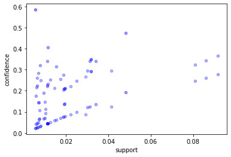

```python
plt.xlabel('support')
plt.ylabel('confidence')
for i in range(a_r.shape[0]):
    plt.scatter(a_r.support[i],a_r.confidence[i],s=20,c='b',alpha=(a_r.lift.iloc[i])/(a_r.lift.iloc[0])*0.8/(a_r.lift.iloc[0]-a_r.lift.iloc[-1])+0.2)
```

绘制support-confidence散点图  
其中cosine值的大小通过透明度反应出来

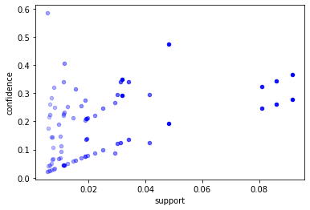

```python
plt.xlabel('support')
plt.ylabel('confidence')
a_r = a_r.sort_values(by='cosine',ascending=False).reset_index(drop=True)
for i in range(a_r.shape[0]):
    plt.scatter(a_r.support[i],a_r.confidence[i],s=20,c='b',alpha=(a_r.cosine.iloc[i])/(a_r.cosine.iloc[0]))
```

绘制support-confidence散点图  
其中Kulc值的大小通过透明度反应出来

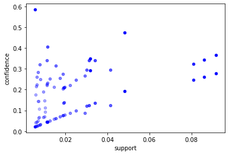

```python
plt.xlabel('support')
plt.ylabel('confidence')
a_r = a_r.sort_values(by='Kulc',ascending=False).reset_index(drop=True)
for i in range(a_r.shape[0]):
    plt.scatter(a_r.support[i],a_r.confidence[i],s=20,c='b',alpha=(a_r.Kulc.iloc[i])/(a_r.Kulc.iloc[0]))
```

绘制support-confidence散点图  
其中Jaccard值的大小通过透明度反应出来

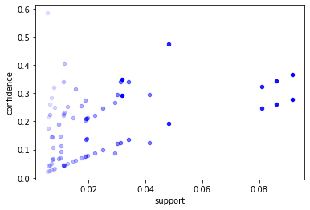

```python
plt.xlabel('support')
plt.ylabel('confidence')
a_r = a_r.sort_values(by='Jaccard',ascending=False).reset_index(drop=True)
for i in range(a_r.shape[0]):
    plt.scatter(a_r.support[i],a_r.confidence[i],s=20,c='b',alpha=(a_r.Jaccard.iloc[i])/(a_r.Jaccard.iloc[0]))
```

# 对DE数据集进行频繁模式与关联规则挖掘

```python
file1 = "DEvideos.csv"
file2 = "DE_category_id.json"
data = pd.read_csv(file1, keep_default_na=False, low_memory=False)
data
```

|  | video_id | trending_date | title | channel_title | category_id | publish_time | tags | views | likes | dislikes | comment_count | thumbnail_link | comments_disabled | ratings_disabled | video_error_or_removed | description |
| --- | --- | --- | --- | --- | --- | --- | --- | --- | --- | --- | --- | --- | --- | --- | --- | --- |
| 0 | LgVi6y5QIjM | 17.14.11 | Sing zu Ende! \| Gesangseinlagen vom Feinsten \|... | inscope21 | 24 | 2017-11-13T17:08:49.000Z | inscope21\|"sing zu ende"\|"gesangseinlagen"\|"ge... | 252786 | 35885 | 230 | 1539 | https://i.ytimg.com/vi/LgVi6y5QIjM/default.jpg | False | False | False | Heute gibt es mal wieder ein neues Format... w... |
| 1 | Bayt7uQith4 | 17.14.11 | Kinder ferngesteuert im Kiosk! Erwachsene abzo... | LUKE! Die Woche und ich | 23 | 2017-11-12T22:30:01.000Z | Kinder\|"ferngesteuert"\|"Kinder ferngesteuert"\|... | 797196 | 53576 | 302 | 1278 | https://i.ytimg.com/vi/Bayt7uQith4/default.jpg | False | False | False | Kinder ferngesteuert! Kinder lassen sich sooo ... |
| 2 | 1ZAPwfrtAFY | 17.14.11 | The Trump Presidency: Last Week Tonight with J... | LastWeekTonight | 24 | 2017-11-13T07:30:00.000Z | last week tonight trump presidency\|"last week ... | 2418783 | 97190 | 6146 | 12703 | https://i.ytimg.com/vi/1ZAPwfrtAFY/default.jpg | False | False | False | One year after the presidential election, John... |
| 3 | AHtypnRk7JE | 17.14.11 | Das Fermi-Paradoxon | 100SekundenPhysik | 27 | 2017-11-12T15:00:01.000Z | Physik\|"Wissenschaft"\|"Technik"\|"Science-Ficti... | 380247 | 31821 | 458 | 1955 | https://i.ytimg.com/vi/AHtypnRk7JE/default.jpg | False | False | False | ►Alle Videos: http://bit.ly/1fa7Tw3\n\n\n✚Snap... |
| 4 | ZJ9We4bjcg0 | 17.14.11 | 18 SONGS mit Kelly MissesVlog (Sing-off) | rezo | 24 | 2017-11-12T13:10:36.000Z | kelly\|"missesvlog"\|"kelly song"\|"bausa"\|"bausa... | 822213 | 100684 | 2467 | 10244 | https://i.ytimg.com/vi/ZJ9We4bjcg0/default.jpg | False | False | False | 18 Song Mashup über den (veränderten) Beat von... |
| ... | ... | ... | ... | ... | ... | ... | ... | ... | ... | ... | ... | ... | ... | ... | ... | ... |
| 40835 | fn5WNxy-Wcw | 18.14.06 | KINGDOM HEARTS III – E3 2018 Pirates of the Ca... | Kingdom Hearts | 20 | 2018-06-12T01:54:02.000Z | Kingdom Hearts\|"KH3"\|"Kingdom Hearts 3"\|"Pirat... | 1394530 | 46778 | 501 | 9878 | https://i.ytimg.com/vi/fn5WNxy-Wcw/default.jpg | False | False | False | Find out more about Kingdom Hearts 3: https://... |
| 40836 | zAFv43lxqHE | 18.14.06 | YMS: The Visit | YourMovieSucksDOTorg | 24 | 2018-06-13T21:58:43.000Z | [none] | 139733 | 11155 | 119 | 1968 | https://i.ytimg.com/vi/zAFv43lxqHE/default.jpg | False | False | False | Patreon: http://www.patreon.com/YMSTwitch: htt... |
| 40837 | zSXG5I6Y2fA | 18.14.06 | Ungut umgeschult – Grünwald als Ersthelfer am ... | Grünwald Freitagscomedy | 24 | 2018-06-12T10:01:28.000Z | Günter Grünwald\|"Grünwald Freitagscomedy"\|"Gün... | 26054 | 364 | 11 | 8 | https://i.ytimg.com/vi/zSXG5I6Y2fA/default.jpg | False | False | False | Günter versucht sich als Ersthelfer bei einem ... |
| 40838 | 5d115sePmaU | 18.14.06 | Assassin's Creed Odyssey: E3 2018 Welt-Enthüll... | Assassin's Creed DE | 20 | 2018-06-11T21:16:55.000Z | Assassin's Creed\|"Assassins Creed"\|"Assassin's... | 1139198 | 14900 | 1421 | 1587 | https://i.ytimg.com/vi/5d115sePmaU/default.jpg | False | False | False | Vom verstoßenen Söldner zum legendären Helden,... |
| 40839 | go-F6xvezAM | 18.14.06 | Гироскутер - Азбука Уральских Пельменей Б - Ур... | Уральские Пельмени | 23 | 2018-06-13T15:02:15.000Z | Гироскутер\|"уральские пельмени гироскутер"\|"мя... | 316328 | 11394 | 352 | 550 | https://i.ytimg.com/vi/go-F6xvezAM/default.jpg | False | False | False | Популярный номер из нового шоу Азбука Уральски... |

40840 rows × 16 columns

```python
print("数据包含：")
title_list = ('video_id  视频id','trending_date  流行日期','title  标题',
              'channel_title  频道标题','category_id  类别id','publish_time  发布时间',
              'tags  标签','views  观看量','likes  点赞量','dislikes  踩量',
              'comment_count  评论数量','thumbnail_link  视频链接',
              'comments_disabled  是否禁止评论','ratings_disabled  是否禁止评分',
              'video_error_or_removed  视频是否失效或被移除','description  介绍')
for i in range(len(title_list)):
    print(str(i+1) + '. ' + title_list[i])
```

```
数据包含：
1. video_id  视频id
2. trending_date  流行日期
3. title  标题
4. channel_title  频道标题
5. category_id  类别id
6. publish_time  发布时间
7. tags  标签
8. views  观看量
9. likes  点赞量
10. dislikes  踩量
11. comment_count  评论数量
12. thumbnail_link  视频链接
13. comments_disabled  是否禁止评论
14. ratings_disabled  是否禁止评分
15. video_error_or_removed  视频是否失效或被移除
16. description  介绍
```

# 对数据集进行处理，转换成适合进行关联规则挖掘的形式

在数据处理时，我们挖掘视频类别(category)与观看量(views)的关联关系，从而挖掘出更多人喜欢的视频类别。

```python
df = data[['category_id','views']]
df
```

|  | category_id | views |
| --- | --- | --- |
| 0 | 24 | 252786 |
| 1 | 23 | 797196 |
| 2 | 24 | 2418783 |
| 3 | 27 | 380247 |
| 4 | 24 | 822213 |
| ... | ... | ... |
| 40835 | 20 | 1394530 |
| 40836 | 24 | 139733 |
| 40837 | 24 | 26054 |
| 40838 | 20 | 1139198 |
| 40839 | 23 | 316328 |

40840 rows × 2 columns

把.json文件中的category_id映射到具体的category类别名

```python
with open(file2, 'r') as f:
    content = json.load(f)
category_map = {}
for i in content['items']:
    category_map[int(i['id'])] = i['snippet']['title']
category_map
```

```
{1: 'Film & Animation',
 2: 'Autos & Vehicles',
 10: 'Music',
 15: 'Pets & Animals',
 17: 'Sports',
 18: 'Short Movies',
 19: 'Travel & Events',
 20: 'Gaming',
 21: 'Videoblogging',
 22: 'People & Blogs',
 23: 'Comedy',
 24: 'Entertainment',
 25: 'News & Politics',
 26: 'Howto & Style',
 27: 'Education',
```

[output cut: 16 more lines]

```python
t = df['category_id'].map(category_map)
df = pd.concat([df,t],axis=1)
df.columns=['category_id','views','category']
```

由于观看量（views）为数值型数据，需要将其转化为离散型数据。按照五数分布及离群点划分视频观看等级，并按照模型传入数据的格式将其转换为模型可接受的数据。

```python
grade = []
for i in df['views'].values:
    views_map = lambda x:{x>=1067150:'A',443101<=x<1067150:'B',119277<=x<443101:'C',
                          27068<=x<119277:'D',518<=x<27068:'E'}
    grade.append(views_map(i)[True])
df['views_grade'] = grade
df = df.drop(['category_id', 'views'], axis = 1)
df
```

|  | category | views_grade |
| --- | --- | --- |
| 0 | Entertainment | C |
| 1 | Comedy | B |
| 2 | Entertainment | A |
| 3 | Education | C |
| 4 | Entertainment | B |
| ... | ... | ... |
| 40835 | Gaming | A |
| 40836 | Entertainment | C |
| 40837 | Entertainment | E |
| 40838 | Gaming | A |
| 40839 | Comedy | C |

40840 rows × 2 columns

```python
def deal(data):
    return data.dropna().tolist()
df_arr = df.apply(deal,axis=1).tolist() # 转化成列表
te = TE()  # 定义模型
df_tf = te.fit_transform(df_arr)
df = pd.DataFrame(df_tf,columns=te.columns_)
df
```

|  | A | Autos & Vehicles | B | C | Comedy | D | E | Education | Entertainment | Film & Animation | ... | Movies | Music | News & Politics | People & Blogs | Pets & Animals | Science & Technology | Shows | Sports | Trailers | Travel & Events |
| --- | --- | --- | --- | --- | --- | --- | --- | --- | --- | --- | --- | --- | --- | --- | --- | --- | --- | --- | --- | --- | --- |
| 0 | False | False | False | True | False | False | False | False | True | False | ... | False | False | False | False | False | False | False | False | False | False |
| 1 | False | False | True | False | True | False | False | False | False | False | ... | False | False | False | False | False | False | False | False | False | False |
| 2 | True | False | False | False | False | False | False | False | True | False | ... | False | False | False | False | False | False | False | False | False | False |
| 3 | False | False | False | True | False | False | False | True | False | False | ... | False | False | False | False | False | False | False | False | False | False |
| 4 | False | False | True | False | False | False | False | False | True | False | ... | False | False | False | False | False | False | False | False | False | False |
| ... | ... | ... | ... | ... | ... | ... | ... | ... | ... | ... | ... | ... | ... | ... | ... | ... | ... | ... | ... | ... | ... |
| 40835 | True | False | False | False | False | False | False | False | False | False | ... | False | False | False | False | False | False | False | False | False | False |
| 40836 | False | False | False | True | False | False | False | False | True | False | ... | False | False | False | False | False | False | False | False | False | False |
| 40837 | False | False | False | False | False | False | True | False | True | False | ... | False | False | False | False | False | False | False | False | False | False |
| 40838 | True | False | False | False | False | False | False | False | False | False | ... | False | False | False | False | False | False | False | False | False | False |
| 40839 | False | False | False | True | True | False | False | False | False | False | ... | False | False | False | False | False | False | False | False | False | False |

40840 rows × 22 columns

# 找出频繁模式

```python
freq_itemsets = apriori(df,min_support=0.005,use_colnames=True)
freq_itemsets.sort_values(by='support',ascending=False,inplace=True)
freq_itemsets
```

|  | support | itemsets |
| --- | --- | --- |
| 8 | 0.374437 | (Entertainment) |
| 5 | 0.250024 | (D) |
| 3 | 0.250000 | (C) |
| 6 | 0.249976 | (E) |
| 14 | 0.146621 | (People & Blogs) |
| ... | ... | ... |
| 15 | 0.006146 | (Pets & Animals) |
| 57 | 0.005975 | (E, Music) |
| 50 | 0.005779 | (D, Science & Technology) |
| 25 | 0.005681 | (Autos & Vehicles, D) |
| 22 | 0.005240 | (A, News & Politics) |

62 rows × 2 columns

# 导出关联规则，计算其支持度和置信度

```python
a_r = ar(freq_itemsets,metric='lift')
a_r = a_r.sort_values(by='lift',ascending=False).reset_index(drop=True)
a_r
```

|  | antecedents | consequents | antecedent support | consequent support | support | confidence | lift | leverage | conviction |
| --- | --- | --- | --- | --- | --- | --- | --- | --- | --- |
| 0 | (Music) | (A) | 0.058080 | 0.116112 | 0.019662 | 0.338533 | 2.915581 | 0.012918 | 1.336254 |
| 1 | (A) | (Music) | 0.116112 | 0.058080 | 0.019662 | 0.169338 | 2.915581 | 0.012918 | 1.133938 |
| 2 | (Education) | (E) | 0.020666 | 0.249976 | 0.012610 | 0.610190 | 2.440997 | 0.007444 | 1.924075 |
| 3 | (E) | (Education) | 0.249976 | 0.020666 | 0.012610 | 0.050446 | 2.440997 | 0.007444 | 1.031362 |
| 4 | (E) | (Howto & Style) | 0.249976 | 0.042728 | 0.021817 | 0.087276 | 2.042607 | 0.011136 | 1.048808 |
| ... | ... | ... | ... | ... | ... | ... | ... | ... | ... |
| 57 | (People & Blogs) | (C) | 0.146621 | 0.250000 | 0.032762 | 0.223447 | 0.893788 | -0.003893 | 0.965806 |
| 58 | (C) | (Music) | 0.250000 | 0.058080 | 0.012439 | 0.049755 | 0.856661 | -0.002081 | 0.991239 |
| 59 | (Music) | (C) | 0.058080 | 0.250000 | 0.012439 | 0.214165 | 0.856661 | -0.002081 | 0.954399 |
| 60 | (Entertainment) | (A) | 0.374437 | 0.116112 | 0.036117 | 0.096456 | 0.830715 | -0.007360 | 0.978246 |
| 61 | (A) | (Entertainment) | 0.116112 | 0.374437 | 0.036117 | 0.311050 | 0.830715 | -0.007360 | 0.907995 |

62 rows × 9 columns

# 对规则进行评价

对规则进行评价,计算余弦、Kulc和Jaccard

```python
t = []
for i in range(a_r.shape[0]):
    item = a_r.iloc[i]
    t.append(item.support/math.sqrt(item['antecedent support']*item['consequent support']))
a_r['cosine'] = t
```

```python
t = []
for i in range(a_r.shape[0]):
    item = a_r.iloc[i]
    t.append(0.5*(item.support/item['antecedent support']+item.support/item['consequent support']))
a_r['Kulc'] = t
```

```python
t = []
for i in range(a_r.shape[0]):
    item = a_r.iloc[i]
    t.append(item.support/(item['antecedent support']+item['consequent support']-item.support))
a_r['Jaccard'] = t
```

```python
a_r
```

|  | antecedents | consequents | antecedent support | consequent support | support | confidence | lift | leverage | conviction | cosine | Kulc | Jaccard |
| --- | --- | --- | --- | --- | --- | --- | --- | --- | --- | --- | --- | --- |
| 0 | (Music) | (A) | 0.058080 | 0.116112 | 0.019662 | 0.338533 | 2.915581 | 0.012918 | 1.336254 | 0.239429 | 0.253935 | 0.127238 |
| 1 | (A) | (Music) | 0.116112 | 0.058080 | 0.019662 | 0.169338 | 2.915581 | 0.012918 | 1.133938 | 0.239429 | 0.253935 | 0.127238 |
| 2 | (Education) | (E) | 0.020666 | 0.249976 | 0.012610 | 0.610190 | 2.440997 | 0.007444 | 1.924075 | 0.175446 | 0.330318 | 0.048871 |
| 3 | (E) | (Education) | 0.249976 | 0.020666 | 0.012610 | 0.050446 | 2.440997 | 0.007444 | 1.031362 | 0.175446 | 0.330318 | 0.048871 |
| 4 | (E) | (Howto & Style) | 0.249976 | 0.042728 | 0.021817 | 0.087276 | 2.042607 | 0.011136 | 1.048808 | 0.211100 | 0.298939 | 0.080539 |
| ... | ... | ... | ... | ... | ... | ... | ... | ... | ... | ... | ... | ... |
| 57 | (People & Blogs) | (C) | 0.146621 | 0.250000 | 0.032762 | 0.223447 | 0.893788 | -0.003893 | 0.965806 | 0.171121 | 0.177247 | 0.090040 |
| 58 | (C) | (Music) | 0.250000 | 0.058080 | 0.012439 | 0.049755 | 0.856661 | -0.002081 | 0.991239 | 0.103227 | 0.131960 | 0.042074 |
| 59 | (Music) | (C) | 0.058080 | 0.250000 | 0.012439 | 0.214165 | 0.856661 | -0.002081 | 0.954399 | 0.103227 | 0.131960 | 0.042074 |
| 60 | (Entertainment) | (A) | 0.374437 | 0.116112 | 0.036117 | 0.096456 | 0.830715 | -0.007360 | 0.978246 | 0.173212 | 0.203753 | 0.079476 |
| 61 | (A) | (Entertainment) | 0.116112 | 0.374437 | 0.036117 | 0.311050 | 0.830715 | -0.007360 | 0.907995 | 0.173212 | 0.203753 | 0.079476 |

62 rows × 12 columns

# 对挖掘结果进行分析

```python
a_r = a_r.sort_values(by='lift',ascending=False).reset_index(drop=True)
a_r.head(30)
```

|  | antecedents | consequents | antecedent support | consequent support | support | confidence | lift | leverage | conviction | cosine | Kulc | Jaccard |
| --- | --- | --- | --- | --- | --- | --- | --- | --- | --- | --- | --- | --- |
| 0 | (Music) | (A) | 0.058080 | 0.116112 | 0.019662 | 0.338533 | 2.915581 | 0.012918 | 1.336254 | 0.239429 | 0.253935 | 0.127238 |
| 1 | (A) | (Music) | 0.116112 | 0.058080 | 0.019662 | 0.169338 | 2.915581 | 0.012918 | 1.133938 | 0.239429 | 0.253935 | 0.127238 |
| 2 | (Education) | (E) | 0.020666 | 0.249976 | 0.012610 | 0.610190 | 2.440997 | 0.007444 | 1.924075 | 0.175446 | 0.330318 | 0.048871 |
| 3 | (E) | (Education) | 0.249976 | 0.020666 | 0.012610 | 0.050446 | 2.440997 | 0.007444 | 1.031362 | 0.175446 | 0.330318 | 0.048871 |
| 4 | (E) | (Howto & Style) | 0.249976 | 0.042728 | 0.021817 | 0.087276 | 2.042607 | 0.011136 | 1.048808 | 0.211100 | 0.298939 | 0.080539 |
| 5 | (Howto & Style) | (E) | 0.042728 | 0.249976 | 0.021817 | 0.510602 | 2.042607 | 0.011136 | 1.532544 | 0.211100 | 0.298939 | 0.080539 |
| 6 | (News & Politics) | (E) | 0.071866 | 0.249976 | 0.035088 | 0.488245 | 1.953173 | 0.017123 | 1.465594 | 0.261788 | 0.314306 | 0.122364 |
| 7 | (E) | (News & Politics) | 0.249976 | 0.071866 | 0.035088 | 0.140366 | 1.953173 | 0.017123 | 1.079686 | 0.261788 | 0.314306 | 0.122364 |
| 8 | (Comedy) | (B) | 0.062047 | 0.133888 | 0.015475 | 0.249408 | 1.862806 | 0.007168 | 1.153905 | 0.169785 | 0.182495 | 0.085753 |
| 9 | (B) | (Comedy) | 0.133888 | 0.062047 | 0.015475 | 0.115582 | 1.862806 | 0.007168 | 1.060531 | 0.169785 | 0.182495 | 0.085753 |
| 10 | (C) | (Comedy) | 0.250000 | 0.062047 | 0.023090 | 0.092360 | 1.488556 | 0.007578 | 1.033398 | 0.185394 | 0.232250 | 0.079908 |
| 11 | (Comedy) | (C) | 0.062047 | 0.250000 | 0.023090 | 0.372139 | 1.488556 | 0.007578 | 1.194532 | 0.185394 | 0.232250 | 0.079908 |
| 12 | (E) | (People & Blogs) | 0.249976 | 0.146621 | 0.053036 | 0.212166 | 1.447036 | 0.016385 | 1.083196 | 0.277029 | 0.286945 | 0.154372 |
| 13 | (People & Blogs) | (E) | 0.146621 | 0.249976 | 0.053036 | 0.361723 | 1.447036 | 0.016385 | 1.175078 | 0.277029 | 0.286945 | 0.154372 |
| 14 | (D) | (Gaming) | 0.250024 | 0.038320 | 0.013834 | 0.055332 | 1.443948 | 0.004253 | 1.018009 | 0.141337 | 0.208177 | 0.050397 |
| 15 | (Gaming) | (D) | 0.038320 | 0.250024 | 0.013834 | 0.361022 | 1.443948 | 0.004253 | 1.173712 | 0.141337 | 0.208177 | 0.050397 |
| 16 | (Autos & Vehicles) | (E) | 0.021376 | 0.249976 | 0.007664 | 0.358534 | 1.434276 | 0.002321 | 1.169235 | 0.104844 | 0.194597 | 0.029065 |
| 17 | (E) | (Autos & Vehicles) | 0.249976 | 0.021376 | 0.007664 | 0.030659 | 1.434276 | 0.002321 | 1.009577 | 0.104844 | 0.194597 | 0.029065 |
| 18 | (Comedy) | (A) | 0.062047 | 0.116112 | 0.010186 | 0.164167 | 1.413875 | 0.002982 | 1.057494 | 0.120008 | 0.125947 | 0.060641 |
| 19 | (A) | (Comedy) | 0.116112 | 0.062047 | 0.010186 | 0.087727 | 1.413875 | 0.002982 | 1.028149 | 0.120008 | 0.125947 | 0.060641 |
| 20 | (Sports) | (A) | 0.067385 | 0.116112 | 0.010284 | 0.152616 | 1.314392 | 0.002460 | 1.043079 | 0.116264 | 0.120593 | 0.059372 |
| 21 | (A) | (Sports) | 0.116112 | 0.067385 | 0.010284 | 0.088570 | 1.314392 | 0.002460 | 1.023244 | 0.116264 | 0.120593 | 0.059372 |
| 22 | (A) | (Film & Animation) | 0.116112 | 0.058178 | 0.008864 | 0.076339 | 1.312159 | 0.002109 | 1.019662 | 0.107846 | 0.114348 | 0.053582 |
| 23 | (Film & Animation) | (A) | 0.058178 | 0.116112 | 0.008864 | 0.152357 | 1.312159 | 0.002109 | 1.042760 | 0.107846 | 0.114348 | 0.053582 |
| 24 | (Music) | (B) | 0.058080 | 0.133888 | 0.010162 | 0.174958 | 1.306744 | 0.002385 | 1.049779 | 0.115233 | 0.125427 | 0.055892 |
| 25 | (B) | (Music) | 0.133888 | 0.058080 | 0.010162 | 0.075896 | 1.306744 | 0.002385 | 1.019279 | 0.115233 | 0.125427 | 0.055892 |
| 26 | (Science & Technology) | (E) | 0.019736 | 0.249976 | 0.006440 | 0.326303 | 1.305339 | 0.001506 | 1.113296 | 0.091685 | 0.176032 | 0.024461 |
| 27 | (E) | (Science & Technology) | 0.249976 | 0.019736 | 0.006440 | 0.025762 | 1.305339 | 0.001506 | 1.006185 | 0.091685 | 0.176032 | 0.024461 |
| 28 | (Sports) | (B) | 0.067385 | 0.133888 | 0.011631 | 0.172602 | 1.289147 | 0.002609 | 1.046789 | 0.122449 | 0.129735 | 0.061330 |
| 29 | (B) | (Sports) | 0.133888 | 0.067385 | 0.011631 | 0.086869 | 1.289147 | 0.002609 | 1.021338 | 0.122449 | 0.129735 | 0.061330 |

由结果可以看出，在DE_video数据集中：  
类别（category）与观看量（views）相关性较强的前五个种类为：Music、Education、Howto & Style、News & Politics、Comedy。  
Music种类视频的观看等级为A级，说明观看此类视频的人数最多，Music类别与观看量（views）之间有非常强的相关性。Education种类视频的观看等级为E级，说明观看此类视频的人数最少，但Education类别与观看量之间仍具有很强的相关性。

# 可视化展示

绘制support-confidence散点图  
其中lift值的大小通过透明度反应出来

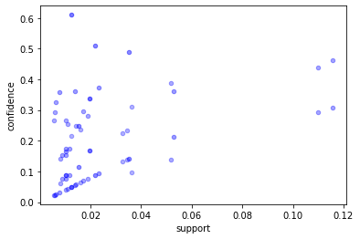

```python
plt.xlabel('support')
plt.ylabel('confidence')
for i in range(a_r.shape[0]):
    plt.scatter(a_r.support[i],a_r.confidence[i],s=20,c='b',alpha=(a_r.lift.iloc[i])/(a_r.lift.iloc[0])*0.8/(a_r.lift.iloc[0]-a_r.lift.iloc[-1])+0.2)
```

绘制support-confidence散点图  
其中cosine值的大小通过透明度反应出来

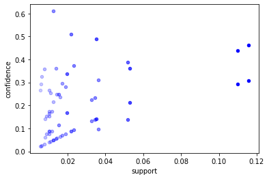

```python
plt.xlabel('support')
plt.ylabel('confidence')
a_r = a_r.sort_values(by='cosine',ascending=False).reset_index(drop=True)
for i in range(a_r.shape[0]):
    plt.scatter(a_r.support[i],a_r.confidence[i],s=20,c='b',alpha=(a_r.cosine.iloc[i])/(a_r.cosine.iloc[0]))
```

绘制support-confidence散点图  
其中Kulc值的大小通过透明度反应出来

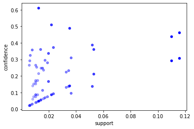

```python
plt.xlabel('support')
plt.ylabel('confidence')
a_r = a_r.sort_values(by='Kulc',ascending=False).reset_index(drop=True)
for i in range(a_r.shape[0]):
    plt.scatter(a_r.support[i],a_r.confidence[i],s=20,c='b',alpha=(a_r.Kulc.iloc[i])/(a_r.Kulc.iloc[0]))
```

绘制support-confidence散点图  
其中Jaccard值的大小通过透明度反应出来

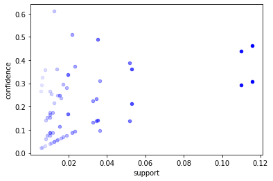

```python
plt.xlabel('support')
plt.ylabel('confidence')
a_r = a_r.sort_values(by='Jaccard',ascending=False).reset_index(drop=True)
for i in range(a_r.shape[0]):
    plt.scatter(a_r.support[i],a_r.confidence[i],s=20,c='b',alpha=(a_r.Jaccard.iloc[i])/(a_r.Jaccard.iloc[0]))
```

# 对FR数据集进行频繁模式与关联规则挖掘

```python
file1 = "FRvideos.csv"
file2 = "FR_category_id.json"
data = pd.read_csv(file1, keep_default_na=False, low_memory=False)
data
```

|  | video_id | trending_date | title | channel_title | category_id | publish_time | tags | views | likes | dislikes | comment_count | thumbnail_link | comments_disabled | ratings_disabled | video_error_or_removed | description |
| --- | --- | --- | --- | --- | --- | --- | --- | --- | --- | --- | --- | --- | --- | --- | --- | --- |
| 0 | Ro6eob0LrCY | 17.14.11 | Malika LePen : Femme de Gauche - Trailer | Le Raptor Dissident | 24 | 2017-11-13T17:32:55.000Z | Raptor"\|"Dissident"\|"Expliquez"\|"moi"\|"cette"\|... | 212702 | 29282 | 1108 | 3817 | https://i.ytimg.com/vi/Ro6eob0LrCY/default.jpg | False | False | False | Dimanche.\n18h30.\nSoyez présents pour la vidé... |
| 1 | Yo84eqYwP98 | 17.14.11 | LA PIRE PARTIE ft Le Rire Jaune, Pierre Croce,... | Le Labo | 24 | 2017-11-12T15:00:02.000Z | [none] | 432721 | 14053 | 576 | 1161 | https://i.ytimg.com/vi/Yo84eqYwP98/default.jpg | False | False | False | Le jeu de société: https://goo.gl/hhG1Ta\n\nGa... |
| 2 | ceqntSXE-10 | 17.14.11 | DESSINS ANIMÉS FRANÇAIS VS RUSSES 2 - Daniil... | Daniil le Russe | 23 | 2017-11-13T17:00:38.000Z | cartoon"\|"pokémon"\|"école"\|"ours"\|"мультфильм | 482153 | 76203 | 477 | 9580 | https://i.ytimg.com/vi/ceqntSXE-10/default.jpg | False | False | False | Une nouvelle dose de dessins animés français e... |
| 3 | WuTFI5qftCE | 17.14.11 | PAPY GRENIER - METAL GEAR SOLID | Joueur Du Grenier | 20 | 2017-11-12T17:00:02.000Z | Papy grenier"\|"Metal Gear Solid"\|"PS1"\|"Tirage... | 925222 | 85016 | 550 | 4303 | https://i.ytimg.com/vi/WuTFI5qftCE/default.jpg | False | False | False | Nouvel ,épisode de Papy Grenier ! Ce mois-ci o... |
| 4 | ee6OFs8TdEg | 17.14.11 | QUI SAUTERA LE PLUS HAUT ? (VÉLO SKATE ROLLER ... | Aurelien Fontenoy | 17 | 2017-11-13T16:30:03.000Z | vélo"\|"vtt"\|"bmx"\|"freestyle"\|"bike"\|"mtb"\|"di... | 141695 | 8091 | 72 | 481 | https://i.ytimg.com/vi/ee6OFs8TdEg/default.jpg | False | False | False | Sauts à plus de 4 mètres de haut dans un tramp... |
| ... | ... | ... | ... | ... | ... | ... | ... | ... | ... | ... | ... | ... | ... | ... | ... | ... |
| 40719 | coVXf3Q9xBk | 18.14.06 | عاجل و رسمي : الملف الأمريكي يفوز بشرف تنظيم ك... | KORA LOVERS | 1 | 2018-06-13T12:31:04.000Z | تنظيم كأس العالم 2026\|"كأس العالم 2026"\|"المغر... | 58758 | 307 | 86 | 485 | https://i.ytimg.com/vi/coVXf3Q9xBk/default.jpg | False | False | False | المغرب تخسر تنظيم مونديال كاس العالم 2026 لصال... |
| 40720 | _umkjOQJvtw | 18.14.06 | شاهد ملخص البرلمان اليوم بحضور اخنوش الدي يعطي... | Jadal جدل | 25 | 2018-06-12T17:51:24.000Z | الباكالوريا في المغرب\|"صحاب الباك"\|"صحاب الباك... | 264639 | 2011 | 999 | 1397 | https://i.ytimg.com/vi/_umkjOQJvtw/default.jpg | False | False | False | ملخص ابرز ما حصل في جلسة البرلمان يوم 12/06/20... |
| 40721 | nt25ec7nzIM | 18.14.06 | UN ANIME EXPLOSIF A VOIR ABSOLUMENT ! | RushManga | 22 | 2018-06-13T11:50:18.000Z | RushManga\|"rush manga"\|"anime a voir"\|"UN ANIM... | 47510 | 4601 | 61 | 615 | https://i.ytimg.com/vi/nt25ec7nzIM/default.jpg | False | False | False | •● Yozakura Quartet ~Hana no Uta~ ●•☆ S'abonne... |
| 40722 | NlxE_QQMRzg | 18.14.06 | Նռան հատիկ, Սերիա 192 / Pomegranate seed / Nra... | PanArmenian TV | 1 | 2018-06-13T18:30:00.000Z | Նռան հատիկ\|"Սերիա 192"\|"Pomegranate seed"\|"Nra... | 78117 | 244 | 74 | 46 | https://i.ytimg.com/vi/NlxE_QQMRzg/default.jpg | False | False | False | Follow Armenia TV on social platforms:Instagra... |
| 40723 | _LgKglfnqlc | 18.14.06 | Mandoumbé ak Koor Gui 2018 Episode 28 | Yesdakar | 24 | 2018-06-13T19:45:14.000Z | ramadan2018\|"koorgui"\|"Mandoumbé" | 46604 | 947 | 37 | 127 | https://i.ytimg.com/vi/_LgKglfnqlc/default.jpg | False | False | False |  |

40724 rows × 16 columns

```python
print("数据包含：")
title_list = ('video_id  视频id','trending_date  流行日期','title  标题',
              'channel_title  频道标题','category_id  类别id','publish_time  发布时间',
              'tags  标签','views  观看量','likes  点赞量','dislikes  踩量',
              'comment_count  评论数量','thumbnail_link  视频链接',
              'comments_disabled  是否禁止评论','ratings_disabled  是否禁止评分',
              'video_error_or_removed  视频是否失效或被移除','description  介绍')
for i in range(len(title_list)):
    print(str(i+1) + '. ' + title_list[i])
```

```
数据包含：
1. video_id  视频id
2. trending_date  流行日期
3. title  标题
4. channel_title  频道标题
5. category_id  类别id
6. publish_time  发布时间
7. tags  标签
8. views  观看量
9. likes  点赞量
10. dislikes  踩量
11. comment_count  评论数量
12. thumbnail_link  视频链接
13. comments_disabled  是否禁止评论
14. ratings_disabled  是否禁止评分
15. video_error_or_removed  视频是否失效或被移除
16. description  介绍
```

# 对数据集进行处理，转换成适合进行关联规则挖掘的形式

在数据处理时，我们挖掘视频类别(category)与观看量(views)的关联关系，从而挖掘出更多人喜欢的视频类别。

```python
df = data[['category_id','views']]
df
```

|  | category_id | views |
| --- | --- | --- |
| 0 | 24 | 212702 |
| 1 | 24 | 432721 |
| 2 | 23 | 482153 |
| 3 | 20 | 925222 |
| 4 | 17 | 141695 |
| ... | ... | ... |
| 40719 | 1 | 58758 |
| 40720 | 25 | 264639 |
| 40721 | 22 | 47510 |
| 40722 | 1 | 78117 |
| 40723 | 24 | 46604 |

40724 rows × 2 columns

把.json文件中的category_id映射到具体的category类别名

```python
with open(file2, 'r') as f:
    content = json.load(f)
category_map = {}
for i in content['items']:
    category_map[int(i['id'])] = i['snippet']['title']
category_map
```

```
{1: 'Film & Animation',
 2: 'Autos & Vehicles',
 10: 'Music',
 15: 'Pets & Animals',
 17: 'Sports',
 18: 'Short Movies',
 19: 'Travel & Events',
 20: 'Gaming',
 21: 'Videoblogging',
 22: 'People & Blogs',
 23: 'Comedy',
 24: 'Entertainment',
 25: 'News & Politics',
 26: 'Howto & Style',
 27: 'Education',
```

[output cut: 16 more lines]

```python
t = df['category_id'].map(category_map)
df = pd.concat([df,t],axis=1)
df.columns=['category_id','views','category']
```

由于观看量（views）为数值型数据，需要将其转化为离散型数据。按照五数分布及离群点划分视频观看等级，并按照模型传入数据的格式将其转换为模型可接受的数据。

```python
grade = []
for i in df['views'].values:
    views_map = lambda x:{x>=651560:'A',270808<=x<651560:'B',73721<=x<270808:'C',
                          16974<=x<73721:'D',223<=x<16974:'E'}
    grade.append(views_map(i)[True])
df['views_grade'] = grade
df = df.drop(['category_id', 'views'], axis = 1)
df
```

|  | category | views_grade |
| --- | --- | --- |
| 0 | Entertainment | C |
| 1 | Entertainment | B |
| 2 | Comedy | B |
| 3 | Gaming | A |
| 4 | Sports | C |
| ... | ... | ... |
| 40719 | Film & Animation | D |
| 40720 | News & Politics | C |
| 40721 | People & Blogs | D |
| 40722 | Film & Animation | C |
| 40723 | Entertainment | D |

40724 rows × 2 columns

```python
def deal(data):
    return data.dropna().tolist()
df_arr = df.apply(deal,axis=1).tolist() # 转化成列表
te = TE()  # 定义模型
df_tf = te.fit_transform(df_arr)
df = pd.DataFrame(df_tf,columns=te.columns_)
df
```

|  | A | Autos & Vehicles | B | C | Comedy | D | E | Education | Entertainment | Film & Animation | ... | Movies | Music | News & Politics | People & Blogs | Pets & Animals | Science & Technology | Shows | Sports | Trailers | Travel & Events |
| --- | --- | --- | --- | --- | --- | --- | --- | --- | --- | --- | --- | --- | --- | --- | --- | --- | --- | --- | --- | --- | --- |
| 0 | False | False | False | True | False | False | False | False | True | False | ... | False | False | False | False | False | False | False | False | False | False |
| 1 | False | False | True | False | False | False | False | False | True | False | ... | False | False | False | False | False | False | False | False | False | False |
| 2 | False | False | True | False | True | False | False | False | False | False | ... | False | False | False | False | False | False | False | False | False | False |
| 3 | True | False | False | False | False | False | False | False | False | False | ... | False | False | False | False | False | False | False | False | False | False |
| 4 | False | False | False | True | False | False | False | False | False | False | ... | False | False | False | False | False | False | False | True | False | False |
| ... | ... | ... | ... | ... | ... | ... | ... | ... | ... | ... | ... | ... | ... | ... | ... | ... | ... | ... | ... | ... | ... |
| 40719 | False | False | False | False | False | True | False | False | False | True | ... | False | False | False | False | False | False | False | False | False | False |
| 40720 | False | False | False | True | False | False | False | False | False | False | ... | False | False | True | False | False | False | False | False | False | False |
| 40721 | False | False | False | False | False | True | False | False | False | False | ... | False | False | False | True | False | False | False | False | False | False |
| 40722 | False | False | False | True | False | False | False | False | False | True | ... | False | False | False | False | False | False | False | False | False | False |
| 40723 | False | False | False | False | False | True | False | False | True | False | ... | False | False | False | False | False | False | False | False | False | False |

40724 rows × 22 columns

# 找出频繁模式

```python
freq_itemsets = apriori(df,min_support=0.005,use_colnames=True)
freq_itemsets.sort_values(by='support',ascending=False,inplace=True)
freq_itemsets
```

|  | support | itemsets |
| --- | --- | --- |
| 3 | 0.250000 | (C) |
| 5 | 0.250000 | (D) |
| 6 | 0.250000 | (E) |
| 8 | 0.241111 | (Entertainment) |
| 14 | 0.140433 | (People & Blogs) |
| 0 | 0.126780 | (A) |
| 2 | 0.123220 | (B) |
| 4 | 0.106645 | (Comedy) |
| 17 | 0.106620 | (Sports) |
| 12 | 0.096896 | (Music) |
| 13 | 0.092132 | (News & Politics) |
| 32 | 0.071309 | (Entertainment, C) |
| 42 | 0.060947 | (Entertainment, D) |
| 11 | 0.057976 | (Howto & Style) |
| 9 | 0.052966 | (Film & Animation) |
| 57 | 0.046827 | (People & Blogs, E) |
| 51 | 0.044568 | (Entertainment, E) |
| 48 | 0.039829 | (People & Blogs, D) |
| 26 | 0.037938 | (Entertainment, B) |
| 56 | 0.036416 | (E, News & Politics) |
| 10 | 0.035827 | (Gaming) |
| 38 | 0.032020 | (People & Blogs, C) |
| 31 | 0.030179 | (C, Comedy) |
| 47 | 0.028828 | (D, News & Politics) |
| 21 | 0.027576 | (A, Music) |
| 19 | 0.026348 | (A, Entertainment) |
| 54 | 0.025341 | (Howto & Style, E) |
| 58 | 0.024777 | (E, Sports) |
| 49 | 0.024629 | (D, Sports) |
| 39 | 0.024580 | (C, Sports) |
| 36 | 0.023893 | (C, Music) |
| 40 | 0.023426 | (D, Comedy) |
| 18 | 0.021339 | (A, Comedy) |
| 16 | 0.019694 | (Science & Technology) |
| 7 | 0.018883 | (Education) |
| 23 | 0.018466 | (A, Sports) |
| 46 | 0.018343 | (D, Music) |
| 25 | 0.018294 | (B, Comedy) |
| 33 | 0.016698 | (C, Film & Animation) |
| 37 | 0.016526 | (C, News & Politics) |
| 1 | 0.016526 | (Autos & Vehicles) |
| 27 | 0.015789 | (B, Music) |
| 30 | 0.014169 | (B, Sports) |
| 41 | 0.013407 | (E, Comedy) |
| 43 | 0.013211 | (D, Film & Animation) |
| 45 | 0.012818 | (Howto & Style, D) |
| 52 | 0.012622 | (E, Film & Animation) |
| 44 | 0.012572 | (D, Gaming) |
| 35 | 0.011909 | (Howto & Style, C) |
| 29 | 0.011394 | (People & Blogs, B) |
| 55 | 0.011296 | (E, Music) |
| 22 | 0.010362 | (A, People & Blogs) |
| 34 | 0.010117 | (C, Gaming) |
| 24 | 0.008103 | (Autos & Vehicles, E) |
| 50 | 0.007735 | (Education, E) |
| 53 | 0.007219 | (E, Gaming) |
| 28 | 0.006458 | (B, News & Politics) |
| 20 | 0.006311 | (A, Film & Animation) |
| 15 | 0.005820 | (Pets & Animals) |

# 导出关联规则，计算其支持度和置信度

```python
a_r = ar(freq_itemsets,metric='lift')
a_r = a_r.sort_values(by='lift',ascending=False).reset_index(drop=True)
a_r
```

|  | antecedents | consequents | antecedent support | consequent support | support | confidence | lift | leverage | conviction |
| --- | --- | --- | --- | --- | --- | --- | --- | --- | --- |
| 0 | (Music) | (A) | 0.096896 | 0.126780 | 0.027576 | 0.284592 | 2.244766 | 0.015291 | 1.220590 |
| 1 | (A) | (Music) | 0.126780 | 0.096896 | 0.027576 | 0.217509 | 2.244766 | 0.015291 | 1.154140 |
| 2 | (Autos & Vehicles) | (E) | 0.016526 | 0.250000 | 0.008103 | 0.490342 | 1.961367 | 0.003972 | 1.471574 |
| 3 | (E) | (Autos & Vehicles) | 0.250000 | 0.016526 | 0.008103 | 0.032413 | 1.961367 | 0.003972 | 1.016420 |
| 4 | (E) | (Howto & Style) | 0.250000 | 0.057976 | 0.025341 | 0.101365 | 1.748412 | 0.010847 | 1.048284 |
| ... | ... | ... | ... | ... | ... | ... | ... | ... | ... |
| 61 | (A) | (Entertainment) | 0.126780 | 0.241111 | 0.026348 | 0.207825 | 0.861947 | -0.004220 | 0.957982 |
| 62 | (C) | (Howto & Style) | 0.250000 | 0.057976 | 0.011909 | 0.047638 | 0.821686 | -0.002584 | 0.989145 |
| 63 | (Howto & Style) | (C) | 0.057976 | 0.250000 | 0.011909 | 0.205421 | 0.821686 | -0.002584 | 0.943897 |
| 64 | (E) | (Gaming) | 0.250000 | 0.035827 | 0.007219 | 0.028877 | 0.806032 | -0.001737 | 0.992844 |
| 65 | (Gaming) | (E) | 0.035827 | 0.250000 | 0.007219 | 0.201508 | 0.806032 | -0.001737 | 0.939270 |

66 rows × 9 columns

# 对规则进行评价

对规则进行评价,计算余弦、Kulc和Jaccard

```python
t = []
for i in range(a_r.shape[0]):
    item = a_r.iloc[i]
    t.append(item.support/math.sqrt(item['antecedent support']*item['consequent support']))
a_r['cosine'] = t
```

```python
t = []
for i in range(a_r.shape[0]):
    item = a_r.iloc[i]
    t.append(0.5*(item.support/item['antecedent support']+item.support/item['consequent support']))
a_r['Kulc'] = t
```

```python
t = []
for i in range(a_r.shape[0]):
    item = a_r.iloc[i]
    t.append(item.support/(item['antecedent support']+item['consequent support']-item.support))
a_r['Jaccard'] = t
```

```python
a_r
```

|  | antecedents | consequents | antecedent support | consequent support | support | confidence | lift | leverage | conviction | cosine | Kulc | Jaccard |
| --- | --- | --- | --- | --- | --- | --- | --- | --- | --- | --- | --- | --- |
| 0 | (Music) | (A) | 0.096896 | 0.126780 | 0.027576 | 0.284592 | 2.244766 | 0.015291 | 1.220590 | 0.248800 | 0.251051 | 0.140621 |
| 1 | (A) | (Music) | 0.126780 | 0.096896 | 0.027576 | 0.217509 | 2.244766 | 0.015291 | 1.154140 | 0.248800 | 0.251051 | 0.140621 |
| 2 | (Autos & Vehicles) | (E) | 0.016526 | 0.250000 | 0.008103 | 0.490342 | 1.961367 | 0.003972 | 1.471574 | 0.126070 | 0.261378 | 0.031357 |
| 3 | (E) | (Autos & Vehicles) | 0.250000 | 0.016526 | 0.008103 | 0.032413 | 1.961367 | 0.003972 | 1.016420 | 0.126070 | 0.261378 | 0.031357 |
| 4 | (E) | (Howto & Style) | 0.250000 | 0.057976 | 0.025341 | 0.101365 | 1.748412 | 0.010847 | 1.048284 | 0.210492 | 0.269234 | 0.089661 |
| ... | ... | ... | ... | ... | ... | ... | ... | ... | ... | ... | ... | ... |
| 61 | (A) | (Entertainment) | 0.126780 | 0.241111 | 0.026348 | 0.207825 | 0.861947 | -0.004220 | 0.957982 | 0.150701 | 0.158551 | 0.077144 |
| 62 | (C) | (Howto & Style) | 0.250000 | 0.057976 | 0.011909 | 0.047638 | 0.821686 | -0.002584 | 0.989145 | 0.098923 | 0.126530 | 0.040226 |
| 63 | (Howto & Style) | (C) | 0.057976 | 0.250000 | 0.011909 | 0.205421 | 0.821686 | -0.002584 | 0.943897 | 0.098923 | 0.126530 | 0.040226 |
| 64 | (E) | (Gaming) | 0.250000 | 0.035827 | 0.007219 | 0.028877 | 0.806032 | -0.001737 | 0.992844 | 0.076282 | 0.115193 | 0.025912 |
| 65 | (Gaming) | (E) | 0.035827 | 0.250000 | 0.007219 | 0.201508 | 0.806032 | -0.001737 | 0.939270 | 0.076282 | 0.115193 | 0.025912 |

66 rows × 12 columns

# 对挖掘结果进行分析

```python
a_r = a_r.sort_values(by='lift',ascending=False).reset_index(drop=True)
a_r.head(30)
```

|  | antecedents | consequents | antecedent support | consequent support | support | confidence | lift | leverage | conviction | cosine | Kulc | Jaccard |
| --- | --- | --- | --- | --- | --- | --- | --- | --- | --- | --- | --- | --- |
| 0 | (Music) | (A) | 0.096896 | 0.126780 | 0.027576 | 0.284592 | 2.244766 | 0.015291 | 1.220590 | 0.248800 | 0.251051 | 0.140621 |
| 1 | (A) | (Music) | 0.126780 | 0.096896 | 0.027576 | 0.217509 | 2.244766 | 0.015291 | 1.154140 | 0.248800 | 0.251051 | 0.140621 |
| 2 | (Autos & Vehicles) | (E) | 0.016526 | 0.250000 | 0.008103 | 0.490342 | 1.961367 | 0.003972 | 1.471574 | 0.126070 | 0.261378 | 0.031357 |
| 3 | (E) | (Autos & Vehicles) | 0.250000 | 0.016526 | 0.008103 | 0.032413 | 1.961367 | 0.003972 | 1.016420 | 0.126070 | 0.261378 | 0.031357 |
| 4 | (E) | (Howto & Style) | 0.250000 | 0.057976 | 0.025341 | 0.101365 | 1.748412 | 0.010847 | 1.048284 | 0.210492 | 0.269234 | 0.089661 |
| 5 | (Howto & Style) | (E) | 0.057976 | 0.250000 | 0.025341 | 0.437103 | 1.748412 | 0.010847 | 1.332393 | 0.210492 | 0.269234 | 0.089661 |
| 6 | (E) | (Education) | 0.250000 | 0.018883 | 0.007735 | 0.030940 | 1.638492 | 0.003014 | 1.012442 | 0.112578 | 0.220281 | 0.029619 |
| 7 | (Education) | (E) | 0.018883 | 0.250000 | 0.007735 | 0.409623 | 1.638492 | 0.003014 | 1.270374 | 0.112578 | 0.220281 | 0.029619 |
| 8 | (News & Politics) | (E) | 0.092132 | 0.250000 | 0.036416 | 0.395256 | 1.581023 | 0.013383 | 1.240194 | 0.239947 | 0.270460 | 0.119116 |
| 9 | (E) | (News & Politics) | 0.250000 | 0.092132 | 0.036416 | 0.145663 | 1.581023 | 0.013383 | 1.062658 | 0.239947 | 0.270460 | 0.119116 |
| 10 | (A) | (Comedy) | 0.126780 | 0.106645 | 0.021339 | 0.168313 | 1.578259 | 0.007818 | 1.074148 | 0.183516 | 0.184203 | 0.100614 |
| 11 | (Comedy) | (A) | 0.106645 | 0.126780 | 0.021339 | 0.200092 | 1.578259 | 0.007818 | 1.091650 | 0.183516 | 0.184203 | 0.100614 |
| 12 | (Gaming) | (D) | 0.035827 | 0.250000 | 0.012572 | 0.350925 | 1.403701 | 0.003616 | 1.155491 | 0.132846 | 0.200608 | 0.046010 |
| 13 | (D) | (Gaming) | 0.250000 | 0.035827 | 0.012572 | 0.050290 | 1.403701 | 0.003616 | 1.015229 | 0.132846 | 0.200608 | 0.046010 |
| 14 | (Comedy) | (B) | 0.106645 | 0.123220 | 0.018294 | 0.171540 | 1.392151 | 0.005153 | 1.058326 | 0.159586 | 0.160003 | 0.086467 |
| 15 | (B) | (Comedy) | 0.123220 | 0.106645 | 0.018294 | 0.148466 | 1.392151 | 0.005153 | 1.049112 | 0.159586 | 0.160003 | 0.086467 |
| 16 | (A) | (Sports) | 0.126780 | 0.106620 | 0.018466 | 0.145652 | 1.366081 | 0.004948 | 1.045686 | 0.158826 | 0.159422 | 0.085913 |
| 17 | (Sports) | (A) | 0.106620 | 0.126780 | 0.018466 | 0.173192 | 1.366081 | 0.004948 | 1.056134 | 0.158826 | 0.159422 | 0.085913 |
| 18 | (E) | (People & Blogs) | 0.250000 | 0.140433 | 0.046827 | 0.187310 | 1.333800 | 0.011719 | 1.057681 | 0.249917 | 0.260380 | 0.136282 |
| 19 | (People & Blogs) | (E) | 0.140433 | 0.250000 | 0.046827 | 0.333450 | 1.333800 | 0.011719 | 1.125197 | 0.249917 | 0.260380 | 0.136282 |
| 20 | (B) | (Music) | 0.123220 | 0.096896 | 0.015789 | 0.128139 | 1.322433 | 0.003850 | 1.035834 | 0.144500 | 0.145544 | 0.077274 |
| 21 | (Music) | (B) | 0.096896 | 0.123220 | 0.015789 | 0.162950 | 1.322433 | 0.003850 | 1.047464 | 0.144500 | 0.145544 | 0.077274 |
| 22 | (B) | (Entertainment) | 0.123220 | 0.241111 | 0.037938 | 0.307892 | 1.276971 | 0.008229 | 1.096489 | 0.220105 | 0.232620 | 0.116235 |
| 23 | (Entertainment) | (B) | 0.241111 | 0.123220 | 0.037938 | 0.157348 | 1.276971 | 0.008229 | 1.040501 | 0.220105 | 0.232620 | 0.116235 |
| 24 | (C) | (Film & Animation) | 0.250000 | 0.052966 | 0.016698 | 0.066791 | 1.261011 | 0.003456 | 1.014814 | 0.145107 | 0.191022 | 0.058329 |
| 25 | (Film & Animation) | (C) | 0.052966 | 0.250000 | 0.016698 | 0.315253 | 1.261011 | 0.003456 | 1.095295 | 0.145107 | 0.191022 | 0.058329 |
| 26 | (D) | (News & Politics) | 0.250000 | 0.092132 | 0.028828 | 0.115313 | 1.251599 | 0.005795 | 1.026202 | 0.189951 | 0.214106 | 0.092013 |
| 27 | (News & Politics) | (D) | 0.092132 | 0.250000 | 0.028828 | 0.312900 | 1.251599 | 0.005795 | 1.091544 | 0.189951 | 0.214106 | 0.092013 |
| 28 | (C) | (Entertainment) | 0.250000 | 0.241111 | 0.071309 | 0.285237 | 1.183013 | 0.011032 | 1.061736 | 0.290448 | 0.290495 | 0.169864 |
| 29 | (Entertainment) | (C) | 0.241111 | 0.250000 | 0.071309 | 0.295753 | 1.183013 | 0.011032 | 1.064967 | 0.290448 | 0.290495 | 0.169864 |

由结果可以看出，在FR_video数据集中：  
类别（category）与观看量（views）相关性较强的前五个种类为：Music、Autos & Vehicles、Howto & Style、Education、News & Politics。  
Music种类视频的观看等级为A级，说明观看此类视频的人数最多，Music类别与观看量（views）之间有非常强的相关性。Autos & Vehicles种类视频的观看等级为E级，说明观看此类视频的人数最少，但Autos & Vehicles类别与观看量之间仍具有很强的相关性。

# 可视化展示

绘制support-confidence散点图  
其中lift值的大小通过透明度反应出来

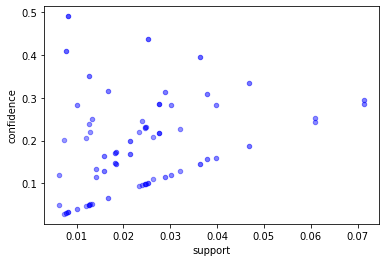

```python
plt.xlabel('support')
plt.ylabel('confidence')
for i in range(a_r.shape[0]):
    plt.scatter(a_r.support[i],a_r.confidence[i],s=20,c='b',alpha=(a_r.lift.iloc[i])/(a_r.lift.iloc[0])*0.8/(a_r.lift.iloc[0]-a_r.lift.iloc[-1])+0.2)
```

绘制support-confidence散点图  
其中cosine值的大小通过透明度反应出来

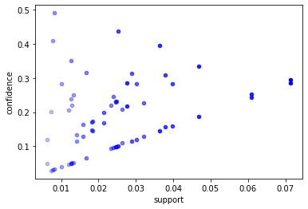

```python
plt.xlabel('support')
plt.ylabel('confidence')
a_r = a_r.sort_values(by='cosine',ascending=False).reset_index(drop=True)
for i in range(a_r.shape[0]):
    plt.scatter(a_r.support[i],a_r.confidence[i],s=20,c='b',alpha=(a_r.cosine.iloc[i])/(a_r.cosine.iloc[0]))
```

绘制support-confidence散点图  
其中Kulc值的大小通过透明度反应出来

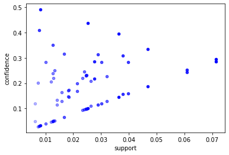

```python
plt.xlabel('support')
plt.ylabel('confidence')
a_r = a_r.sort_values(by='Kulc',ascending=False).reset_index(drop=True)
for i in range(a_r.shape[0]):
    plt.scatter(a_r.support[i],a_r.confidence[i],s=20,c='b',alpha=(a_r.Kulc.iloc[i])/(a_r.Kulc.iloc[0]))
```

绘制support-confidence散点图  
其中Jaccard值的大小通过透明度反应出来

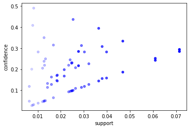

```python
plt.xlabel('support')
plt.ylabel('confidence')
a_r = a_r.sort_values(by='Jaccard',ascending=False).reset_index(drop=True)
for i in range(a_r.shape[0]):
    plt.scatter(a_r.support[i],a_r.confidence[i],s=20,c='b',alpha=(a_r.Jaccard.iloc[i])/(a_r.Jaccard.iloc[0]))
```

# 对GB数据集进行频繁模式与关联规则挖掘

```python
file1 = "GBvideos.csv"
file2 = "GB_category_id.json"
data = pd.read_csv(file1, keep_default_na=False, low_memory=False)
data
```

|  | video_id | trending_date | title | channel_title | category_id | publish_time | tags | views | likes | dislikes | comment_count | thumbnail_link | comments_disabled | ratings_disabled | video_error_or_removed | description |
| --- | --- | --- | --- | --- | --- | --- | --- | --- | --- | --- | --- | --- | --- | --- | --- | --- |
| 0 | Jw1Y-zhQURU | 17.14.11 | John Lewis Christmas Ad 2017 - #MozTheMonster | John Lewis | 26 | 2017-11-10T07:38:29.000Z | christmas\|"john lewis christmas"\|"john lewis"\|... | 7224515 | 55681 | 10247 | 9479 | https://i.ytimg.com/vi/Jw1Y-zhQURU/default.jpg | False | False | False | Click here to continue the story and make your... |
| 1 | 3s1rvMFUweQ | 17.14.11 | Taylor Swift: …Ready for It? (Live) - SNL | Saturday Night Live | 24 | 2017-11-12T06:24:44.000Z | SNL\|"Saturday Night Live"\|"SNL Season 43"\|"Epi... | 1053632 | 25561 | 2294 | 2757 | https://i.ytimg.com/vi/3s1rvMFUweQ/default.jpg | False | False | False | Musical guest Taylor Swift performs …Ready for... |
| 2 | n1WpP7iowLc | 17.14.11 | Eminem - Walk On Water (Audio) ft. Beyoncé | EminemVEVO | 10 | 2017-11-10T17:00:03.000Z | Eminem\|"Walk"\|"On"\|"Water"\|"Aftermath/Shady/In... | 17158579 | 787420 | 43420 | 125882 | https://i.ytimg.com/vi/n1WpP7iowLc/default.jpg | False | False | False | Eminem's new track Walk on Water ft. Beyoncé i... |
| 3 | PUTEiSjKwJU | 17.14.11 | Goals from Salford City vs Class of 92 and Fri... | Salford City Football Club | 17 | 2017-11-13T02:30:38.000Z | Salford City FC\|"Salford City"\|"Salford"\|"Clas... | 27833 | 193 | 12 | 37 | https://i.ytimg.com/vi/PUTEiSjKwJU/default.jpg | False | False | False | Salford drew 4-4 against the Class of 92 and F... |
| 4 | rHwDegptbI4 | 17.14.11 | Dashcam captures truck's near miss with child ... | Cute Girl Videos | 25 | 2017-11-13T01:45:13.000Z | [none] | 9815 | 30 | 2 | 30 | https://i.ytimg.com/vi/rHwDegptbI4/default.jpg | False | False | False | Dashcam captures truck's near miss with child ... |
| ... | ... | ... | ... | ... | ... | ... | ... | ... | ... | ... | ... | ... | ... | ... | ... | ... |
| 38911 | l884wKofd54 | 18.14.06 | Enrique Iglesias - MOVE TO MIAMI (Official Vid... | EnriqueIglesiasVEVO | 10 | 2018-05-09T07:00:01.000Z | Enrique Iglesias feat. Pitbull\|"MOVE TO MIAMI"... | 25066952 | 268088 | 12783 | 9933 | https://i.ytimg.com/vi/l884wKofd54/default.jpg | False | False | False | NEW SONG - MOVE TO MIAMI feat. Pitbull (Click ... |
| 38912 | IP8k2xkhOdI | 18.14.06 | Jacob Sartorius - Up With It (Official Music V... | Jacob Sartorius | 10 | 2018-05-11T17:09:16.000Z | jacob sartorius\|"jacob"\|"up with it"\|"jacob sa... | 1492219 | 61998 | 13781 | 24330 | https://i.ytimg.com/vi/IP8k2xkhOdI/default.jpg | False | False | False | THE OFFICIAL UP WITH IT MUSIC VIDEO!Get my new... |
| 38913 | Il-an3K9pjg | 18.14.06 | Anne-Marie - 2002 [Official Video] | Anne-Marie | 10 | 2018-05-08T11:05:08.000Z | anne\|"marie"\|"anne-marie"\|"2002"\|"two thousand... | 29641412 | 394830 | 8892 | 19988 | https://i.ytimg.com/vi/Il-an3K9pjg/default.jpg | False | False | False | Get 2002 by Anne-Marie HERE ▶ http://ad.gt/200... |
| 38914 | -DRsfNObKIQ | 18.14.06 | Eleni Foureira - Fuego - Cyprus - LIVE - First... | Eurovision Song Contest | 24 | 2018-05-08T20:32:32.000Z | Eurovision Song Contest\|"2018"\|"Lisbon"\|"Cypru... | 14317515 | 151870 | 45875 | 26766 | https://i.ytimg.com/vi/-DRsfNObKIQ/default.jpg | False | False | False | Eleni Foureira represented Cyprus at the first... |
| 38915 | 4YFo4bdMO8Q | 18.14.06 | KYLE - Ikuyo feat. 2 Chainz & Sophia Black [A... | SuperDuperKyle | 10 | 2018-05-11T04:06:35.000Z | Kyle\|"SuperDuperKyle"\|"Ikuyo"\|"2 Chainz"\|"Soph... | 607552 | 18271 | 274 | 1423 | https://i.ytimg.com/vi/4YFo4bdMO8Q/default.jpg | False | False | False | Debut album 'Light of Mine' out now: http://ky... |

38916 rows × 16 columns

```python
print("数据包含：")
title_list = ('video_id  视频id','trending_date  流行日期','title  标题',
              'channel_title  频道标题','category_id  类别id','publish_time  发布时间',
              'tags  标签','views  观看量','likes  点赞量','dislikes  踩量',
              'comment_count  评论数量','thumbnail_link  视频链接',
              'comments_disabled  是否禁止评论','ratings_disabled  是否禁止评分',
              'video_error_or_removed  视频是否失效或被移除','description  介绍')
for i in range(len(title_list)):
    print(str(i+1) + '. ' + title_list[i])
```

```
数据包含：
1. video_id  视频id
2. trending_date  流行日期
3. title  标题
4. channel_title  频道标题
5. category_id  类别id
6. publish_time  发布时间
7. tags  标签
8. views  观看量
9. likes  点赞量
10. dislikes  踩量
11. comment_count  评论数量
12. thumbnail_link  视频链接
13. comments_disabled  是否禁止评论
14. ratings_disabled  是否禁止评分
15. video_error_or_removed  视频是否失效或被移除
16. description  介绍
```

# 对数据集进行处理，转换成适合进行关联规则挖掘的形式

在数据处理时，我们挖掘视频类别(category)与观看量(views)的关联关系，从而挖掘出更多人喜欢的视频类别。

```python
df = data[['category_id','views']]
df
```

|  | category_id | views |
| --- | --- | --- |
| 0 | 26 | 7224515 |
| 1 | 24 | 1053632 |
| 2 | 10 | 17158579 |
| 3 | 17 | 27833 |
| 4 | 25 | 9815 |
| ... | ... | ... |
| 38911 | 10 | 25066952 |
| 38912 | 10 | 1492219 |
| 38913 | 10 | 29641412 |
| 38914 | 24 | 14317515 |
| 38915 | 10 | 607552 |

38916 rows × 2 columns

把.json文件中的category_id映射到具体的category类别名

```python
with open(file2, 'r') as f:
    content = json.load(f)
category_map = {}
for i in content['items']:
    category_map[int(i['id'])] = i['snippet']['title']
category_map
```

```
{1: 'Film & Animation',
 2: 'Autos & Vehicles',
 10: 'Music',
 15: 'Pets & Animals',
 17: 'Sports',
 18: 'Short Movies',
 19: 'Travel & Events',
 20: 'Gaming',
 21: 'Videoblogging',
 22: 'People & Blogs',
 23: 'Comedy',
 24: 'Entertainment',
 25: 'News & Politics',
 26: 'Howto & Style',
 27: 'Education',
```

[output cut: 16 more lines]

```python
t = df['category_id'].map(category_map)
df = pd.concat([df,t],axis=1)
df.columns=['category_id','views','category']
```

由于观看量（views）为数值型数据，需要将其转化为离散型数据。按照五数分布及离群点划分视频观看等级，并按照模型传入数据的格式将其转换为模型可接受的数据。

```python
grade = []
for i in df['views'].values:
    views_map = lambda x:{x>=8831780:'A',3683628<=x<8831780:'B',981889<=x<3683628:'C',
                          251527<=x<981889:'D',851<=x<251527:'E'}
    grade.append(views_map(i)[True])
df['views_grade'] = grade
df = df.drop(['category_id', 'views'], axis = 1)
df
```

|  | category | views_grade |
| --- | --- | --- |
| 0 | Howto & Style | B |
| 1 | Entertainment | C |
| 2 | Music | A |
| 3 | Sports | E |
| 4 | News & Politics | E |
| ... | ... | ... |
| 38911 | Music | A |
| 38912 | Music | C |
| 38913 | Music | A |
| 38914 | Entertainment | A |
| 38915 | Music | D |

38916 rows × 2 columns

```python
def deal(data):
    return data.dropna().tolist()
df_arr = df.apply(deal,axis=1).tolist() # 转化成列表
te = TE()  # 定义模型
df_tf = te.fit_transform(df_arr)
df = pd.DataFrame(df_tf,columns=te.columns_)
df
```

|  | A | Autos & Vehicles | B | C | Comedy | D | E | Education | Entertainment | Film & Animation | Gaming | Howto & Style | Music | News & Politics | People & Blogs | Pets & Animals | Science & Technology | Shows | Sports | Travel & Events |
| --- | --- | --- | --- | --- | --- | --- | --- | --- | --- | --- | --- | --- | --- | --- | --- | --- | --- | --- | --- | --- |
| 0 | False | False | True | False | False | False | False | False | False | False | False | True | False | False | False | False | False | False | False | False |
| 1 | False | False | False | True | False | False | False | False | True | False | False | False | False | False | False | False | False | False | False | False |
| 2 | True | False | False | False | False | False | False | False | False | False | False | False | True | False | False | False | False | False | False | False |
| 3 | False | False | False | False | False | False | True | False | False | False | False | False | False | False | False | False | False | False | True | False |
| 4 | False | False | False | False | False | False | True | False | False | False | False | False | False | True | False | False | False | False | False | False |
| ... | ... | ... | ... | ... | ... | ... | ... | ... | ... | ... | ... | ... | ... | ... | ... | ... | ... | ... | ... | ... |
| 38911 | True | False | False | False | False | False | False | False | False | False | False | False | True | False | False | False | False | False | False | False |
| 38912 | False | False | False | True | False | False | False | False | False | False | False | False | True | False | False | False | False | False | False | False |
| 38913 | True | False | False | False | False | False | False | False | False | False | False | False | True | False | False | False | False | False | False | False |
| 38914 | True | False | False | False | False | False | False | False | True | False | False | False | False | False | False | False | False | False | False | False |
| 38915 | False | False | False | False | False | True | False | False | False | False | False | False | True | False | False | False | False | False | False | False |

38916 rows × 20 columns

# 找出频繁模式

```python
freq_itemsets = apriori(df,min_support=0.005,use_colnames=True)
freq_itemsets.sort_values(by='support',ascending=False,inplace=True)
freq_itemsets
```

|  | support | itemsets |
| --- | --- | --- |
| 11 | 0.353428 | (Music) |
| 2 | 0.250000 | (C) |
| 4 | 0.250000 | (D) |
| 5 | 0.250000 | (E) |
| 7 | 0.234454 | (Entertainment) |
| 0 | 0.136396 | (A) |
| 1 | 0.113604 | (B) |
| 19 | 0.100062 | (A, Music) |
| 30 | 0.094563 | (C, Music) |
| 37 | 0.075958 | (Entertainment, D) |
| 13 | 0.075188 | (People & Blogs) |
| 8 | 0.066220 | (Film & Animation) |
| 41 | 0.061029 | (D, Music) |
| 23 | 0.059564 | (B, Music) |
| 26 | 0.058536 | (Entertainment, C) |
| 46 | 0.055838 | (Entertainment, E) |
| 10 | 0.049543 | (Howto & Style) |
| 16 | 0.049003 | (Sports) |
| 3 | 0.046973 | (Comedy) |
| 9 | 0.045945 | (Gaming) |
| 50 | 0.038211 | (E, Music) |
| 52 | 0.033328 | (People & Blogs, E) |
| 12 | 0.031478 | (News & Politics) |
| 21 | 0.024334 | (Entertainment, B) |
| 49 | 0.024232 | (Howto & Style, E) |
| 27 | 0.020634 | (C, Film & Animation) |
| 48 | 0.020454 | (E, Gaming) |
| 53 | 0.020069 | (E, Sports) |
| 17 | 0.019786 | (A, Entertainment) |
| 25 | 0.018835 | (C, Comedy) |
| 40 | 0.017602 | (Howto & Style, D) |
| 32 | 0.017242 | (People & Blogs, C) |
| 43 | 0.016754 | (People & Blogs, D) |
| 47 | 0.016548 | (E, Film & Animation) |
| 51 | 0.016240 | (E, News & Politics) |
| 38 | 0.015084 | (D, Film & Animation) |
| 39 | 0.014724 | (D, Gaming) |
| 45 | 0.014544 | (D, Sports) |
| 14 | 0.013722 | (Pets & Animals) |
| 15 | 0.013311 | (Science & Technology) |
| 6 | 0.011743 | (Education) |
| 35 | 0.010587 | (E, Comedy) |
| 34 | 0.009688 | (D, Comedy) |
| 28 | 0.009302 | (C, Gaming) |
| 33 | 0.008326 | (C, Sports) |
| 42 | 0.007632 | (D, News & Politics) |
| 22 | 0.007529 | (B, Film & Animation) |
| 29 | 0.006475 | (Howto & Style, C) |
| 18 | 0.006424 | (A, Film & Animation) |
| 20 | 0.005884 | (B, Comedy) |
| 36 | 0.005859 | (D, Education) |
| 24 | 0.005833 | (People & Blogs, B) |
| 31 | 0.005576 | (C, News & Politics) |
| 44 | 0.005422 | (D, Pets & Animals) |

# 导出关联规则，计算其支持度和置信度

```python
a_r = ar(freq_itemsets,metric='lift')
a_r = a_r.sort_values(by='lift',ascending=False).reset_index(drop=True)
a_r
```

|  | antecedents | consequents | antecedent support | consequent support | support | confidence | lift | leverage | conviction |
| --- | --- | --- | --- | --- | --- | --- | --- | --- | --- |
| 0 | (A) | (Music) | 0.136396 | 0.353428 | 0.100062 | 0.733610 | 2.075698 | 0.051855 | 2.427160 |
| 1 | (Music) | (A) | 0.353428 | 0.136396 | 0.100062 | 0.283118 | 2.075698 | 0.051855 | 1.204666 |
| 2 | (News & Politics) | (E) | 0.031478 | 0.250000 | 0.016240 | 0.515918 | 2.063673 | 0.008371 | 1.549325 |
| 3 | (E) | (News & Politics) | 0.250000 | 0.031478 | 0.016240 | 0.064960 | 2.063673 | 0.008371 | 1.035809 |
| 4 | (Education) | (D) | 0.011743 | 0.250000 | 0.005859 | 0.498906 | 1.995624 | 0.002923 | 1.496725 |
| 5 | (D) | (Education) | 0.250000 | 0.011743 | 0.005859 | 0.023435 | 1.995624 | 0.002923 | 1.011972 |
| 6 | (E) | (Howto & Style) | 0.250000 | 0.049543 | 0.024232 | 0.096927 | 1.956432 | 0.011846 | 1.052470 |
| 7 | (Howto & Style) | (E) | 0.049543 | 0.250000 | 0.024232 | 0.489108 | 1.956432 | 0.011846 | 1.468020 |
| 8 | (Gaming) | (E) | 0.045945 | 0.250000 | 0.020454 | 0.445190 | 1.780761 | 0.008968 | 1.351815 |
| 9 | (E) | (Gaming) | 0.250000 | 0.045945 | 0.020454 | 0.081817 | 1.780761 | 0.008968 | 1.039069 |
| 10 | (People & Blogs) | (E) | 0.075188 | 0.250000 | 0.033328 | 0.443267 | 1.773069 | 0.014531 | 1.347145 |
| 11 | (E) | (People & Blogs) | 0.250000 | 0.075188 | 0.033328 | 0.133313 | 1.773069 | 0.014531 | 1.067066 |
| 12 | (Sports) | (E) | 0.049003 | 0.250000 | 0.020069 | 0.409544 | 1.638175 | 0.007818 | 1.270204 |
| 13 | (E) | (Sports) | 0.250000 | 0.049003 | 0.020069 | 0.080275 | 1.638175 | 0.007818 | 1.034002 |
| 14 | (C) | (Comedy) | 0.250000 | 0.046973 | 0.018835 | 0.075342 | 1.603939 | 0.007092 | 1.030680 |
| 15 | (Comedy) | (C) | 0.046973 | 0.250000 | 0.018835 | 0.400985 | 1.603939 | 0.007092 | 1.252055 |
| 16 | (D) | (Pets & Animals) | 0.250000 | 0.013722 | 0.005422 | 0.021688 | 1.580524 | 0.001991 | 1.008142 |
| 17 | (Pets & Animals) | (D) | 0.013722 | 0.250000 | 0.005422 | 0.395131 | 1.580524 | 0.001991 | 1.239938 |
| 18 | (B) | (Music) | 0.113604 | 0.353428 | 0.059564 | 0.524316 | 1.483516 | 0.019413 | 1.359246 |
| 19 | (Music) | (B) | 0.353428 | 0.113604 | 0.059564 | 0.168533 | 1.483516 | 0.019413 | 1.066063 |
| 20 | (D) | (Howto & Style) | 0.250000 | 0.049543 | 0.017602 | 0.070408 | 1.421162 | 0.005216 | 1.022446 |
| 21 | (Howto & Style) | (D) | 0.049543 | 0.250000 | 0.017602 | 0.355290 | 1.421162 | 0.005216 | 1.163315 |
| 22 | (Entertainment) | (D) | 0.234454 | 0.250000 | 0.075958 | 0.323981 | 1.295923 | 0.017345 | 1.109436 |
| 23 | (D) | (Entertainment) | 0.250000 | 0.234454 | 0.075958 | 0.303834 | 1.295923 | 0.017345 | 1.099660 |
| 24 | (D) | (Gaming) | 0.250000 | 0.045945 | 0.014724 | 0.058896 | 1.281879 | 0.003238 | 1.013761 |
| 25 | (Gaming) | (D) | 0.045945 | 0.250000 | 0.014724 | 0.320470 | 1.281879 | 0.003238 | 1.103704 |
| 26 | (Film & Animation) | (C) | 0.066220 | 0.250000 | 0.020634 | 0.311603 | 1.246411 | 0.004079 | 1.089487 |
| 27 | (C) | (Film & Animation) | 0.250000 | 0.066220 | 0.020634 | 0.082537 | 1.246411 | 0.004079 | 1.017785 |
| 28 | (D) | (Sports) | 0.250000 | 0.049003 | 0.014544 | 0.058177 | 1.187205 | 0.002293 | 1.009740 |
| 29 | (Sports) | (D) | 0.049003 | 0.250000 | 0.014544 | 0.296801 | 1.187205 | 0.002293 | 1.066555 |
| 30 | (B) | (Comedy) | 0.113604 | 0.046973 | 0.005884 | 0.051798 | 1.102724 | 0.000548 | 1.005089 |
| 31 | (Comedy) | (B) | 0.046973 | 0.113604 | 0.005884 | 0.125274 | 1.102724 | 0.000548 | 1.013341 |
| 32 | (C) | (Music) | 0.250000 | 0.353428 | 0.094563 | 0.378251 | 1.070234 | 0.006206 | 1.039924 |
| 33 | (Music) | (C) | 0.353428 | 0.250000 | 0.094563 | 0.267559 | 1.070234 | 0.006206 | 1.023973 |
| 34 | (Film & Animation) | (B) | 0.066220 | 0.113604 | 0.007529 | 0.113698 | 1.000831 | 0.000006 | 1.000107 |
| 35 | (B) | (Film & Animation) | 0.113604 | 0.066220 | 0.007529 | 0.066275 | 1.000831 | 0.000006 | 1.000059 |
| 36 | (E) | (Film & Animation) | 0.250000 | 0.066220 | 0.016548 | 0.066194 | 0.999612 | -0.000006 | 0.999972 |
| 37 | (Film & Animation) | (E) | 0.066220 | 0.250000 | 0.016548 | 0.249903 | 0.999612 | -0.000006 | 0.999871 |
| 38 | (C) | (Entertainment) | 0.250000 | 0.234454 | 0.058536 | 0.234145 | 0.998685 | -0.000077 | 0.999597 |
| 39 | (Entertainment) | (C) | 0.234454 | 0.250000 | 0.058536 | 0.249671 | 0.998685 | -0.000077 | 0.999562 |
| 40 | (News & Politics) | (D) | 0.031478 | 0.250000 | 0.007632 | 0.242449 | 0.969796 | -0.000238 | 0.990032 |
| 41 | (D) | (News & Politics) | 0.250000 | 0.031478 | 0.007632 | 0.030527 | 0.969796 | -0.000238 | 0.999019 |
| 42 | (E) | (Entertainment) | 0.250000 | 0.234454 | 0.055838 | 0.223353 | 0.952652 | -0.002775 | 0.985707 |
| 43 | (Entertainment) | (E) | 0.234454 | 0.250000 | 0.055838 | 0.238163 | 0.952652 | -0.002775 | 0.984463 |
| 44 | (People & Blogs) | (C) | 0.075188 | 0.250000 | 0.017242 | 0.229323 | 0.917293 | -0.001555 | 0.973171 |
| 45 | (C) | (People & Blogs) | 0.250000 | 0.075188 | 0.017242 | 0.068969 | 0.917293 | -0.001555 | 0.993321 |
| 46 | (Entertainment) | (B) | 0.234454 | 0.113604 | 0.024334 | 0.103792 | 0.913634 | -0.002300 | 0.989052 |
| 47 | (B) | (Entertainment) | 0.113604 | 0.234454 | 0.024334 | 0.214205 | 0.913634 | -0.002300 | 0.974231 |
| 48 | (Film & Animation) | (D) | 0.066220 | 0.250000 | 0.015084 | 0.227784 | 0.911137 | -0.001471 | 0.971231 |
| 49 | (D) | (Film & Animation) | 0.250000 | 0.066220 | 0.015084 | 0.060335 | 0.911137 | -0.001471 | 0.993738 |
| 50 | (E) | (Comedy) | 0.250000 | 0.046973 | 0.010587 | 0.042348 | 0.901532 | -0.001156 | 0.995170 |
| 51 | (Comedy) | (E) | 0.046973 | 0.250000 | 0.010587 | 0.225383 | 0.901532 | -0.001156 | 0.968220 |
| 52 | (D) | (People & Blogs) | 0.250000 | 0.075188 | 0.016754 | 0.067016 | 0.891319 | -0.002043 | 0.991242 |
| 53 | (People & Blogs) | (D) | 0.075188 | 0.250000 | 0.016754 | 0.222830 | 0.891319 | -0.002043 | 0.965040 |
| 54 | (Comedy) | (D) | 0.046973 | 0.250000 | 0.009688 | 0.206236 | 0.824945 | -0.002056 | 0.944866 |
| 55 | (D) | (Comedy) | 0.250000 | 0.046973 | 0.009688 | 0.038750 | 0.824945 | -0.002056 | 0.991446 |
| 56 | (C) | (Gaming) | 0.250000 | 0.045945 | 0.009302 | 0.037208 | 0.809843 | -0.002184 | 0.990926 |
| 57 | (Gaming) | (C) | 0.045945 | 0.250000 | 0.009302 | 0.202461 | 0.809843 | -0.002184 | 0.940393 |

# 对规则进行评价

对规则进行评价,计算余弦、Kulc和Jaccard

```python
t = []
for i in range(a_r.shape[0]):
    item = a_r.iloc[i]
    t.append(item.support/math.sqrt(item['antecedent support']*item['consequent support']))
a_r['cosine'] = t
```

```python
t = []
for i in range(a_r.shape[0]):
    item = a_r.iloc[i]
    t.append(0.5*(item.support/item['antecedent support']+item.support/item['consequent support']))
a_r['Kulc'] = t
```

```python
t = []
for i in range(a_r.shape[0]):
    item = a_r.iloc[i]
    t.append(item.support/(item['antecedent support']+item['consequent support']-item.support))
a_r['Jaccard'] = t
```

```python
a_r
```

|  | antecedents | consequents | antecedent support | consequent support | support | confidence | lift | leverage | conviction | cosine | Kulc | Jaccard |
| --- | --- | --- | --- | --- | --- | --- | --- | --- | --- | --- | --- | --- |
| 0 | (A) | (Music) | 0.136396 | 0.353428 | 0.100062 | 0.733610 | 2.075698 | 0.051855 | 2.427160 | 0.455739 | 0.508364 | 0.256725 |
| 1 | (Music) | (A) | 0.353428 | 0.136396 | 0.100062 | 0.283118 | 2.075698 | 0.051855 | 1.204666 | 0.455739 | 0.508364 | 0.256725 |
| 2 | (News & Politics) | (E) | 0.031478 | 0.250000 | 0.016240 | 0.515918 | 2.063673 | 0.008371 | 1.549325 | 0.183069 | 0.290439 | 0.061228 |
| 3 | (E) | (News & Politics) | 0.250000 | 0.031478 | 0.016240 | 0.064960 | 2.063673 | 0.008371 | 1.035809 | 0.183069 | 0.290439 | 0.061228 |
| 4 | (Education) | (D) | 0.011743 | 0.250000 | 0.005859 | 0.498906 | 1.995624 | 0.002923 | 1.496725 | 0.108129 | 0.261170 | 0.022896 |
| 5 | (D) | (Education) | 0.250000 | 0.011743 | 0.005859 | 0.023435 | 1.995624 | 0.002923 | 1.011972 | 0.108129 | 0.261170 | 0.022896 |
| 6 | (E) | (Howto & Style) | 0.250000 | 0.049543 | 0.024232 | 0.096927 | 1.956432 | 0.011846 | 1.052470 | 0.217733 | 0.293017 | 0.088016 |
| 7 | (Howto & Style) | (E) | 0.049543 | 0.250000 | 0.024232 | 0.489108 | 1.956432 | 0.011846 | 1.468020 | 0.217733 | 0.293017 | 0.088016 |
| 8 | (Gaming) | (E) | 0.045945 | 0.250000 | 0.020454 | 0.445190 | 1.780761 | 0.008968 | 1.351815 | 0.190851 | 0.263504 | 0.074247 |
| 9 | (E) | (Gaming) | 0.250000 | 0.045945 | 0.020454 | 0.081817 | 1.780761 | 0.008968 | 1.039069 | 0.190851 | 0.263504 | 0.074247 |
| 10 | (People & Blogs) | (E) | 0.075188 | 0.250000 | 0.033328 | 0.443267 | 1.773069 | 0.014531 | 1.347145 | 0.243091 | 0.288290 | 0.114193 |
| 11 | (E) | (People & Blogs) | 0.250000 | 0.075188 | 0.033328 | 0.133313 | 1.773069 | 0.014531 | 1.067066 | 0.243091 | 0.288290 | 0.114193 |
| 12 | (Sports) | (E) | 0.049003 | 0.250000 | 0.020069 | 0.409544 | 1.638175 | 0.007818 | 1.270204 | 0.181318 | 0.244910 | 0.071948 |
| 13 | (E) | (Sports) | 0.250000 | 0.049003 | 0.020069 | 0.080275 | 1.638175 | 0.007818 | 1.034002 | 0.181318 | 0.244910 | 0.071948 |
| 14 | (C) | (Comedy) | 0.250000 | 0.046973 | 0.018835 | 0.075342 | 1.603939 | 0.007092 | 1.030680 | 0.173813 | 0.238163 | 0.067720 |
| 15 | (Comedy) | (C) | 0.046973 | 0.250000 | 0.018835 | 0.400985 | 1.603939 | 0.007092 | 1.252055 | 0.173813 | 0.238163 | 0.067720 |
| 16 | (D) | (Pets & Animals) | 0.250000 | 0.013722 | 0.005422 | 0.021688 | 1.580524 | 0.001991 | 1.008142 | 0.092572 | 0.208409 | 0.020991 |
| 17 | (Pets & Animals) | (D) | 0.013722 | 0.250000 | 0.005422 | 0.395131 | 1.580524 | 0.001991 | 1.239938 | 0.092572 | 0.208409 | 0.020991 |
| 18 | (B) | (Music) | 0.113604 | 0.353428 | 0.059564 | 0.524316 | 1.483516 | 0.019413 | 1.359246 | 0.297261 | 0.346424 | 0.146181 |
| 19 | (Music) | (B) | 0.353428 | 0.113604 | 0.059564 | 0.168533 | 1.483516 | 0.019413 | 1.066063 | 0.297261 | 0.346424 | 0.146181 |
| 20 | (D) | (Howto & Style) | 0.250000 | 0.049543 | 0.017602 | 0.070408 | 1.421162 | 0.005216 | 1.022446 | 0.158162 | 0.212849 | 0.062432 |
| 21 | (Howto & Style) | (D) | 0.049543 | 0.250000 | 0.017602 | 0.355290 | 1.421162 | 0.005216 | 1.163315 | 0.158162 | 0.212849 | 0.062432 |
| 22 | (Entertainment) | (D) | 0.234454 | 0.250000 | 0.075958 | 0.323981 | 1.295923 | 0.017345 | 1.109436 | 0.313746 | 0.313907 | 0.185947 |
| 23 | (D) | (Entertainment) | 0.250000 | 0.234454 | 0.075958 | 0.303834 | 1.295923 | 0.017345 | 1.099660 | 0.313746 | 0.313907 | 0.185947 |
| 24 | (D) | (Gaming) | 0.250000 | 0.045945 | 0.014724 | 0.058896 | 1.281879 | 0.003238 | 1.013761 | 0.137384 | 0.189683 | 0.052357 |
| 25 | (Gaming) | (D) | 0.045945 | 0.250000 | 0.014724 | 0.320470 | 1.281879 | 0.003238 | 1.103704 | 0.137384 | 0.189683 | 0.052357 |
| 26 | (Film & Animation) | (C) | 0.066220 | 0.250000 | 0.020634 | 0.311603 | 1.246411 | 0.004079 | 1.089487 | 0.160370 | 0.197070 | 0.069808 |
| 27 | (C) | (Film & Animation) | 0.250000 | 0.066220 | 0.020634 | 0.082537 | 1.246411 | 0.004079 | 1.017785 | 0.160370 | 0.197070 | 0.069808 |
| 28 | (D) | (Sports) | 0.250000 | 0.049003 | 0.014544 | 0.058177 | 1.187205 | 0.002293 | 1.009740 | 0.131404 | 0.177489 | 0.051129 |
| 29 | (Sports) | (D) | 0.049003 | 0.250000 | 0.014544 | 0.296801 | 1.187205 | 0.002293 | 1.066555 | 0.131404 | 0.177489 | 0.051129 |
| 30 | (B) | (Comedy) | 0.113604 | 0.046973 | 0.005884 | 0.051798 | 1.102724 | 0.000548 | 1.005089 | 0.080554 | 0.088536 | 0.038040 |
| 31 | (Comedy) | (B) | 0.046973 | 0.113604 | 0.005884 | 0.125274 | 1.102724 | 0.000548 | 1.013341 | 0.080554 | 0.088536 | 0.038040 |
| 32 | (C) | (Music) | 0.250000 | 0.353428 | 0.094563 | 0.378251 | 1.070234 | 0.006206 | 1.039924 | 0.318126 | 0.322905 | 0.185830 |
| 33 | (Music) | (C) | 0.353428 | 0.250000 | 0.094563 | 0.267559 | 1.070234 | 0.006206 | 1.023973 | 0.318126 | 0.322905 | 0.185830 |
| 34 | (Film & Animation) | (B) | 0.066220 | 0.113604 | 0.007529 | 0.113698 | 1.000831 | 0.000006 | 1.000107 | 0.086806 | 0.089986 | 0.043699 |
| 35 | (B) | (Film & Animation) | 0.113604 | 0.066220 | 0.007529 | 0.066275 | 1.000831 | 0.000006 | 1.000059 | 0.086806 | 0.089986 | 0.043699 |
| 36 | (E) | (Film & Animation) | 0.250000 | 0.066220 | 0.016548 | 0.066194 | 0.999612 | -0.000006 | 0.999972 | 0.128616 | 0.158048 | 0.055222 |
| 37 | (Film & Animation) | (E) | 0.066220 | 0.250000 | 0.016548 | 0.249903 | 0.999612 | -0.000006 | 0.999871 | 0.128616 | 0.158048 | 0.055222 |
| 38 | (C) | (Entertainment) | 0.250000 | 0.234454 | 0.058536 | 0.234145 | 0.998685 | -0.000077 | 0.999597 | 0.241784 | 0.241908 | 0.137436 |
| 39 | (Entertainment) | (C) | 0.234454 | 0.250000 | 0.058536 | 0.249671 | 0.998685 | -0.000077 | 0.999562 | 0.241784 | 0.241908 | 0.137436 |
| 40 | (News & Politics) | (D) | 0.031478 | 0.250000 | 0.007632 | 0.242449 | 0.969796 | -0.000238 | 0.990032 | 0.086031 | 0.136488 | 0.027869 |
| 41 | (D) | (News & Politics) | 0.250000 | 0.031478 | 0.007632 | 0.030527 | 0.969796 | -0.000238 | 0.999019 | 0.086031 | 0.136488 | 0.027869 |
| 42 | (E) | (Entertainment) | 0.250000 | 0.234454 | 0.055838 | 0.223353 | 0.952652 | -0.002775 | 0.985707 | 0.230639 | 0.230758 | 0.130276 |
| 43 | (Entertainment) | (E) | 0.234454 | 0.250000 | 0.055838 | 0.238163 | 0.952652 | -0.002775 | 0.984463 | 0.230639 | 0.230758 | 0.130276 |
| 44 | (People & Blogs) | (C) | 0.075188 | 0.250000 | 0.017242 | 0.229323 | 0.917293 | -0.001555 | 0.973171 | 0.125763 | 0.149146 | 0.055991 |
| 45 | (C) | (People & Blogs) | 0.250000 | 0.075188 | 0.017242 | 0.068969 | 0.917293 | -0.001555 | 0.993321 | 0.125763 | 0.149146 | 0.055991 |
| 46 | (Entertainment) | (B) | 0.234454 | 0.113604 | 0.024334 | 0.103792 | 0.913634 | -0.002300 | 0.989052 | 0.149107 | 0.158999 | 0.075171 |
| 47 | (B) | (Entertainment) | 0.113604 | 0.234454 | 0.024334 | 0.214205 | 0.913634 | -0.002300 | 0.974231 | 0.149107 | 0.158999 | 0.075171 |
| 48 | (Film & Animation) | (D) | 0.066220 | 0.250000 | 0.015084 | 0.227784 | 0.911137 | -0.001471 | 0.971231 | 0.117232 | 0.144060 | 0.050090 |
| 49 | (D) | (Film & Animation) | 0.250000 | 0.066220 | 0.015084 | 0.060335 | 0.911137 | -0.001471 | 0.993738 | 0.117232 | 0.144060 | 0.050090 |
| 50 | (E) | (Comedy) | 0.250000 | 0.046973 | 0.010587 | 0.042348 | 0.901532 | -0.001156 | 0.995170 | 0.097696 | 0.133865 | 0.036967 |
| 51 | (Comedy) | (E) | 0.046973 | 0.250000 | 0.010587 | 0.225383 | 0.901532 | -0.001156 | 0.968220 | 0.097696 | 0.133865 | 0.036967 |
| 52 | (D) | (People & Blogs) | 0.250000 | 0.075188 | 0.016754 | 0.067016 | 0.891319 | -0.002043 | 0.991242 | 0.122201 | 0.144923 | 0.054320 |
| 53 | (People & Blogs) | (D) | 0.075188 | 0.250000 | 0.016754 | 0.222830 | 0.891319 | -0.002043 | 0.965040 | 0.122201 | 0.144923 | 0.054320 |
| 54 | (Comedy) | (D) | 0.046973 | 0.250000 | 0.009688 | 0.206236 | 0.824945 | -0.002056 | 0.944866 | 0.089396 | 0.122493 | 0.033721 |
| 55 | (D) | (Comedy) | 0.250000 | 0.046973 | 0.009688 | 0.038750 | 0.824945 | -0.002056 | 0.991446 | 0.089396 | 0.122493 | 0.033721 |
| 56 | (C) | (Gaming) | 0.250000 | 0.045945 | 0.009302 | 0.037208 | 0.809843 | -0.002184 | 0.990926 | 0.086794 | 0.119835 | 0.032452 |
| 57 | (Gaming) | (C) | 0.045945 | 0.250000 | 0.009302 | 0.202461 | 0.809843 | -0.002184 | 0.940393 | 0.086794 | 0.119835 | 0.032452 |

# 对挖掘结果进行分析

```python
a_r = a_r.sort_values(by='lift',ascending=False).reset_index(drop=True)
a_r.head(30)
```

|  | antecedents | consequents | antecedent support | consequent support | support | confidence | lift | leverage | conviction | cosine | Kulc | Jaccard |
| --- | --- | --- | --- | --- | --- | --- | --- | --- | --- | --- | --- | --- |
| 0 | (A) | (Music) | 0.136396 | 0.353428 | 0.100062 | 0.733610 | 2.075698 | 0.051855 | 2.427160 | 0.455739 | 0.508364 | 0.256725 |
| 1 | (Music) | (A) | 0.353428 | 0.136396 | 0.100062 | 0.283118 | 2.075698 | 0.051855 | 1.204666 | 0.455739 | 0.508364 | 0.256725 |
| 2 | (News & Politics) | (E) | 0.031478 | 0.250000 | 0.016240 | 0.515918 | 2.063673 | 0.008371 | 1.549325 | 0.183069 | 0.290439 | 0.061228 |
| 3 | (E) | (News & Politics) | 0.250000 | 0.031478 | 0.016240 | 0.064960 | 2.063673 | 0.008371 | 1.035809 | 0.183069 | 0.290439 | 0.061228 |
| 4 | (Education) | (D) | 0.011743 | 0.250000 | 0.005859 | 0.498906 | 1.995624 | 0.002923 | 1.496725 | 0.108129 | 0.261170 | 0.022896 |
| 5 | (D) | (Education) | 0.250000 | 0.011743 | 0.005859 | 0.023435 | 1.995624 | 0.002923 | 1.011972 | 0.108129 | 0.261170 | 0.022896 |
| 6 | (E) | (Howto & Style) | 0.250000 | 0.049543 | 0.024232 | 0.096927 | 1.956432 | 0.011846 | 1.052470 | 0.217733 | 0.293017 | 0.088016 |
| 7 | (Howto & Style) | (E) | 0.049543 | 0.250000 | 0.024232 | 0.489108 | 1.956432 | 0.011846 | 1.468020 | 0.217733 | 0.293017 | 0.088016 |
| 8 | (Gaming) | (E) | 0.045945 | 0.250000 | 0.020454 | 0.445190 | 1.780761 | 0.008968 | 1.351815 | 0.190851 | 0.263504 | 0.074247 |
| 9 | (E) | (Gaming) | 0.250000 | 0.045945 | 0.020454 | 0.081817 | 1.780761 | 0.008968 | 1.039069 | 0.190851 | 0.263504 | 0.074247 |
| 10 | (People & Blogs) | (E) | 0.075188 | 0.250000 | 0.033328 | 0.443267 | 1.773069 | 0.014531 | 1.347145 | 0.243091 | 0.288290 | 0.114193 |
| 11 | (E) | (People & Blogs) | 0.250000 | 0.075188 | 0.033328 | 0.133313 | 1.773069 | 0.014531 | 1.067066 | 0.243091 | 0.288290 | 0.114193 |
| 12 | (Sports) | (E) | 0.049003 | 0.250000 | 0.020069 | 0.409544 | 1.638175 | 0.007818 | 1.270204 | 0.181318 | 0.244910 | 0.071948 |
| 13 | (E) | (Sports) | 0.250000 | 0.049003 | 0.020069 | 0.080275 | 1.638175 | 0.007818 | 1.034002 | 0.181318 | 0.244910 | 0.071948 |
| 14 | (Comedy) | (C) | 0.046973 | 0.250000 | 0.018835 | 0.400985 | 1.603939 | 0.007092 | 1.252055 | 0.173813 | 0.238163 | 0.067720 |
| 15 | (C) | (Comedy) | 0.250000 | 0.046973 | 0.018835 | 0.075342 | 1.603939 | 0.007092 | 1.030680 | 0.173813 | 0.238163 | 0.067720 |
| 16 | (D) | (Pets & Animals) | 0.250000 | 0.013722 | 0.005422 | 0.021688 | 1.580524 | 0.001991 | 1.008142 | 0.092572 | 0.208409 | 0.020991 |
| 17 | (Pets & Animals) | (D) | 0.013722 | 0.250000 | 0.005422 | 0.395131 | 1.580524 | 0.001991 | 1.239938 | 0.092572 | 0.208409 | 0.020991 |
| 18 | (B) | (Music) | 0.113604 | 0.353428 | 0.059564 | 0.524316 | 1.483516 | 0.019413 | 1.359246 | 0.297261 | 0.346424 | 0.146181 |
| 19 | (Music) | (B) | 0.353428 | 0.113604 | 0.059564 | 0.168533 | 1.483516 | 0.019413 | 1.066063 | 0.297261 | 0.346424 | 0.146181 |
| 20 | (D) | (Howto & Style) | 0.250000 | 0.049543 | 0.017602 | 0.070408 | 1.421162 | 0.005216 | 1.022446 | 0.158162 | 0.212849 | 0.062432 |
| 21 | (Howto & Style) | (D) | 0.049543 | 0.250000 | 0.017602 | 0.355290 | 1.421162 | 0.005216 | 1.163315 | 0.158162 | 0.212849 | 0.062432 |
| 22 | (Entertainment) | (D) | 0.234454 | 0.250000 | 0.075958 | 0.323981 | 1.295923 | 0.017345 | 1.109436 | 0.313746 | 0.313907 | 0.185947 |
| 23 | (D) | (Entertainment) | 0.250000 | 0.234454 | 0.075958 | 0.303834 | 1.295923 | 0.017345 | 1.099660 | 0.313746 | 0.313907 | 0.185947 |
| 24 | (D) | (Gaming) | 0.250000 | 0.045945 | 0.014724 | 0.058896 | 1.281879 | 0.003238 | 1.013761 | 0.137384 | 0.189683 | 0.052357 |
| 25 | (Gaming) | (D) | 0.045945 | 0.250000 | 0.014724 | 0.320470 | 1.281879 | 0.003238 | 1.103704 | 0.137384 | 0.189683 | 0.052357 |
| 26 | (Film & Animation) | (C) | 0.066220 | 0.250000 | 0.020634 | 0.311603 | 1.246411 | 0.004079 | 1.089487 | 0.160370 | 0.197070 | 0.069808 |
| 27 | (C) | (Film & Animation) | 0.250000 | 0.066220 | 0.020634 | 0.082537 | 1.246411 | 0.004079 | 1.017785 | 0.160370 | 0.197070 | 0.069808 |
| 28 | (Sports) | (D) | 0.049003 | 0.250000 | 0.014544 | 0.296801 | 1.187205 | 0.002293 | 1.066555 | 0.131404 | 0.177489 | 0.051129 |
| 29 | (D) | (Sports) | 0.250000 | 0.049003 | 0.014544 | 0.058177 | 1.187205 | 0.002293 | 1.009740 | 0.131404 | 0.177489 | 0.051129 |

由结果可以看出，在GB_video数据集中：  
类别（category）与观看量（views）相关性较强的前五个种类为：Music、News & Politics、Education、Howto & Style、Gaming。  
Music种类视频的观看等级为A级，说明观看此类视频的人数最多，Music类别与观看量（views）之间有非常强的相关性。News & Politics种类视频的观看等级为E级，说明观看此类视频的人数最少，但News & Politics类别与观看量之间仍具有很强的相关性。

# 可视化展示

绘制support-confidence散点图  
其中lift值的大小通过透明度反应出来

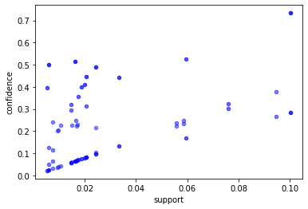

```python
plt.xlabel('support')
plt.ylabel('confidence')
for i in range(a_r.shape[0]):
    plt.scatter(a_r.support[i],a_r.confidence[i],s=20,c='b',alpha=(a_r.lift.iloc[i])/(a_r.lift.iloc[0])*0.8/(a_r.lift.iloc[0]-a_r.lift.iloc[-1])+0.2)
```

绘制support-confidence散点图  
其中cosine值的大小通过透明度反应出来

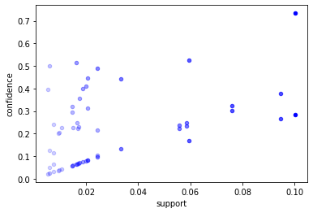

```python
plt.xlabel('support')
plt.ylabel('confidence')
a_r = a_r.sort_values(by='cosine',ascending=False).reset_index(drop=True)
for i in range(a_r.shape[0]):
    plt.scatter(a_r.support[i],a_r.confidence[i],s=20,c='b',alpha=(a_r.cosine.iloc[i])/(a_r.cosine.iloc[0]))
```

绘制support-confidence散点图  
其中Kulc值的大小通过透明度反应出来

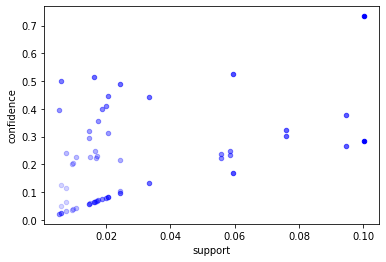

```python
plt.xlabel('support')
plt.ylabel('confidence')
a_r = a_r.sort_values(by='Kulc',ascending=False).reset_index(drop=True)
for i in range(a_r.shape[0]):
    plt.scatter(a_r.support[i],a_r.confidence[i],s=20,c='b',alpha=(a_r.Kulc.iloc[i])/(a_r.Kulc.iloc[0]))
```

绘制support-confidence散点图  
其中Jaccard值的大小通过透明度反应出来

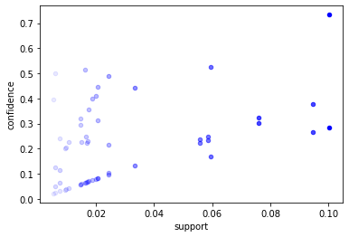

```python
plt.xlabel('support')
plt.ylabel('confidence')
a_r = a_r.sort_values(by='Jaccard',ascending=False).reset_index(drop=True)
for i in range(a_r.shape[0]):
    plt.scatter(a_r.support[i],a_r.confidence[i],s=20,c='b',alpha=(a_r.Jaccard.iloc[i])/(a_r.Jaccard.iloc[0]))
```

# 对IN数据集进行频繁模式与关联规则挖掘

```python
file1 = "INvideos.csv"
file2 = "IN_category_id.json"
data = pd.read_csv(file1, keep_default_na=False, low_memory=False)
data
```

|  | video_id | trending_date | title | channel_title | category_id | publish_time | tags | views | likes | dislikes | comment_count | thumbnail_link | comments_disabled | ratings_disabled | video_error_or_removed | description |
| --- | --- | --- | --- | --- | --- | --- | --- | --- | --- | --- | --- | --- | --- | --- | --- | --- |
| 0 | kzwfHumJyYc | 17.14.11 | Sharry Mann: Cute Munda ( Song Teaser) \| Parmi... | Lokdhun Punjabi | 1 | 2017-11-12T12:20:39.000Z | sharry mann\|"sharry mann new song"\|"sharry man... | 1096327 | 33966 | 798 | 882 | https://i.ytimg.com/vi/kzwfHumJyYc/default.jpg | False | False | False | Presenting Sharry Mann latest Punjabi Song Cu... |
| 1 | zUZ1z7FwLc8 | 17.14.11 | पीरियड्स के समय, पेट पर पति करता ऐसा, देखकर दं... | HJ NEWS | 25 | 2017-11-13T05:43:56.000Z | पीरियड्स के समय\|"पेट पर पति करता ऐसा"\|"देखकर द... | 590101 | 735 | 904 | 0 | https://i.ytimg.com/vi/zUZ1z7FwLc8/default.jpg | True | False | False | पीरियड्स के समय, पेट पर पति करता ऐसा, देखकर दं... |
| 2 | 10L1hZ9qa58 | 17.14.11 | Stylish Star Allu Arjun @ ChaySam Wedding Rece... | TFPC | 24 | 2017-11-12T15:48:08.000Z | Stylish Star Allu Arjun @ ChaySam Wedding Rece... | 473988 | 2011 | 243 | 149 | https://i.ytimg.com/vi/10L1hZ9qa58/default.jpg | False | False | False | Watch Stylish Star Allu Arjun @ ChaySam Weddin... |
| 3 | N1vE8iiEg64 | 17.14.11 | Eruma Saani \| Tamil vs English | Eruma Saani | 23 | 2017-11-12T07:08:48.000Z | Eruma Saani\|"Tamil Comedy Videos"\|"Films"\|"Mov... | 1242680 | 70353 | 1624 | 2684 | https://i.ytimg.com/vi/N1vE8iiEg64/default.jpg | False | False | False | This video showcases the difference between pe... |
| 4 | kJzGH0PVQHQ | 17.14.11 | why Samantha became EMOTIONAL @ Samantha naga ... | Filmylooks | 24 | 2017-11-13T01:14:16.000Z | Filmylooks\|"latest news"\|"telugu movies"\|"telu... | 464015 | 492 | 293 | 66 | https://i.ytimg.com/vi/kJzGH0PVQHQ/default.jpg | False | False | False | why Samantha became EMOTIONAL @ Samantha naga ... |
| ... | ... | ... | ... | ... | ... | ... | ... | ... | ... | ... | ... | ... | ... | ... | ... | ... |
| 37347 | iNHecA3PJCo | 18.14.06 | फेकू आशिक़ - राजस्थान की सबसे शानदार कॉमेडी \| ... | RDC Rajasthani | 23 | 2018-06-13T08:01:11.000Z | twinkle vaishnav comedy\|"twinkle vaishnav"\|"tw... | 214378 | 3291 | 404 | 196 | https://i.ytimg.com/vi/iNHecA3PJCo/default.jpg | False | False | False | PRG Music & RDC Rajasthani presents फेकू आशिक़... |
| 37348 | dpPmPbhcslM | 18.14.06 | Seetha \| Flowers \| Ep# 364 | Flowers TV | 24 | 2018-06-13T11:30:04.000Z | flowers serials\|"actress"\|"malayalam serials"\|... | 406828 | 1726 | 478 | 1428 | https://i.ytimg.com/vi/dpPmPbhcslM/default.jpg | False | False | False | Flowers - A R Rahman Show,Book your Tickets He... |
| 37349 | mV6aztP58f8 | 18.14.06 | Bhramanam I Episode 87 - 12 June 2018 I Mazhav... | Mazhavil Manorama | 24 | 2018-06-13T05:00:02.000Z | mazhavil manorama\|"bhramanam full episode"\|"gt... | 386319 | 1216 | 453 | 697 | https://i.ytimg.com/vi/mV6aztP58f8/default.jpg | False | False | False | Subscribe to Mazhavil Manorama now for your da... |
| 37350 | qxqDNP1bDEw | 18.14.06 | Nua Bohu \| Full Ep 285 \| 13th June 2018 \| Odia... | Tarang TV | 24 | 2018-06-13T15:07:49.000Z | tarang\|"tarang tv"\|"tarang tv online"\|"tarang ... | 130263 | 698 | 115 | 65 | https://i.ytimg.com/vi/qxqDNP1bDEw/default.jpg | False | False | False | Nuabohu : Story of a rustic village girl who w... |
| 37351 | wERgpPK44w0 | 18.14.06 | Ee Nagaraniki Emaindi Trailer \| Tharun Bhascke... | Suresh Productions | 24 | 2018-06-10T04:29:54.000Z | Ee Nagaraniki Emaindi\|"Ee Nagaraniki Emaindi T... | 1278249 | 22466 | 1609 | 1205 | https://i.ytimg.com/vi/wERgpPK44w0/default.jpg | False | False | False | Check out Ee Nagaraniki Emaindi Trailer #EeNag... |

37352 rows × 16 columns

```python
print("数据包含：")
title_list = ('video_id  视频id','trending_date  流行日期','title  标题',
              'channel_title  频道标题','category_id  类别id','publish_time  发布时间',
              'tags  标签','views  观看量','likes  点赞量','dislikes  踩量',
              'comment_count  评论数量','thumbnail_link  视频链接',
              'comments_disabled  是否禁止评论','ratings_disabled  是否禁止评分',
              'video_error_or_removed  视频是否失效或被移除','description  介绍')
for i in range(len(title_list)):
    print(str(i+1) + '. ' + title_list[i])
```

```
数据包含：
1. video_id  视频id
2. trending_date  流行日期
3. title  标题
4. channel_title  频道标题
5. category_id  类别id
6. publish_time  发布时间
7. tags  标签
8. views  观看量
9. likes  点赞量
10. dislikes  踩量
11. comment_count  评论数量
12. thumbnail_link  视频链接
13. comments_disabled  是否禁止评论
14. ratings_disabled  是否禁止评分
15. video_error_or_removed  视频是否失效或被移除
16. description  介绍
```

# 对数据集进行处理，转换成适合进行关联规则挖掘的形式

在数据处理时，我们挖掘视频类别(category)与观看量(views)的关联关系，从而挖掘出更多人喜欢的视频类别。

```python
df = data[['category_id','views']]
df
```

|  | category_id | views |
| --- | --- | --- |
| 0 | 1 | 1096327 |
| 1 | 25 | 590101 |
| 2 | 24 | 473988 |
| 3 | 23 | 1242680 |
| 4 | 24 | 464015 |
| ... | ... | ... |
| 37347 | 23 | 214378 |
| 37348 | 24 | 406828 |
| 37349 | 24 | 386319 |
| 37350 | 24 | 130263 |
| 37351 | 24 | 1278249 |

37352 rows × 2 columns

把.json文件中的category_id映射到具体的category类别名

```python
with open(file2, 'r') as f:
    content = json.load(f)
category_map = {}
for i in content['items']:
    category_map[int(i['id'])] = i['snippet']['title']
category_map
```

```
{1: 'Film & Animation',
 2: 'Autos & Vehicles',
 10: 'Music',
 15: 'Pets & Animals',
 17: 'Sports',
 18: 'Short Movies',
 19: 'Travel & Events',
 20: 'Gaming',
 21: 'Videoblogging',
 22: 'People & Blogs',
 23: 'Comedy',
 24: 'Entertainment',
 25: 'News & Politics',
 26: 'Howto & Style',
 27: 'Education',
```

[output cut: 16 more lines]

```python
t = df['category_id'].map(category_map)
df = pd.concat([df,t],axis=1)
df.columns=['category_id','views','category']
```

由于观看量（views）为数值型数据，需要将其转化为离散型数据。按照五数分布及离群点划分视频观看等级，并按照模型传入数据的格式将其转换为模型可接受的数据。

```python
grade = []
for i in df['views'].values:
    views_map = lambda x:{x>=1812354:'A',799291<=x<1812354:'B',304586<=x<799291:'C',
                          123915<=x<304586:'D',4024<=x<123915:'E'}
    grade.append(views_map(i)[True])
df['views_grade'] = grade
df = df.drop(['category_id', 'views'], axis = 1)
df
```

|  | category | views_grade |
| --- | --- | --- |
| 0 | Film & Animation | B |
| 1 | News & Politics | C |
| 2 | Entertainment | C |
| 3 | Comedy | B |
| 4 | Entertainment | C |
| ... | ... | ... |
| 37347 | Comedy | D |
| 37348 | Entertainment | C |
| 37349 | Entertainment | C |
| 37350 | Entertainment | D |
| 37351 | Entertainment | B |

37352 rows × 2 columns

```python
def deal(data):
    return data.dropna().tolist()
df_arr = df.apply(deal,axis=1).tolist() # 转化成列表
te = TE()  # 定义模型
df_tf = te.fit_transform(df_arr)
df = pd.DataFrame(df_tf,columns=te.columns_)
df
```

|  | A | Autos & Vehicles | B | C | Comedy | D | E | Education | Entertainment | Film & Animation | ... | Howto & Style | Movies | Music | News & Politics | People & Blogs | Pets & Animals | Science & Technology | Shows | Sports | Travel & Events |
| --- | --- | --- | --- | --- | --- | --- | --- | --- | --- | --- | --- | --- | --- | --- | --- | --- | --- | --- | --- | --- | --- |
| 0 | False | False | True | False | False | False | False | False | False | True | ... | False | False | False | False | False | False | False | False | False | False |
| 1 | False | False | False | True | False | False | False | False | False | False | ... | False | False | False | True | False | False | False | False | False | False |
| 2 | False | False | False | True | False | False | False | False | True | False | ... | False | False | False | False | False | False | False | False | False | False |
| 3 | False | False | True | False | True | False | False | False | False | False | ... | False | False | False | False | False | False | False | False | False | False |
| 4 | False | False | False | True | False | False | False | False | True | False | ... | False | False | False | False | False | False | False | False | False | False |
| ... | ... | ... | ... | ... | ... | ... | ... | ... | ... | ... | ... | ... | ... | ... | ... | ... | ... | ... | ... | ... | ... |
| 37347 | False | False | False | False | True | True | False | False | False | False | ... | False | False | False | False | False | False | False | False | False | False |
| 37348 | False | False | False | True | False | False | False | False | True | False | ... | False | False | False | False | False | False | False | False | False | False |
| 37349 | False | False | False | True | False | False | False | False | True | False | ... | False | False | False | False | False | False | False | False | False | False |
| 37350 | False | False | False | False | False | True | False | False | True | False | ... | False | False | False | False | False | False | False | False | False | False |
| 37351 | False | False | True | False | False | False | False | False | True | False | ... | False | False | False | False | False | False | False | False | False | False |

37352 rows × 21 columns

# 找出频繁模式

```python
freq_itemsets = apriori(df,min_support=0.005,use_colnames=True)
freq_itemsets.sort_values(by='support',ascending=False,inplace=True)
freq_itemsets
```

|  | support | itemsets |
| --- | --- | --- |
| 7 | 0.447419 | (Entertainment) |
| 2 | 0.250000 | (C) |
| 4 | 0.250000 | (D) |
| 5 | 0.250000 | (E) |
| 11 | 0.140314 | (News & Politics) |
| 1 | 0.137155 | (B) |
| 35 | 0.127436 | (Entertainment, D) |
| 28 | 0.118521 | (Entertainment, C) |
| 0 | 0.112845 | (A) |
| 42 | 0.110837 | (Entertainment, E) |
| 10 | 0.103288 | (Music) |
| 3 | 0.091802 | (Comedy) |
| 12 | 0.070251 | (People & Blogs) |
| 22 | 0.052795 | (Entertainment, B) |
| 38 | 0.047762 | (D, News & Politics) |
| 46 | 0.045459 | (E, News & Politics) |
| 8 | 0.044389 | (Film & Animation) |
| 17 | 0.037829 | (A, Entertainment) |
| 19 | 0.033465 | (A, Music) |
| 6 | 0.032850 | (Education) |
| 31 | 0.031725 | (C, News & Politics) |
| 27 | 0.029155 | (C, Comedy) |
| 41 | 0.025594 | (Education, E) |
| 30 | 0.023667 | (C, Music) |
| 47 | 0.022864 | (People & Blogs, E) |
| 9 | 0.022623 | (Howto & Style) |
| 24 | 0.021177 | (B, Music) |
| 21 | 0.019865 | (B, Comedy) |
| 15 | 0.019571 | (Sports) |
| 32 | 0.018714 | (People & Blogs, C) |
| 33 | 0.017509 | (D, Comedy) |
| 34 | 0.015930 | (E, Comedy) |
| 37 | 0.015715 | (D, Music) |
| 13 | 0.014778 | (Science & Technology) |
| 39 | 0.014537 | (People & Blogs, D) |
| 18 | 0.012422 | (A, Film & Animation) |
| 25 | 0.011619 | (B, News & Politics) |
| 29 | 0.009665 | (C, Film & Animation) |
| 23 | 0.009638 | (B, Film & Animation) |
| 26 | 0.009504 | (People & Blogs, B) |
| 16 | 0.009344 | (A, Comedy) |
| 45 | 0.009263 | (E, Music) |
| 44 | 0.007764 | (Howto & Style, E) |
| 36 | 0.007550 | (D, Film & Animation) |
| 14 | 0.005488 | (Shows) |
| 20 | 0.005194 | (A, Sports) |
| 43 | 0.005114 | (E, Film & Animation) |
| 40 | 0.005006 | (D, Sports) |

# 导出关联规则，计算其支持度和置信度

```python
a_r = ar(freq_itemsets,metric='lift')
a_r = a_r.sort_values(by='lift',ascending=False).reset_index(drop=True)
a_r
```

|  | antecedents | consequents | antecedent support | consequent support | support | confidence | lift | leverage | conviction |
| --- | --- | --- | --- | --- | --- | --- | --- | --- | --- |
| 0 | (E) | (Education) | 0.250000 | 0.032850 | 0.025594 | 0.102377 | 3.116544 | 0.017382 | 1.077458 |
| 1 | (Education) | (E) | 0.032850 | 0.250000 | 0.025594 | 0.779136 | 3.116544 | 0.017382 | 3.395756 |
| 2 | (A) | (Music) | 0.112845 | 0.103288 | 0.033465 | 0.296560 | 2.871204 | 0.021810 | 1.274753 |
| 3 | (Music) | (A) | 0.103288 | 0.112845 | 0.033465 | 0.324002 | 2.871204 | 0.021810 | 1.312363 |
| 4 | (A) | (Film & Animation) | 0.112845 | 0.044389 | 0.012422 | 0.110083 | 2.479989 | 0.007413 | 1.073821 |
| 5 | (Film & Animation) | (A) | 0.044389 | 0.112845 | 0.012422 | 0.279855 | 2.479989 | 0.007413 | 1.231912 |
| 6 | (A) | (Sports) | 0.112845 | 0.019571 | 0.005194 | 0.046026 | 2.351801 | 0.002985 | 1.027732 |
| 7 | (Sports) | (A) | 0.019571 | 0.112845 | 0.005194 | 0.265390 | 2.351801 | 0.002985 | 1.207654 |
| 8 | (B) | (Film & Animation) | 0.137155 | 0.044389 | 0.009638 | 0.070271 | 1.583097 | 0.003550 | 1.027839 |
| 9 | (Film & Animation) | (B) | 0.044389 | 0.137155 | 0.009638 | 0.217129 | 1.583097 | 0.003550 | 1.102155 |
| 10 | (Comedy) | (B) | 0.091802 | 0.137155 | 0.019865 | 0.216390 | 1.577705 | 0.007274 | 1.101115 |
| 11 | (B) | (Comedy) | 0.137155 | 0.091802 | 0.019865 | 0.144837 | 1.577705 | 0.007274 | 1.062017 |
| 12 | (Music) | (B) | 0.103288 | 0.137155 | 0.021177 | 0.205029 | 1.494871 | 0.007011 | 1.085379 |
| 13 | (B) | (Music) | 0.137155 | 0.103288 | 0.021177 | 0.154402 | 1.494871 | 0.007011 | 1.060447 |
| 14 | (Howto & Style) | (E) | 0.022623 | 0.250000 | 0.007764 | 0.343195 | 1.372781 | 0.002108 | 1.141892 |
| 15 | (E) | (Howto & Style) | 0.250000 | 0.022623 | 0.007764 | 0.031056 | 1.372781 | 0.002108 | 1.008704 |
| 16 | (News & Politics) | (D) | 0.140314 | 0.250000 | 0.047762 | 0.340393 | 1.361572 | 0.012683 | 1.137041 |
| 17 | (D) | (News & Politics) | 0.250000 | 0.140314 | 0.047762 | 0.191047 | 1.361572 | 0.012683 | 1.062715 |
| 18 | (People & Blogs) | (E) | 0.070251 | 0.250000 | 0.022864 | 0.325457 | 1.301829 | 0.005301 | 1.111864 |
| 19 | (E) | (People & Blogs) | 0.250000 | 0.070251 | 0.022864 | 0.091454 | 1.301829 | 0.005301 | 1.023338 |
| 20 | (News & Politics) | (E) | 0.140314 | 0.250000 | 0.045459 | 0.323984 | 1.295936 | 0.010381 | 1.109441 |
| 21 | (E) | (News & Politics) | 0.250000 | 0.140314 | 0.045459 | 0.181838 | 1.295936 | 0.010381 | 1.050753 |
| 22 | (C) | (Comedy) | 0.250000 | 0.091802 | 0.029155 | 0.116620 | 1.270341 | 0.006204 | 1.028094 |
| 23 | (Comedy) | (C) | 0.091802 | 0.250000 | 0.029155 | 0.317585 | 1.270341 | 0.006204 | 1.099038 |
| 24 | (Entertainment) | (D) | 0.447419 | 0.250000 | 0.127436 | 0.284825 | 1.139301 | 0.015581 | 1.048695 |
| 25 | (D) | (Entertainment) | 0.250000 | 0.447419 | 0.127436 | 0.509745 | 1.139301 | 0.015581 | 1.127130 |
| 26 | (People & Blogs) | (C) | 0.070251 | 0.250000 | 0.018714 | 0.266387 | 1.065549 | 0.001151 | 1.022338 |
| 27 | (C) | (People & Blogs) | 0.250000 | 0.070251 | 0.018714 | 0.074855 | 1.065549 | 0.001151 | 1.004977 |
| 28 | (C) | (Entertainment) | 0.250000 | 0.447419 | 0.118521 | 0.474084 | 1.059598 | 0.006666 | 1.050703 |
| 29 | (Entertainment) | (C) | 0.447419 | 0.250000 | 0.118521 | 0.264899 | 1.059598 | 0.006666 | 1.020269 |
| 30 | (D) | (Sports) | 0.250000 | 0.019571 | 0.005006 | 0.020026 | 1.023256 | 0.000114 | 1.000464 |
| 31 | (Sports) | (D) | 0.019571 | 0.250000 | 0.005006 | 0.255814 | 1.023256 | 0.000114 | 1.007812 |
| 32 | (E) | (Entertainment) | 0.250000 | 0.447419 | 0.110837 | 0.443350 | 0.990905 | -0.001017 | 0.992689 |
| 33 | (Entertainment) | (E) | 0.447419 | 0.250000 | 0.110837 | 0.247726 | 0.990905 | -0.001017 | 0.996977 |
| 34 | (People & Blogs) | (B) | 0.070251 | 0.137155 | 0.009504 | 0.135290 | 0.986402 | -0.000131 | 0.997843 |
| 35 | (B) | (People & Blogs) | 0.137155 | 0.070251 | 0.009504 | 0.069295 | 0.986402 | -0.000131 | 0.998974 |
| 36 | (Music) | (C) | 0.103288 | 0.250000 | 0.023667 | 0.229134 | 0.916537 | -0.002155 | 0.972932 |
| 37 | (C) | (Music) | 0.250000 | 0.103288 | 0.023667 | 0.094667 | 0.916537 | -0.002155 | 0.990478 |
| 38 | (News & Politics) | (C) | 0.140314 | 0.250000 | 0.031725 | 0.226102 | 0.904408 | -0.003353 | 0.969120 |
| 39 | (C) | (News & Politics) | 0.250000 | 0.140314 | 0.031725 | 0.126901 | 0.904408 | -0.003353 | 0.984638 |
| 40 | (A) | (Comedy) | 0.112845 | 0.091802 | 0.009344 | 0.082800 | 0.901933 | -0.001016 | 0.990184 |
| 41 | (Comedy) | (A) | 0.091802 | 0.112845 | 0.009344 | 0.101779 | 0.901933 | -0.001016 | 0.987680 |
| 42 | (C) | (Film & Animation) | 0.250000 | 0.044389 | 0.009665 | 0.038659 | 0.870929 | -0.001432 | 0.994040 |
| 43 | (Film & Animation) | (C) | 0.044389 | 0.250000 | 0.009665 | 0.217732 | 0.870929 | -0.001432 | 0.958751 |
| 44 | (Entertainment) | (B) | 0.447419 | 0.137155 | 0.052795 | 0.117999 | 0.860336 | -0.008571 | 0.978282 |
| 45 | (B) | (Entertainment) | 0.137155 | 0.447419 | 0.052795 | 0.384931 | 0.860336 | -0.008571 | 0.898404 |
| 46 | (D) | (People & Blogs) | 0.250000 | 0.070251 | 0.014537 | 0.058149 | 0.827744 | -0.003025 | 0.987152 |
| 47 | (People & Blogs) | (D) | 0.070251 | 0.250000 | 0.014537 | 0.206936 | 0.827744 | -0.003025 | 0.945699 |

# 对规则进行评价

对规则进行评价,计算余弦、Kulc和Jaccard

```python
t = []
for i in range(a_r.shape[0]):
    item = a_r.iloc[i]
    t.append(item.support/math.sqrt(item['antecedent support']*item['consequent support']))
a_r['cosine'] = t
```

```python
t = []
for i in range(a_r.shape[0]):
    item = a_r.iloc[i]
    t.append(0.5*(item.support/item['antecedent support']+item.support/item['consequent support']))
a_r['Kulc'] = t
```

```python
t = []
for i in range(a_r.shape[0]):
    item = a_r.iloc[i]
    t.append(item.support/(item['antecedent support']+item['consequent support']-item.support))
a_r['Jaccard'] = t
```

```python
a_r
```

|  | antecedents | consequents | antecedent support | consequent support | support | confidence | lift | leverage | conviction | cosine | Kulc | Jaccard |
| --- | --- | --- | --- | --- | --- | --- | --- | --- | --- | --- | --- | --- |
| 0 | (E) | (Education) | 0.250000 | 0.032850 | 0.025594 | 0.102377 | 3.116544 | 0.017382 | 1.077458 | 0.282429 | 0.440757 | 0.099490 |
| 1 | (Education) | (E) | 0.032850 | 0.250000 | 0.025594 | 0.779136 | 3.116544 | 0.017382 | 3.395756 | 0.282429 | 0.440757 | 0.099490 |
| 2 | (A) | (Music) | 0.112845 | 0.103288 | 0.033465 | 0.296560 | 2.871204 | 0.021810 | 1.274753 | 0.309977 | 0.310281 | 0.183204 |
| 3 | (Music) | (A) | 0.103288 | 0.112845 | 0.033465 | 0.324002 | 2.871204 | 0.021810 | 1.312363 | 0.309977 | 0.310281 | 0.183204 |
| 4 | (A) | (Film & Animation) | 0.112845 | 0.044389 | 0.012422 | 0.110083 | 2.479989 | 0.007413 | 1.073821 | 0.175520 | 0.194969 | 0.085783 |
| 5 | (Film & Animation) | (A) | 0.044389 | 0.112845 | 0.012422 | 0.279855 | 2.479989 | 0.007413 | 1.231912 | 0.175520 | 0.194969 | 0.085783 |
| 6 | (A) | (Sports) | 0.112845 | 0.019571 | 0.005194 | 0.046026 | 2.351801 | 0.002985 | 1.027732 | 0.110521 | 0.155708 | 0.040825 |
| 7 | (Sports) | (A) | 0.019571 | 0.112845 | 0.005194 | 0.265390 | 2.351801 | 0.002985 | 1.207654 | 0.110521 | 0.155708 | 0.040825 |
| 8 | (B) | (Film & Animation) | 0.137155 | 0.044389 | 0.009638 | 0.070271 | 1.583097 | 0.003550 | 1.027839 | 0.123523 | 0.143700 | 0.056066 |
| 9 | (Film & Animation) | (B) | 0.044389 | 0.137155 | 0.009638 | 0.217129 | 1.583097 | 0.003550 | 1.102155 | 0.123523 | 0.143700 | 0.056066 |
| 10 | (Comedy) | (B) | 0.091802 | 0.137155 | 0.019865 | 0.216390 | 1.577705 | 0.007274 | 1.101115 | 0.177035 | 0.180613 | 0.095006 |
| 11 | (B) | (Comedy) | 0.137155 | 0.091802 | 0.019865 | 0.144837 | 1.577705 | 0.007274 | 1.062017 | 0.177035 | 0.180613 | 0.095006 |
| 12 | (Music) | (B) | 0.103288 | 0.137155 | 0.021177 | 0.205029 | 1.494871 | 0.007011 | 1.085379 | 0.177923 | 0.179715 | 0.096581 |
| 13 | (B) | (Music) | 0.137155 | 0.103288 | 0.021177 | 0.154402 | 1.494871 | 0.007011 | 1.060447 | 0.177923 | 0.179715 | 0.096581 |
| 14 | (Howto & Style) | (E) | 0.022623 | 0.250000 | 0.007764 | 0.343195 | 1.372781 | 0.002108 | 1.141892 | 0.103239 | 0.187126 | 0.029314 |
| 15 | (E) | (Howto & Style) | 0.250000 | 0.022623 | 0.007764 | 0.031056 | 1.372781 | 0.002108 | 1.008704 | 0.103239 | 0.187126 | 0.029314 |
| 16 | (News & Politics) | (D) | 0.140314 | 0.250000 | 0.047762 | 0.340393 | 1.361572 | 0.012683 | 1.137041 | 0.255012 | 0.265720 | 0.139429 |
| 17 | (D) | (News & Politics) | 0.250000 | 0.140314 | 0.047762 | 0.191047 | 1.361572 | 0.012683 | 1.062715 | 0.255012 | 0.265720 | 0.139429 |
| 18 | (People & Blogs) | (E) | 0.070251 | 0.250000 | 0.022864 | 0.325457 | 1.301829 | 0.005301 | 1.111864 | 0.172524 | 0.208456 | 0.076882 |
| 19 | (E) | (People & Blogs) | 0.250000 | 0.070251 | 0.022864 | 0.091454 | 1.301829 | 0.005301 | 1.023338 | 0.172524 | 0.208456 | 0.076882 |
| 20 | (News & Politics) | (E) | 0.140314 | 0.250000 | 0.045459 | 0.323984 | 1.295936 | 0.010381 | 1.109441 | 0.242719 | 0.252911 | 0.131822 |
| 21 | (E) | (News & Politics) | 0.250000 | 0.140314 | 0.045459 | 0.181838 | 1.295936 | 0.010381 | 1.050753 | 0.242719 | 0.252911 | 0.131822 |
| 22 | (C) | (Comedy) | 0.250000 | 0.091802 | 0.029155 | 0.116620 | 1.270341 | 0.006204 | 1.028094 | 0.192450 | 0.217103 | 0.093252 |
| 23 | (Comedy) | (C) | 0.091802 | 0.250000 | 0.029155 | 0.317585 | 1.270341 | 0.006204 | 1.099038 | 0.192450 | 0.217103 | 0.093252 |
| 24 | (Entertainment) | (D) | 0.447419 | 0.250000 | 0.127436 | 0.284825 | 1.139301 | 0.015581 | 1.048695 | 0.381036 | 0.397285 | 0.223579 |
| 25 | (D) | (Entertainment) | 0.250000 | 0.447419 | 0.127436 | 0.509745 | 1.139301 | 0.015581 | 1.127130 | 0.381036 | 0.397285 | 0.223579 |
| 26 | (People & Blogs) | (C) | 0.070251 | 0.250000 | 0.018714 | 0.266387 | 1.065549 | 0.001151 | 1.022338 | 0.141211 | 0.170621 | 0.062062 |
| 27 | (C) | (People & Blogs) | 0.250000 | 0.070251 | 0.018714 | 0.074855 | 1.065549 | 0.001151 | 1.004977 | 0.141211 | 0.170621 | 0.062062 |
| 28 | (C) | (Entertainment) | 0.250000 | 0.447419 | 0.118521 | 0.474084 | 1.059598 | 0.006666 | 1.050703 | 0.354379 | 0.369492 | 0.204736 |
| 29 | (Entertainment) | (C) | 0.447419 | 0.250000 | 0.118521 | 0.264899 | 1.059598 | 0.006666 | 1.020269 | 0.354379 | 0.369492 | 0.204736 |
| 30 | (D) | (Sports) | 0.250000 | 0.019571 | 0.005006 | 0.020026 | 1.023256 | 0.000114 | 1.000464 | 0.071574 | 0.137920 | 0.018923 |
| 31 | (Sports) | (D) | 0.019571 | 0.250000 | 0.005006 | 0.255814 | 1.023256 | 0.000114 | 1.007812 | 0.071574 | 0.137920 | 0.018923 |
| 32 | (E) | (Entertainment) | 0.250000 | 0.447419 | 0.110837 | 0.443350 | 0.990905 | -0.001017 | 0.992689 | 0.331405 | 0.345538 | 0.188955 |
| 33 | (Entertainment) | (E) | 0.447419 | 0.250000 | 0.110837 | 0.247726 | 0.990905 | -0.001017 | 0.996977 | 0.331405 | 0.345538 | 0.188955 |
| 34 | (People & Blogs) | (B) | 0.070251 | 0.137155 | 0.009504 | 0.135290 | 0.986402 | -0.000131 | 0.997843 | 0.096824 | 0.102292 | 0.048025 |
| 35 | (B) | (People & Blogs) | 0.137155 | 0.070251 | 0.009504 | 0.069295 | 0.986402 | -0.000131 | 0.998974 | 0.096824 | 0.102292 | 0.048025 |
| 36 | (Music) | (C) | 0.103288 | 0.250000 | 0.023667 | 0.229134 | 0.916537 | -0.002155 | 0.972932 | 0.147280 | 0.161901 | 0.071800 |
| 37 | (C) | (Music) | 0.250000 | 0.103288 | 0.023667 | 0.094667 | 0.916537 | -0.002155 | 0.990478 | 0.147280 | 0.161901 | 0.071800 |
| 38 | (News & Politics) | (C) | 0.140314 | 0.250000 | 0.031725 | 0.226102 | 0.904408 | -0.003353 | 0.969120 | 0.169389 | 0.176501 | 0.088472 |
| 39 | (C) | (News & Politics) | 0.250000 | 0.140314 | 0.031725 | 0.126901 | 0.904408 | -0.003353 | 0.984638 | 0.169389 | 0.176501 | 0.088472 |
| 40 | (A) | (Comedy) | 0.112845 | 0.091802 | 0.009344 | 0.082800 | 0.901933 | -0.001016 | 0.990184 | 0.091800 | 0.092289 | 0.047841 |
| 41 | (Comedy) | (A) | 0.091802 | 0.112845 | 0.009344 | 0.101779 | 0.901933 | -0.001016 | 0.987680 | 0.091800 | 0.092289 | 0.047841 |
| 42 | (C) | (Film & Animation) | 0.250000 | 0.044389 | 0.009665 | 0.038659 | 0.870929 | -0.001432 | 0.994040 | 0.091746 | 0.128196 | 0.033945 |
| 43 | (Film & Animation) | (C) | 0.044389 | 0.250000 | 0.009665 | 0.217732 | 0.870929 | -0.001432 | 0.958751 | 0.091746 | 0.128196 | 0.033945 |
| 44 | (Entertainment) | (B) | 0.447419 | 0.137155 | 0.052795 | 0.117999 | 0.860336 | -0.008571 | 0.978282 | 0.213123 | 0.251465 | 0.099280 |
| 45 | (B) | (Entertainment) | 0.137155 | 0.447419 | 0.052795 | 0.384931 | 0.860336 | -0.008571 | 0.898404 | 0.213123 | 0.251465 | 0.099280 |
| 46 | (D) | (People & Blogs) | 0.250000 | 0.070251 | 0.014537 | 0.058149 | 0.827744 | -0.003025 | 0.987152 | 0.109696 | 0.132543 | 0.047552 |
| 47 | (People & Blogs) | (D) | 0.070251 | 0.250000 | 0.014537 | 0.206936 | 0.827744 | -0.003025 | 0.945699 | 0.109696 | 0.132543 | 0.047552 |

# 对挖掘结果进行分析

```python
a_r = a_r.sort_values(by='lift',ascending=False).reset_index(drop=True)
a_r.head(30)
```

|  | antecedents | consequents | antecedent support | consequent support | support | confidence | lift | leverage | conviction | cosine | Kulc | Jaccard |
| --- | --- | --- | --- | --- | --- | --- | --- | --- | --- | --- | --- | --- |
| 0 | (E) | (Education) | 0.250000 | 0.032850 | 0.025594 | 0.102377 | 3.116544 | 0.017382 | 1.077458 | 0.282429 | 0.440757 | 0.099490 |
| 1 | (Education) | (E) | 0.032850 | 0.250000 | 0.025594 | 0.779136 | 3.116544 | 0.017382 | 3.395756 | 0.282429 | 0.440757 | 0.099490 |
| 2 | (A) | (Music) | 0.112845 | 0.103288 | 0.033465 | 0.296560 | 2.871204 | 0.021810 | 1.274753 | 0.309977 | 0.310281 | 0.183204 |
| 3 | (Music) | (A) | 0.103288 | 0.112845 | 0.033465 | 0.324002 | 2.871204 | 0.021810 | 1.312363 | 0.309977 | 0.310281 | 0.183204 |
| 4 | (A) | (Film & Animation) | 0.112845 | 0.044389 | 0.012422 | 0.110083 | 2.479989 | 0.007413 | 1.073821 | 0.175520 | 0.194969 | 0.085783 |
| 5 | (Film & Animation) | (A) | 0.044389 | 0.112845 | 0.012422 | 0.279855 | 2.479989 | 0.007413 | 1.231912 | 0.175520 | 0.194969 | 0.085783 |
| 6 | (A) | (Sports) | 0.112845 | 0.019571 | 0.005194 | 0.046026 | 2.351801 | 0.002985 | 1.027732 | 0.110521 | 0.155708 | 0.040825 |
| 7 | (Sports) | (A) | 0.019571 | 0.112845 | 0.005194 | 0.265390 | 2.351801 | 0.002985 | 1.207654 | 0.110521 | 0.155708 | 0.040825 |
| 8 | (B) | (Film & Animation) | 0.137155 | 0.044389 | 0.009638 | 0.070271 | 1.583097 | 0.003550 | 1.027839 | 0.123523 | 0.143700 | 0.056066 |
| 9 | (Film & Animation) | (B) | 0.044389 | 0.137155 | 0.009638 | 0.217129 | 1.583097 | 0.003550 | 1.102155 | 0.123523 | 0.143700 | 0.056066 |
| 10 | (Comedy) | (B) | 0.091802 | 0.137155 | 0.019865 | 0.216390 | 1.577705 | 0.007274 | 1.101115 | 0.177035 | 0.180613 | 0.095006 |
| 11 | (B) | (Comedy) | 0.137155 | 0.091802 | 0.019865 | 0.144837 | 1.577705 | 0.007274 | 1.062017 | 0.177035 | 0.180613 | 0.095006 |
| 12 | (Music) | (B) | 0.103288 | 0.137155 | 0.021177 | 0.205029 | 1.494871 | 0.007011 | 1.085379 | 0.177923 | 0.179715 | 0.096581 |
| 13 | (B) | (Music) | 0.137155 | 0.103288 | 0.021177 | 0.154402 | 1.494871 | 0.007011 | 1.060447 | 0.177923 | 0.179715 | 0.096581 |
| 14 | (Howto & Style) | (E) | 0.022623 | 0.250000 | 0.007764 | 0.343195 | 1.372781 | 0.002108 | 1.141892 | 0.103239 | 0.187126 | 0.029314 |
| 15 | (E) | (Howto & Style) | 0.250000 | 0.022623 | 0.007764 | 0.031056 | 1.372781 | 0.002108 | 1.008704 | 0.103239 | 0.187126 | 0.029314 |
| 16 | (News & Politics) | (D) | 0.140314 | 0.250000 | 0.047762 | 0.340393 | 1.361572 | 0.012683 | 1.137041 | 0.255012 | 0.265720 | 0.139429 |
| 17 | (D) | (News & Politics) | 0.250000 | 0.140314 | 0.047762 | 0.191047 | 1.361572 | 0.012683 | 1.062715 | 0.255012 | 0.265720 | 0.139429 |
| 18 | (People & Blogs) | (E) | 0.070251 | 0.250000 | 0.022864 | 0.325457 | 1.301829 | 0.005301 | 1.111864 | 0.172524 | 0.208456 | 0.076882 |
| 19 | (E) | (People & Blogs) | 0.250000 | 0.070251 | 0.022864 | 0.091454 | 1.301829 | 0.005301 | 1.023338 | 0.172524 | 0.208456 | 0.076882 |
| 20 | (News & Politics) | (E) | 0.140314 | 0.250000 | 0.045459 | 0.323984 | 1.295936 | 0.010381 | 1.109441 | 0.242719 | 0.252911 | 0.131822 |
| 21 | (E) | (News & Politics) | 0.250000 | 0.140314 | 0.045459 | 0.181838 | 1.295936 | 0.010381 | 1.050753 | 0.242719 | 0.252911 | 0.131822 |
| 22 | (C) | (Comedy) | 0.250000 | 0.091802 | 0.029155 | 0.116620 | 1.270341 | 0.006204 | 1.028094 | 0.192450 | 0.217103 | 0.093252 |
| 23 | (Comedy) | (C) | 0.091802 | 0.250000 | 0.029155 | 0.317585 | 1.270341 | 0.006204 | 1.099038 | 0.192450 | 0.217103 | 0.093252 |
| 24 | (D) | (Entertainment) | 0.250000 | 0.447419 | 0.127436 | 0.509745 | 1.139301 | 0.015581 | 1.127130 | 0.381036 | 0.397285 | 0.223579 |
| 25 | (Entertainment) | (D) | 0.447419 | 0.250000 | 0.127436 | 0.284825 | 1.139301 | 0.015581 | 1.048695 | 0.381036 | 0.397285 | 0.223579 |
| 26 | (People & Blogs) | (C) | 0.070251 | 0.250000 | 0.018714 | 0.266387 | 1.065549 | 0.001151 | 1.022338 | 0.141211 | 0.170621 | 0.062062 |
| 27 | (C) | (People & Blogs) | 0.250000 | 0.070251 | 0.018714 | 0.074855 | 1.065549 | 0.001151 | 1.004977 | 0.141211 | 0.170621 | 0.062062 |
| 28 | (C) | (Entertainment) | 0.250000 | 0.447419 | 0.118521 | 0.474084 | 1.059598 | 0.006666 | 1.050703 | 0.354379 | 0.369492 | 0.204736 |
| 29 | (Entertainment) | (C) | 0.447419 | 0.250000 | 0.118521 | 0.264899 | 1.059598 | 0.006666 | 1.020269 | 0.354379 | 0.369492 | 0.204736 |

由结果可以看出，在IN_video数据集中：  
类别（category）与观看量（views）相关性较强的前五个种类为：Education、Music、Film & Animation、Sports、Comedy。  
Education种类视频的观看等级为E级，说明观看此类视频的人数最少，但Education类别与观看量（views）之间仍有非常强的相关性。Music种类视频的观看等级为A级，说明观看此类视频的人数最多，Music类别与观看量之间具有很强的相关性。

# 可视化展示

绘制support-confidence散点图  
其中lift值的大小通过透明度反应出来

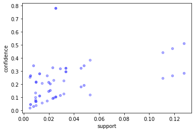

```python
plt.xlabel('support')
plt.ylabel('confidence')
for i in range(a_r.shape[0]):
    plt.scatter(a_r.support[i],a_r.confidence[i],s=20,c='b',alpha=(a_r.lift.iloc[i])/(a_r.lift.iloc[0])*0.8/(a_r.lift.iloc[0]-a_r.lift.iloc[-1])+0.2)
```

绘制support-confidence散点图  
其中cosine值的大小通过透明度反应出来

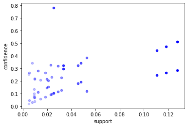

```python
plt.xlabel('support')
plt.ylabel('confidence')
a_r = a_r.sort_values(by='cosine',ascending=False).reset_index(drop=True)
for i in range(a_r.shape[0]):
    plt.scatter(a_r.support[i],a_r.confidence[i],s=20,c='b',alpha=(a_r.cosine.iloc[i])/(a_r.cosine.iloc[0]))
```

绘制support-confidence散点图  
其中Kulc值的大小通过透明度反应出来

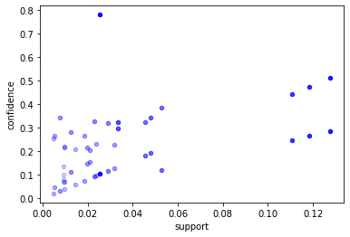

```python
plt.xlabel('support')
plt.ylabel('confidence')
a_r = a_r.sort_values(by='Kulc',ascending=False).reset_index(drop=True)
for i in range(a_r.shape[0]):
    plt.scatter(a_r.support[i],a_r.confidence[i],s=20,c='b',alpha=(a_r.Kulc.iloc[i])/(a_r.Kulc.iloc[0]))
```

绘制support-confidence散点图  
其中Jaccard值的大小通过透明度反应出来

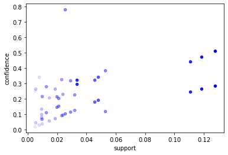

```python
plt.xlabel('support')
plt.ylabel('confidence')
a_r = a_r.sort_values(by='Jaccard',ascending=False).reset_index(drop=True)
for i in range(a_r.shape[0]):
    plt.scatter(a_r.support[i],a_r.confidence[i],s=20,c='b',alpha=(a_r.Jaccard.iloc[i])/(a_r.Jaccard.iloc[0]))
```

# 对MX数据集进行频繁模式与关联规则挖掘

```python
file1 = "MXvideos.csv"
file2 = "MX_category_id.json"
data = pd.read_csv(file1, keep_default_na=False, low_memory=False)
data
```

|  | video_id | trending_date | title | channel_title | category_id | publish_time | tags | views | likes | dislikes | comment_count | thumbnail_link | comments_disabled | ratings_disabled | video_error_or_removed | description |
| --- | --- | --- | --- | --- | --- | --- | --- | --- | --- | --- | --- | --- | --- | --- | --- | --- |
| 0 | SbOwzAl9ZfQ | 17.14.11 | Capítulo 12 \| MasterChef 2017 | MasterChef 2017 | 24 | 2017-11-13T06:06:22.000Z | MasterChef Junior 2017\|"TV Azteca"\|"recetas"\|"... | 310130 | 4182 | 361 | 1836 | https://i.ytimg.com/vi/SbOwzAl9ZfQ/default.jpg | False | False | False | Disfruta la presencia del Chef Torreblanca en ... |
| 1 | klOV6Xh-DnI | 17.14.11 | ALEXA EX-INTEGRANTE DEL GRUPO TIMBIRICHE RENUN... | Micky Contreras Martinez | 22 | 2017-11-13T05:11:58.000Z | La Voz Mexico 7 | 104972 | 271 | 174 | 369 | https://i.ytimg.com/vi/klOV6Xh-DnI/default.jpg | False | False | False | ALEXA EX-INTEGRANTE DEL GRUPO TIMBIRICHE RENUN... |
| 2 | 6L2ZF7Qzsbk | 17.14.11 | LOUIS CKAGÓ - EL PULSO DE LA REPÚBLICA | El Pulso De La República | 25 | 2017-11-13T17:00:02.000Z | Chumel Torres\|"El Pulso de la Republica"\|"noti... | 136064 | 10105 | 266 | 607 | https://i.ytimg.com/vi/6L2ZF7Qzsbk/default.jpg | False | False | False | La canción del principio se llama “Este espíri... |
| 3 | hcY52MFWMDM | 17.14.11 | Sismo de 6.7 sacude Costa Rica 12 Noviembre 2017 | Casanare | 25 | 2017-11-13T03:47:10.000Z | temblor\|"costa rica"\|"sismo en costa rica" | 96153 | 378 | 171 | 208 | https://i.ytimg.com/vi/hcY52MFWMDM/default.jpg | False | False | False | El video es de un Walmart en el pais centroame... |
| 4 | _OXDcGPVAa4 | 17.14.11 | DOG HACKS \| MUSAS LESSLIE LOS POLINESIOS | Musas | 26 | 2017-11-13T19:17:48.000Z | MUSAS\|"lesslie"\|"karen"\|"hacks"\|"perros"\|"dogs... | 499965 | 57781 | 681 | 7428 | https://i.ytimg.com/vi/_OXDcGPVAa4/default.jpg | False | False | False | MI HERMANO NARRA MI RUTINA DE MAQUILLAJE\nhttp... |
| ... | ... | ... | ... | ... | ... | ... | ... | ... | ... | ... | ... | ... | ... | ... | ... | ... |
| 40446 | r63VBOagGAo | 18.14.06 | Shawn Mendes x Portugal (FPF Official World Cu... | FPFutebolOficial | 17 | 2018-06-13T13:11:56.000Z | Canal\|"Oficial"\|"da"\|"Federação"\|"Portuguesa"\|... | 653114 | 65639 | 547 | 3826 | https://i.ytimg.com/vi/r63VBOagGAo/default.jpg | False | False | False | Portugal's Football Team Official SongLyrics: ... |
| 40447 | i7r_kMbyngk | 18.14.06 | AMLO llegó con su esposa al Tercer Debate en M... | AMX | 25 | 2018-06-13T01:15:08.000Z | AMLO\|"morena"\|"política"\|"PRI"\|"PAN"\|"PRD"\|"Ló... | 121674 | 3558 | 58 | 491 | https://i.ytimg.com/vi/i7r_kMbyngk/default.jpg | False | False | False | AMLO llegó con su esposa al Tercer Debate en M... |
| 40448 | _jnwjdMe3Zo | 18.14.06 | Maire usa una blusa kawaiii ¿adorable o ridícula? | Historias Wink | 24 | 2018-06-13T15:08:53.000Z | maire\|"maire vs el internet"\|"maire vs interne... | 14067 | 538 | 6 | 90 | https://i.ytimg.com/vi/_jnwjdMe3Zo/default.jpg | False | False | False | Maire usa una blusa kawaii de Alicia en el paí... |
| 40449 | pAH9omNAWA4 | 18.14.06 | La Jefa del Campeón - Capítulo 2 Parte 3/4 | Tele Time | 22 | 2018-06-13T02:22:33.000Z | [none] | 22898 | 94 | 11 | 3 | https://i.ytimg.com/vi/pAH9omNAWA4/default.jpg | False | False | False |  |
| 40450 | dj5Z4jTE3-c | 18.14.06 | ¿POR QUÉ SHANKS ES TAN RESPETADO POR TODOS EN ... | GolD Nakama | 24 | 2018-06-13T19:01:52.000Z | [none] | 108936 | 5398 | 148 | 993 | https://i.ytimg.com/vi/dj5Z4jTE3-c/default.jpg | False | False | False | Hoy os traigo el preguntas y respuestas 104 de... |

40451 rows × 16 columns

```python
print("数据包含：")
title_list = ('video_id  视频id','trending_date  流行日期','title  标题',
              'channel_title  频道标题','category_id  类别id','publish_time  发布时间',
              'tags  标签','views  观看量','likes  点赞量','dislikes  踩量',
              'comment_count  评论数量','thumbnail_link  视频链接',
              'comments_disabled  是否禁止评论','ratings_disabled  是否禁止评分',
              'video_error_or_removed  视频是否失效或被移除','description  介绍')
for i in range(len(title_list)):
    print(str(i+1) + '. ' + title_list[i])
```

```
数据包含：
1. video_id  视频id
2. trending_date  流行日期
3. title  标题
4. channel_title  频道标题
5. category_id  类别id
6. publish_time  发布时间
7. tags  标签
8. views  观看量
9. likes  点赞量
10. dislikes  踩量
11. comment_count  评论数量
12. thumbnail_link  视频链接
13. comments_disabled  是否禁止评论
14. ratings_disabled  是否禁止评分
15. video_error_or_removed  视频是否失效或被移除
16. description  介绍
```

# 对数据集进行处理，转换成适合进行关联规则挖掘的形式

在数据处理时，我们挖掘视频类别(category)与观看量(views)的关联关系，从而挖掘出更多人喜欢的视频类别。

```python
df = data[['category_id','views']]
df
```

|  | category_id | views |
| --- | --- | --- |
| 0 | 24 | 310130 |
| 1 | 22 | 104972 |
| 2 | 25 | 136064 |
| 3 | 25 | 96153 |
| 4 | 26 | 499965 |
| ... | ... | ... |
| 40446 | 17 | 653114 |
| 40447 | 25 | 121674 |
| 40448 | 24 | 14067 |
| 40449 | 22 | 22898 |
| 40450 | 24 | 108936 |

40451 rows × 2 columns

把.json文件中的category_id映射到具体的category类别名

```python
with open(file2, 'r') as f:
    content = json.load(f)
category_map = {}
for i in content['items']:
    category_map[int(i['id'])] = i['snippet']['title']
category_map
```

```
{1: 'Film & Animation',
 2: 'Autos & Vehicles',
 10: 'Music',
 15: 'Pets & Animals',
 17: 'Sports',
 18: 'Short Movies',
 19: 'Travel & Events',
 20: 'Gaming',
 21: 'Videoblogging',
 22: 'People & Blogs',
 23: 'Comedy',
 24: 'Entertainment',
 25: 'News & Politics',
 26: 'Howto & Style',
 27: 'Education',
```

[output cut: 16 more lines]

```python
t = df['category_id'].map(category_map)
df = pd.concat([df,t],axis=1)
df.columns=['category_id','views','category']
```

由于观看量（views）为数值型数据，需要将其转化为离散型数据。按照五数分布及离群点划分视频观看等级，并按照模型传入数据的格式将其转换为模型可接受的数据。

```python
grade = []
for i in df['views'].values:
    views_map = lambda x:{x>=492015:'A',206894<=x<492015:'B',56973<=x<206894:'C',
                          16813<=x<56973:'D',157<=x<16813:'E'}
    grade.append(views_map(i)[True])
df['views_grade'] = grade
df = df.drop(['category_id', 'views'], axis = 1)
df
```

|  | category | views_grade |
| --- | --- | --- |
| 0 | Entertainment | B |
| 1 | People & Blogs | C |
| 2 | News & Politics | C |
| 3 | News & Politics | C |
| 4 | Howto & Style | A |
| ... | ... | ... |
| 40446 | Sports | A |
| 40447 | News & Politics | C |
| 40448 | Entertainment | E |
| 40449 | People & Blogs | D |
| 40450 | Entertainment | C |

40451 rows × 2 columns

```python
def deal(data):
    return data.dropna().tolist()
df_arr = df.apply(deal,axis=1).tolist() # 转化成列表
te = TE()  # 定义模型
df_tf = te.fit_transform(df_arr)
df = pd.DataFrame(df_tf,columns=te.columns_)
df
```

|  | A | Autos & Vehicles | B | C | Comedy | D | E | Education | Entertainment | Film & Animation | Gaming | Howto & Style | Music | News & Politics | People & Blogs | Pets & Animals | Science & Technology | Shows | Sports | Travel & Events |
| --- | --- | --- | --- | --- | --- | --- | --- | --- | --- | --- | --- | --- | --- | --- | --- | --- | --- | --- | --- | --- |
| 0 | False | False | True | False | False | False | False | False | True | False | False | False | False | False | False | False | False | False | False | False |
| 1 | False | False | False | True | False | False | False | False | False | False | False | False | False | False | True | False | False | False | False | False |
| 2 | False | False | False | True | False | False | False | False | False | False | False | False | False | True | False | False | False | False | False | False |
| 3 | False | False | False | True | False | False | False | False | False | False | False | False | False | True | False | False | False | False | False | False |
| 4 | True | False | False | False | False | False | False | False | False | False | False | True | False | False | False | False | False | False | False | False |
| ... | ... | ... | ... | ... | ... | ... | ... | ... | ... | ... | ... | ... | ... | ... | ... | ... | ... | ... | ... | ... |
| 40446 | True | False | False | False | False | False | False | False | False | False | False | False | False | False | False | False | False | False | True | False |
| 40447 | False | False | False | True | False | False | False | False | False | False | False | False | False | True | False | False | False | False | False | False |
| 40448 | False | False | False | False | False | False | True | False | True | False | False | False | False | False | False | False | False | False | False | False |
| 40449 | False | False | False | False | False | True | False | False | False | False | False | False | False | False | True | False | False | False | False | False |
| 40450 | False | False | False | True | False | False | False | False | True | False | False | False | False | False | False | False | False | False | False | False |

40451 rows × 20 columns

# 找出频繁模式

```python
freq_itemsets = apriori(df,min_support=0.005,use_colnames=True)
freq_itemsets.sort_values(by='support',ascending=False,inplace=True)
freq_itemsets
```

|  | support | itemsets |
| --- | --- | --- |
| 8 | 0.333416 | (Entertainment) |
| 3 | 0.250031 | (C) |
| 6 | 0.250006 | (E) |
| 5 | 0.249957 | (D) |
| 14 | 0.201701 | (People & Blogs) |
| 0 | 0.128773 | (A) |
| 2 | 0.121233 | (B) |
| 16 | 0.100121 | (Sports) |
| 44 | 0.088379 | (Entertainment, D) |
| 33 | 0.087414 | (Entertainment, C) |
| 12 | 0.083335 | (Music) |
| 13 | 0.076957 | (News & Politics) |
| 57 | 0.075004 | (People & Blogs, E) |
| 52 | 0.073521 | (Entertainment, E) |
| 11 | 0.060987 | (Howto & Style) |
| 49 | 0.053843 | (People & Blogs, D) |
| 39 | 0.046253 | (People & Blogs, C) |
| 4 | 0.043064 | (Comedy) |
| 26 | 0.042446 | (Entertainment, B) |
| 18 | 0.041655 | (A, Entertainment) |
| 9 | 0.032088 | (Film & Animation) |
| 41 | 0.029492 | (C, Sports) |
| 10 | 0.024573 | (Gaming) |
| 56 | 0.022669 | (E, News & Politics) |
| 21 | 0.022323 | (A, Music) |
| 54 | 0.020964 | (Howto & Style, E) |
| 48 | 0.020815 | (D, News & Politics) |
| 50 | 0.020296 | (D, Sports) |
| 37 | 0.020296 | (C, Music) |
| 38 | 0.019950 | (C, News & Politics) |
| 46 | 0.018071 | (Howto & Style, D) |
| 24 | 0.017503 | (A, Sports) |
| 47 | 0.017132 | (D, Music) |
| 31 | 0.016761 | (B, Sports) |
| 58 | 0.016069 | (E, Sports) |
| 30 | 0.015401 | (People & Blogs, B) |
| 7 | 0.013152 | (Education) |
| 15 | 0.013127 | (Science & Technology) |
| 28 | 0.012311 | (B, Music) |
| 55 | 0.011273 | (E, Music) |
| 23 | 0.011199 | (A, People & Blogs) |
| 32 | 0.010086 | (C, Comedy) |
| 17 | 0.010086 | (A, Comedy) |
| 45 | 0.009518 | (D, Film & Animation) |
| 36 | 0.009073 | (Howto & Style, C) |
| 25 | 0.008381 | (B, Comedy) |
| 34 | 0.007861 | (C, Film & Animation) |
| 29 | 0.007812 | (B, News & Politics) |
| 42 | 0.007392 | (D, Comedy) |
| 20 | 0.007120 | (A, Howto & Style) |
| 43 | 0.007120 | (E, Comedy) |
| 35 | 0.007070 | (C, Gaming) |
| 53 | 0.006477 | (E, Film & Animation) |
| 1 | 0.006230 | (Autos & Vehicles) |
| 27 | 0.005760 | (Howto & Style, B) |
| 22 | 0.005711 | (A, News & Politics) |
| 19 | 0.005686 | (A, Gaming) |
| 51 | 0.005612 | (Education, E) |
| 40 | 0.005018 | (C, Science & Technology) |

# 导出关联规则，计算其支持度和置信度

```python
a_r = ar(freq_itemsets,metric='lift')
a_r = a_r.sort_values(by='lift',ascending=False).reset_index(drop=True)
a_r
```

|  | antecedents | consequents | antecedent support | consequent support | support | confidence | lift | leverage | conviction |
| --- | --- | --- | --- | --- | --- | --- | --- | --- | --- |
| 0 | (A) | (Music) | 0.128773 | 0.083335 | 0.022323 | 0.173354 | 2.080194 | 0.011592 | 1.108896 |
| 1 | (Music) | (A) | 0.083335 | 0.128773 | 0.022323 | 0.267873 | 2.080194 | 0.011592 | 1.189994 |
| 2 | (A) | (Comedy) | 0.128773 | 0.043064 | 0.010086 | 0.078326 | 1.818808 | 0.004541 | 1.038258 |
| 3 | (Comedy) | (A) | 0.043064 | 0.128773 | 0.010086 | 0.234214 | 1.818808 | 0.004541 | 1.137689 |
| 4 | (Gaming) | (A) | 0.024573 | 0.128773 | 0.005686 | 0.231388 | 1.796869 | 0.002522 | 1.133507 |
| ... | ... | ... | ... | ... | ... | ... | ... | ... | ... |
| 61 | (Music) | (D) | 0.083335 | 0.249957 | 0.017132 | 0.205577 | 0.822450 | -0.003698 | 0.944136 |
| 62 | (Sports) | (D) | 0.100121 | 0.249957 | 0.020296 | 0.202716 | 0.811005 | -0.004730 | 0.940748 |
| 63 | (D) | (Sports) | 0.249957 | 0.100121 | 0.020296 | 0.081199 | 0.811005 | -0.004730 | 0.979405 |
| 64 | (Film & Animation) | (E) | 0.032088 | 0.250006 | 0.006477 | 0.201849 | 0.807376 | -0.001545 | 0.939664 |
| 65 | (E) | (Film & Animation) | 0.250006 | 0.032088 | 0.006477 | 0.025907 | 0.807376 | -0.001545 | 0.993655 |

66 rows × 9 columns

# 对规则进行评价

对规则进行评价,计算余弦、Kulc和Jaccard

```python
t = []
for i in range(a_r.shape[0]):
    item = a_r.iloc[i]
    t.append(item.support/math.sqrt(item['antecedent support']*item['consequent support']))
a_r['cosine'] = t
```

```python
t = []
for i in range(a_r.shape[0]):
    item = a_r.iloc[i]
    t.append(0.5*(item.support/item['antecedent support']+item.support/item['consequent support']))
a_r['Kulc'] = t
```

```python
t = []
for i in range(a_r.shape[0]):
    item = a_r.iloc[i]
    t.append(item.support/(item['antecedent support']+item['consequent support']-item.support))
a_r['Jaccard'] = t
```

```python
a_r
```

|  | antecedents | consequents | antecedent support | consequent support | support | confidence | lift | leverage | conviction | cosine | Kulc | Jaccard |
| --- | --- | --- | --- | --- | --- | --- | --- | --- | --- | --- | --- | --- |
| 0 | (A) | (Music) | 0.128773 | 0.083335 | 0.022323 | 0.173354 | 2.080194 | 0.011592 | 1.108896 | 0.215492 | 0.220613 | 0.117624 |
| 1 | (Music) | (A) | 0.083335 | 0.128773 | 0.022323 | 0.267873 | 2.080194 | 0.011592 | 1.189994 | 0.215492 | 0.220613 | 0.117624 |
| 2 | (A) | (Comedy) | 0.128773 | 0.043064 | 0.010086 | 0.078326 | 1.818808 | 0.004541 | 1.038258 | 0.135444 | 0.156270 | 0.062357 |
| 3 | (Comedy) | (A) | 0.043064 | 0.128773 | 0.010086 | 0.234214 | 1.818808 | 0.004541 | 1.137689 | 0.135444 | 0.156270 | 0.062357 |
| 4 | (Gaming) | (A) | 0.024573 | 0.128773 | 0.005686 | 0.231388 | 1.796869 | 0.002522 | 1.133507 | 0.101078 | 0.137771 | 0.038507 |
| ... | ... | ... | ... | ... | ... | ... | ... | ... | ... | ... | ... | ... |
| 61 | (Music) | (D) | 0.083335 | 0.249957 | 0.017132 | 0.205577 | 0.822450 | -0.003698 | 0.944136 | 0.118702 | 0.137058 | 0.054187 |
| 62 | (Sports) | (D) | 0.100121 | 0.249957 | 0.020296 | 0.202716 | 0.811005 | -0.004730 | 0.940748 | 0.128298 | 0.141957 | 0.061544 |
| 63 | (D) | (Sports) | 0.249957 | 0.100121 | 0.020296 | 0.081199 | 0.811005 | -0.004730 | 0.979405 | 0.128298 | 0.141957 | 0.061544 |
| 64 | (Film & Animation) | (E) | 0.032088 | 0.250006 | 0.006477 | 0.201849 | 0.807376 | -0.001545 | 0.939664 | 0.072314 | 0.113878 | 0.023500 |
| 65 | (E) | (Film & Animation) | 0.250006 | 0.032088 | 0.006477 | 0.025907 | 0.807376 | -0.001545 | 0.993655 | 0.072314 | 0.113878 | 0.023500 |

66 rows × 12 columns

# 对挖掘结果进行分析

```python
a_r = a_r.sort_values(by='lift',ascending=False).reset_index(drop=True)
a_r.head(30)
```

|  | antecedents | consequents | antecedent support | consequent support | support | confidence | lift | leverage | conviction | cosine | Kulc | Jaccard |
| --- | --- | --- | --- | --- | --- | --- | --- | --- | --- | --- | --- | --- |
| 0 | (A) | (Music) | 0.128773 | 0.083335 | 0.022323 | 0.173354 | 2.080194 | 0.011592 | 1.108896 | 0.215492 | 0.220613 | 0.117624 |
| 1 | (Music) | (A) | 0.083335 | 0.128773 | 0.022323 | 0.267873 | 2.080194 | 0.011592 | 1.189994 | 0.215492 | 0.220613 | 0.117624 |
| 2 | (A) | (Comedy) | 0.128773 | 0.043064 | 0.010086 | 0.078326 | 1.818808 | 0.004541 | 1.038258 | 0.135444 | 0.156270 | 0.062357 |
| 3 | (Comedy) | (A) | 0.043064 | 0.128773 | 0.010086 | 0.234214 | 1.818808 | 0.004541 | 1.137689 | 0.135444 | 0.156270 | 0.062357 |
| 4 | (Gaming) | (A) | 0.024573 | 0.128773 | 0.005686 | 0.231388 | 1.796869 | 0.002522 | 1.133507 | 0.101078 | 0.137771 | 0.038507 |
| 5 | (A) | (Gaming) | 0.128773 | 0.024573 | 0.005686 | 0.044154 | 1.796869 | 0.002522 | 1.020486 | 0.101078 | 0.137771 | 0.038507 |
| 6 | (E) | (Education) | 0.250006 | 0.013152 | 0.005612 | 0.022446 | 1.706725 | 0.002324 | 1.009508 | 0.097866 | 0.224569 | 0.021789 |
| 7 | (Education) | (E) | 0.013152 | 0.250006 | 0.005612 | 0.426692 | 1.706725 | 0.002324 | 1.308186 | 0.097866 | 0.224569 | 0.021789 |
| 8 | (Comedy) | (B) | 0.043064 | 0.121233 | 0.008381 | 0.194604 | 1.605204 | 0.003160 | 1.091099 | 0.115985 | 0.131866 | 0.053750 |
| 9 | (B) | (Comedy) | 0.121233 | 0.043064 | 0.008381 | 0.069127 | 1.605204 | 0.003160 | 1.027998 | 0.115985 | 0.131866 | 0.053750 |
| 10 | (Science & Technology) | (C) | 0.013127 | 0.250031 | 0.005018 | 0.382298 | 1.529001 | 0.001736 | 1.214127 | 0.087597 | 0.201184 | 0.019441 |
| 11 | (C) | (Science & Technology) | 0.250031 | 0.013127 | 0.005018 | 0.020071 | 1.529001 | 0.001736 | 1.007086 | 0.087597 | 0.201184 | 0.019441 |
| 12 | (E) | (People & Blogs) | 0.250006 | 0.201701 | 0.075004 | 0.300010 | 1.487400 | 0.024578 | 1.140444 | 0.334008 | 0.335935 | 0.199107 |
| 13 | (People & Blogs) | (E) | 0.201701 | 0.250006 | 0.075004 | 0.371859 | 1.487400 | 0.024578 | 1.193990 | 0.334008 | 0.335935 | 0.199107 |
| 14 | (Sports) | (B) | 0.100121 | 0.121233 | 0.016761 | 0.167407 | 1.380872 | 0.004623 | 1.055458 | 0.152134 | 0.152831 | 0.081924 |
| 15 | (B) | (Sports) | 0.121233 | 0.100121 | 0.016761 | 0.138254 | 1.380872 | 0.004623 | 1.044251 | 0.152134 | 0.152831 | 0.081924 |
| 16 | (Howto & Style) | (E) | 0.060987 | 0.250006 | 0.020964 | 0.343737 | 1.374915 | 0.005716 | 1.142826 | 0.169774 | 0.213795 | 0.072281 |
| 17 | (E) | (Howto & Style) | 0.250006 | 0.060987 | 0.020964 | 0.083852 | 1.374915 | 0.005716 | 1.024958 | 0.169774 | 0.213795 | 0.072281 |
| 18 | (Sports) | (A) | 0.100121 | 0.128773 | 0.017503 | 0.174815 | 1.357542 | 0.004610 | 1.055796 | 0.154145 | 0.155367 | 0.082797 |
| 19 | (A) | (Sports) | 0.128773 | 0.100121 | 0.017503 | 0.135919 | 1.357542 | 0.004610 | 1.041428 | 0.154145 | 0.155367 | 0.082797 |
| 20 | (B) | (Music) | 0.121233 | 0.083335 | 0.012311 | 0.101550 | 1.218567 | 0.002208 | 1.020273 | 0.122483 | 0.124640 | 0.064035 |
| 21 | (Music) | (B) | 0.083335 | 0.121233 | 0.012311 | 0.147731 | 1.218567 | 0.002208 | 1.031091 | 0.122483 | 0.124640 | 0.064035 |
| 22 | (Film & Animation) | (D) | 0.032088 | 0.249957 | 0.009518 | 0.296610 | 1.186646 | 0.001497 | 1.066327 | 0.106274 | 0.167344 | 0.034924 |
| 23 | (D) | (Film & Animation) | 0.249957 | 0.032088 | 0.009518 | 0.038077 | 1.186646 | 0.001497 | 1.006226 | 0.106274 | 0.167344 | 0.034924 |
| 24 | (Howto & Style) | (D) | 0.060987 | 0.249957 | 0.018071 | 0.296311 | 1.185450 | 0.002827 | 1.065874 | 0.146364 | 0.184304 | 0.061703 |
| 25 | (D) | (Howto & Style) | 0.249957 | 0.060987 | 0.018071 | 0.072297 | 1.185450 | 0.002827 | 1.012192 | 0.146364 | 0.184304 | 0.061703 |
| 26 | (News & Politics) | (E) | 0.076957 | 0.250006 | 0.022669 | 0.294571 | 1.178255 | 0.003430 | 1.063174 | 0.163433 | 0.192623 | 0.074498 |
| 27 | (E) | (News & Politics) | 0.250006 | 0.076957 | 0.022669 | 0.090675 | 1.178255 | 0.003430 | 1.015086 | 0.163433 | 0.192623 | 0.074498 |
| 28 | (Sports) | (C) | 0.100121 | 0.250031 | 0.029492 | 0.294568 | 1.178126 | 0.004459 | 1.063134 | 0.186402 | 0.206262 | 0.091974 |
| 29 | (C) | (Sports) | 0.250031 | 0.100121 | 0.029492 | 0.117955 | 1.178126 | 0.004459 | 1.020219 | 0.186402 | 0.206262 | 0.091974 |

由结果可以看出，在MX_video数据集中：  
类别（category）与观看量（views）相关性较强的前五个种类为：Music、Comedy、Gaming、Education、Science & Technology。  
Music种类视频的观看等级为A级，说明观看此类视频的人数最多，Music类别与观看量（views）之间有非常强的相关性。Comedy种类视频的观看等级为A级，说明观看此类视频的人数也很多，Comedy类别与观看量之间具有很强的相关性。

# 可视化展示

绘制support-confidence散点图  
其中lift值的大小通过透明度反应出来

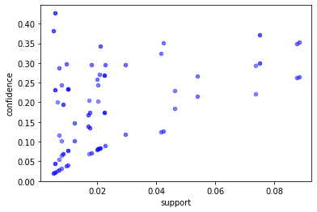

```python
plt.xlabel('support')
plt.ylabel('confidence')
for i in range(a_r.shape[0]):
    plt.scatter(a_r.support[i],a_r.confidence[i],s=20,c='b',alpha=(a_r.lift.iloc[i])/(a_r.lift.iloc[0])*0.8/(a_r.lift.iloc[0]-a_r.lift.iloc[-1])+0.2)
```

绘制support-confidence散点图  
其中cosine值的大小通过透明度反应出来

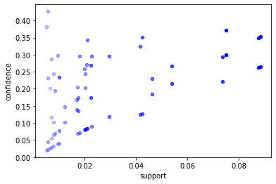

```python
plt.xlabel('support')
plt.ylabel('confidence')
a_r = a_r.sort_values(by='cosine',ascending=False).reset_index(drop=True)
for i in range(a_r.shape[0]):
    plt.scatter(a_r.support[i],a_r.confidence[i],s=20,c='b',alpha=(a_r.cosine.iloc[i])/(a_r.cosine.iloc[0]))
```

绘制support-confidence散点图  
其中Kulc值的大小通过透明度反应出来

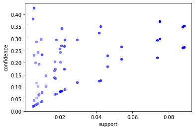

```python
plt.xlabel('support')
plt.ylabel('confidence')
a_r = a_r.sort_values(by='Kulc',ascending=False).reset_index(drop=True)
for i in range(a_r.shape[0]):
    plt.scatter(a_r.support[i],a_r.confidence[i],s=20,c='b',alpha=(a_r.Kulc.iloc[i])/(a_r.Kulc.iloc[0]))
```

绘制support-confidence散点图  
其中Jaccard值的大小通过透明度反应出来

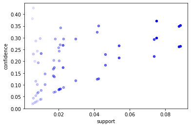

```python
plt.xlabel('support')
plt.ylabel('confidence')
a_r = a_r.sort_values(by='Jaccard',ascending=False).reset_index(drop=True)
for i in range(a_r.shape[0]):
    plt.scatter(a_r.support[i],a_r.confidence[i],s=20,c='b',alpha=(a_r.Jaccard.iloc[i])/(a_r.Jaccard.iloc[0]))
```

# 对RU数据集进行频繁模式与关联规则挖掘

```python
file1 = "RUvideos.csv"
file2 = "RU_category_id.json"
data = pd.read_csv(file1, keep_default_na=False, low_memory=False)
data
```

|  | video_id | trending_date | title | channel_title | category_id | publish_time | tags | views | likes | dislikes | comment_count | thumbnail_link | comments_disabled | ratings_disabled | video_error_or_removed | description |
| --- | --- | --- | --- | --- | --- | --- | --- | --- | --- | --- | --- | --- | --- | --- | --- | --- |
| 0 | gDuslQ9avLc | 17.14.11 | Захар и Полина учатся экономить | Т—Ж БОГАЧ | 22 | 2017-11-13T09:09:31.000Z | захар и полина\|"учимся экономить"\|"копить день... | 62408 | 334 | 190 | 50 | https://i.ytimg.com/vi/gDuslQ9avLc/default.jpg | False | False | False | Знакомьтесь, это Захар и Полина. Вместе с ними... |
| 1 | AOCJIFEA_jE | 17.14.11 | Биржа Мемов #29. Большой выпуск | Druzhko Show | 22 | 2017-11-13T17:32:11.000Z | биржа мемов\|"лев шагинян"\|"мемы"\|"пикчи"\|"друж... | 330043 | 43841 | 2244 | 2977 | https://i.ytimg.com/vi/AOCJIFEA_jE/default.jpg | False | False | False | В 29 выпуске Дружко Шоу Сергей сказал, что Бир... |
| 2 | VAWNQDgwwOM | 17.14.11 | ХАЙП КЭМП - СВОЙ СРЕДИ ЧУЖИХ | Юлик | 24 | 2017-11-13T16:11:31.000Z | юмор\|"комедия"\|"влог"\|"блог"\|"смешно"\|"смешное... | 424596 | 49854 | 714 | 2944 | https://i.ytimg.com/vi/VAWNQDgwwOM/default.jpg | False | False | False | http://kapitany.ru/!Yulik.cap - Факультет #Кап... |
| 3 | gknkFwKQfHg | 17.14.11 | Сочная кесадилья с курицей | Hochland | 22 | 2017-11-13T06:51:10.000Z | хохланд\|"сыр"\|"рецепты"\|"как приготовить"\|"вку... | 112851 | 3566 | 122 | 80 | https://i.ytimg.com/vi/gknkFwKQfHg/default.jpg | False | False | False | *** как готовить ресторанные блюда дома |
| 4 | 3sYvZcwzZr8 | 17.14.11 | КЛИПЫ РОДИТЕЛЕЙ НА ШКОЛЬНЫЙ ВЫПУСКНОЙ | Совергон | 24 | 2017-11-13T16:52:36.000Z | Совергон\|"Sovergon"\|"клипы"\|"родители"\|"школа"... | 243469 | 36216 | 631 | 1692 | https://i.ytimg.com/vi/3sYvZcwzZr8/default.jpg | False | False | False | ❏ КОНКУРС КАПИТАНЫ: http://kapitany.ru/!Soverg... |
| ... | ... | ... | ... | ... | ... | ... | ... | ... | ... | ... | ... | ... | ... | ... | ... | ... |
| 40734 | OMmR9THjVKM | 18.14.06 | У меня СДВГ! (Story booth на русском) Русская ... | Pastime Time | 22 | 2018-06-13T13:47:01.000Z | story booth на русском\|"story booth перевод"\|"... | 129488 | 5893 | 164 | 990 | https://i.ytimg.com/vi/OMmR9THjVKM/default.jpg | False | False | False | Котики в Blade and Soul - https://bit.ly/2JoOq... |
| 40735 | tX7p7NtNVDE | 18.14.06 | Мои Детские Травмы 2 (анимация) | CaGArt | 23 | 2018-06-12T09:38:38.000Z | кагарт\|"каги"\|"цагарт"\|"гагарт"\|"какарт"\|"милш... | 99163 | 4659 | 337 | 692 | https://i.ytimg.com/vi/tX7p7NtNVDE/default.jpg | False | False | False | Мои Детские Травмы 2 (анимация) ▶️Ск... |
| 40736 | KAyj5Xm1C64 | 18.14.06 | [ENG SUB] BTS PROM PARTY 2018 Intro + 2nd Gran... | DaisyxBTS 07 | 24 | 2018-06-13T12:51:23.000Z | [none] | 449611 | 24808 | 93 | 974 | https://i.ytimg.com/vi/KAyj5Xm1C64/default.jpg | False | False | False | ***I do NOT own anything. Just want to share t... |
| 40737 | 4PiSLIrsSiY | 18.14.06 | ОБЗОР ВАННОЙ КОМНАТЫ🛁/ТУАЛЕТНОЙ КОМНАТЫ🚽 + ДЕК... | Ксюша Лебедева | 22 | 2018-06-13T00:23:33.000Z | рум тур ванной комнаты\|"room tour bathroom"\|"д... | 14225 | 793 | 39 | 209 | https://i.ytimg.com/vi/4PiSLIrsSiY/default.jpg | False | False | False | Обзор ванной комнаты, туалетной комнаты+ декор... |
| 40738 | Ehy5foVfKOE | 18.14.06 | Плохой сигнал. Стань человеком! | Tubus Show | 29 | 2018-06-13T09:50:09.000Z | плохой сигнал\|"тубус шоу"\|"reebok"\|"стань чело... | 52340 | 7708 | 133 | 1819 | https://i.ytimg.com/vi/Ehy5foVfKOE/default.jpg | False | False | False | В 90-х годах прошлого века произошло коренное ... |

40739 rows × 16 columns

```python
print("数据包含：")
title_list = ('video_id  视频id','trending_date  流行日期','title  标题',
              'channel_title  频道标题','category_id  类别id','publish_time  发布时间',
              'tags  标签','views  观看量','likes  点赞量','dislikes  踩量',
              'comment_count  评论数量','thumbnail_link  视频链接',
              'comments_disabled  是否禁止评论','ratings_disabled  是否禁止评分',
              'video_error_or_removed  视频是否失效或被移除','description  介绍')
for i in range(len(title_list)):
    print(str(i+1) + '. ' + title_list[i])
```

```
数据包含：
1. video_id  视频id
2. trending_date  流行日期
3. title  标题
4. channel_title  频道标题
5. category_id  类别id
6. publish_time  发布时间
7. tags  标签
8. views  观看量
9. likes  点赞量
10. dislikes  踩量
11. comment_count  评论数量
12. thumbnail_link  视频链接
13. comments_disabled  是否禁止评论
14. ratings_disabled  是否禁止评分
15. video_error_or_removed  视频是否失效或被移除
16. description  介绍
```

# 对数据集进行处理，转换成适合进行关联规则挖掘的形式

在数据处理时，我们挖掘视频类别(category)与观看量(views)的关联关系，从而挖掘出更多人喜欢的视频类别。

```python
df = data[['category_id','views']]
df
```

|  | category_id | views |
| --- | --- | --- |
| 0 | 22 | 62408 |
| 1 | 22 | 330043 |
| 2 | 24 | 424596 |
| 3 | 22 | 112851 |
| 4 | 24 | 243469 |
| ... | ... | ... |
| 40734 | 22 | 129488 |
| 40735 | 23 | 99163 |
| 40736 | 24 | 449611 |
| 40737 | 22 | 14225 |
| 40738 | 29 | 52340 |

40739 rows × 2 columns

把.json文件中的category_id映射到具体的category类别名

```python
with open(file2, 'r') as f:
    content = json.load(f)
category_map = {}
for i in content['items']:
    category_map[int(i['id'])] = i['snippet']['title']
category_map
```

```
{1: 'Film & Animation',
 2: 'Autos & Vehicles',
 10: 'Music',
 15: 'Pets & Animals',
 17: 'Sports',
 18: 'Short Movies',
 19: 'Travel & Events',
 20: 'Gaming',
 21: 'Videoblogging',
 22: 'People & Blogs',
 23: 'Comedy',
 24: 'Entertainment',
 25: 'News & Politics',
 26: 'Howto & Style',
 27: 'Education',
```

[output cut: 16 more lines]

```python
t = df['category_id'].map(category_map)
df = pd.concat([df,t],axis=1)
df.columns=['category_id','views','category']
```

由于观看量（views）为数值型数据，需要将其转化为离散型数据。按照五数分布及离群点划分视频观看等级，并按照模型传入数据的格式将其转换为模型可接受的数据。

```python
grade = []
for i in df['views'].values:
    views_map = lambda x:{x>=453946:'A',195131<=x<453946:'B',66316<=x<195131:'C',
                          22587<=x<66316:'D',117<=x<22587:'E'}
    grade.append(views_map(i)[True])
df['views_grade'] = grade
df = df.drop(['category_id', 'views'], axis = 1)
df
```

|  | category | views_grade |
| --- | --- | --- |
| 0 | People & Blogs | D |
| 1 | People & Blogs | B |
| 2 | Entertainment | B |
| 3 | People & Blogs | C |
| 4 | Entertainment | B |
| ... | ... | ... |
| 40734 | People & Blogs | C |
| 40735 | Comedy | C |
| 40736 | Entertainment | B |
| 40737 | People & Blogs | E |
| 40738 | NaN | D |

40739 rows × 2 columns

```python
def deal(data):
    return data.dropna().tolist()
df_arr = df.apply(deal,axis=1).tolist() # 转化成列表
te = TE()  # 定义模型
df_tf = te.fit_transform(df_arr)
df = pd.DataFrame(df_tf,columns=te.columns_)
df
```

|  | A | Autos & Vehicles | B | C | Comedy | D | E | Education | Entertainment | Film & Animation | ... | Howto & Style | Movies | Music | News & Politics | People & Blogs | Pets & Animals | Science & Technology | Shows | Sports | Travel & Events |
| --- | --- | --- | --- | --- | --- | --- | --- | --- | --- | --- | --- | --- | --- | --- | --- | --- | --- | --- | --- | --- | --- |
| 0 | False | False | False | False | False | True | False | False | False | False | ... | False | False | False | False | True | False | False | False | False | False |
| 1 | False | False | True | False | False | False | False | False | False | False | ... | False | False | False | False | True | False | False | False | False | False |
| 2 | False | False | True | False | False | False | False | False | True | False | ... | False | False | False | False | False | False | False | False | False | False |
| 3 | False | False | False | True | False | False | False | False | False | False | ... | False | False | False | False | True | False | False | False | False | False |
| 4 | False | False | True | False | False | False | False | False | True | False | ... | False | False | False | False | False | False | False | False | False | False |
| ... | ... | ... | ... | ... | ... | ... | ... | ... | ... | ... | ... | ... | ... | ... | ... | ... | ... | ... | ... | ... | ... |
| 40734 | False | False | False | True | False | False | False | False | False | False | ... | False | False | False | False | True | False | False | False | False | False |
| 40735 | False | False | False | True | True | False | False | False | False | False | ... | False | False | False | False | False | False | False | False | False | False |
| 40736 | False | False | True | False | False | False | False | False | True | False | ... | False | False | False | False | False | False | False | False | False | False |
| 40737 | False | False | False | False | False | False | True | False | False | False | ... | False | False | False | False | True | False | False | False | False | False |
| 40738 | False | False | False | False | False | True | False | False | False | False | ... | False | False | False | False | False | False | False | False | False | False |

40739 rows × 21 columns

# 找出频繁模式

```python
freq_itemsets = apriori(df,min_support=0.005,use_colnames=True)
freq_itemsets.sort_values(by='support',ascending=False,inplace=True)
freq_itemsets
```

|  | support | itemsets |
| --- | --- | --- |
| 14 | 0.254056 | (People & Blogs) |
| 3 | 0.250006 | (C) |
| 5 | 0.250006 | (D) |
| 6 | 0.249982 | (E) |
| 8 | 0.145880 | (Entertainment) |
| ... | ... | ... |
| 23 | 0.006088 | (A, Howto & Style) |
| 58 | 0.005523 | (D, Pets & Animals) |
| 37 | 0.005474 | (B, Science & Technology) |
| 27 | 0.005425 | (A, Science & Technology) |
| 22 | 0.005032 | (A, Film & Animation) |

69 rows × 2 columns

# 导出关联规则，计算其支持度和置信度

```python
a_r = ar(freq_itemsets,metric='lift')
a_r = a_r.sort_values(by='lift',ascending=False).reset_index(drop=True)
a_r
```

|  | antecedents | consequents | antecedent support | consequent support | support | confidence | lift | leverage | conviction |
| --- | --- | --- | --- | --- | --- | --- | --- | --- | --- |
| 0 | (Music) | (A) | 0.046516 | 0.113037 | 0.013501 | 0.290237 | 2.567640 | 0.008243 | 1.249662 |
| 1 | (A) | (Music) | 0.113037 | 0.046516 | 0.013501 | 0.119435 | 2.567640 | 0.008243 | 1.082810 |
| 2 | (E) | (Education) | 0.249982 | 0.017526 | 0.011144 | 0.044580 | 2.543605 | 0.006763 | 1.028316 |
| 3 | (Education) | (E) | 0.017526 | 0.249982 | 0.011144 | 0.635854 | 2.543605 | 0.006763 | 2.059666 |
| 4 | (A) | (Science & Technology) | 0.113037 | 0.027811 | 0.005425 | 0.047991 | 1.725612 | 0.002281 | 1.021197 |
| ... | ... | ... | ... | ... | ... | ... | ... | ... | ... |
| 69 | (E) | (Sports) | 0.249982 | 0.048308 | 0.010236 | 0.040947 | 0.847623 | -0.001840 | 0.992325 |
| 70 | (Film & Animation) | (B) | 0.074646 | 0.136969 | 0.008591 | 0.115094 | 0.840287 | -0.001633 | 0.975279 |
| 71 | (B) | (Film & Animation) | 0.136969 | 0.074646 | 0.008591 | 0.062724 | 0.840287 | -0.001633 | 0.987280 |
| 72 | (D) | (Comedy) | 0.250006 | 0.075235 | 0.015268 | 0.061070 | 0.811726 | -0.003541 | 0.984914 |
| 73 | (Comedy) | (D) | 0.075235 | 0.250006 | 0.015268 | 0.202936 | 0.811726 | -0.003541 | 0.940946 |

74 rows × 9 columns

# 对规则进行评价

对规则进行评价,计算余弦、Kulc和Jaccard

```python
t = []
for i in range(a_r.shape[0]):
    item = a_r.iloc[i]
    t.append(item.support/math.sqrt(item['antecedent support']*item['consequent support']))
a_r['cosine'] = t
```

```python
t = []
for i in range(a_r.shape[0]):
    item = a_r.iloc[i]
    t.append(0.5*(item.support/item['antecedent support']+item.support/item['consequent support']))
a_r['Kulc'] = t
```

```python
t = []
for i in range(a_r.shape[0]):
    item = a_r.iloc[i]
    t.append(item.support/(item['antecedent support']+item['consequent support']-item.support))
a_r['Jaccard'] = t
```

```python
a_r
```

|  | antecedents | consequents | antecedent support | consequent support | support | confidence | lift | leverage | conviction | cosine | Kulc | Jaccard |
| --- | --- | --- | --- | --- | --- | --- | --- | --- | --- | --- | --- | --- |
| 0 | (Music) | (A) | 0.046516 | 0.113037 | 0.013501 | 0.290237 | 2.567640 | 0.008243 | 1.249662 | 0.186184 | 0.204836 | 0.092437 |
| 1 | (A) | (Music) | 0.113037 | 0.046516 | 0.013501 | 0.119435 | 2.567640 | 0.008243 | 1.082810 | 0.186184 | 0.204836 | 0.092437 |
| 2 | (E) | (Education) | 0.249982 | 0.017526 | 0.011144 | 0.044580 | 2.543605 | 0.006763 | 1.028316 | 0.168363 | 0.340217 | 0.043470 |
| 3 | (Education) | (E) | 0.017526 | 0.249982 | 0.011144 | 0.635854 | 2.543605 | 0.006763 | 2.059666 | 0.168363 | 0.340217 | 0.043470 |
| 4 | (A) | (Science & Technology) | 0.113037 | 0.027811 | 0.005425 | 0.047991 | 1.725612 | 0.002281 | 1.021197 | 0.096753 | 0.121524 | 0.040058 |
| ... | ... | ... | ... | ... | ... | ... | ... | ... | ... | ... | ... | ... |
| 69 | (E) | (Sports) | 0.249982 | 0.048308 | 0.010236 | 0.040947 | 0.847623 | -0.001840 | 0.992325 | 0.093146 | 0.126418 | 0.035535 |
| 70 | (Film & Animation) | (B) | 0.074646 | 0.136969 | 0.008591 | 0.115094 | 0.840287 | -0.001633 | 0.975279 | 0.084966 | 0.088909 | 0.042317 |
| 71 | (B) | (Film & Animation) | 0.136969 | 0.074646 | 0.008591 | 0.062724 | 0.840287 | -0.001633 | 0.987280 | 0.084966 | 0.088909 | 0.042317 |
| 72 | (D) | (Comedy) | 0.250006 | 0.075235 | 0.015268 | 0.061070 | 0.811726 | -0.003541 | 0.984914 | 0.111325 | 0.132003 | 0.049256 |
| 73 | (Comedy) | (D) | 0.075235 | 0.250006 | 0.015268 | 0.202936 | 0.811726 | -0.003541 | 0.940946 | 0.111325 | 0.132003 | 0.049256 |

74 rows × 12 columns

# 对挖掘结果进行分析

```python
a_r = a_r.sort_values(by='lift',ascending=False).reset_index(drop=True)
a_r.head(30)
```

|  | antecedents | consequents | antecedent support | consequent support | support | confidence | lift | leverage | conviction | cosine | Kulc | Jaccard |
| --- | --- | --- | --- | --- | --- | --- | --- | --- | --- | --- | --- | --- |
| 0 | (Music) | (A) | 0.046516 | 0.113037 | 0.013501 | 0.290237 | 2.567640 | 0.008243 | 1.249662 | 0.186184 | 0.204836 | 0.092437 |
| 1 | (A) | (Music) | 0.113037 | 0.046516 | 0.013501 | 0.119435 | 2.567640 | 0.008243 | 1.082810 | 0.186184 | 0.204836 | 0.092437 |
| 2 | (E) | (Education) | 0.249982 | 0.017526 | 0.011144 | 0.044580 | 2.543605 | 0.006763 | 1.028316 | 0.168363 | 0.340217 | 0.043470 |
| 3 | (Education) | (E) | 0.017526 | 0.249982 | 0.011144 | 0.635854 | 2.543605 | 0.006763 | 2.059666 | 0.168363 | 0.340217 | 0.043470 |
| 4 | (A) | (Science & Technology) | 0.113037 | 0.027811 | 0.005425 | 0.047991 | 1.725612 | 0.002281 | 1.021197 | 0.096753 | 0.121524 | 0.040058 |
| 5 | (Science & Technology) | (A) | 0.027811 | 0.113037 | 0.005425 | 0.195057 | 1.725612 | 0.002281 | 1.101896 | 0.096753 | 0.121524 | 0.040058 |
| 6 | (Pets & Animals) | (E) | 0.014826 | 0.249982 | 0.006358 | 0.428808 | 1.715358 | 0.002651 | 1.313076 | 0.104429 | 0.227120 | 0.024599 |
| 7 | (E) | (Pets & Animals) | 0.249982 | 0.014826 | 0.006358 | 0.025432 | 1.715358 | 0.002651 | 1.010883 | 0.104429 | 0.227120 | 0.024599 |
| 8 | (Howto & Style) | (E) | 0.049093 | 0.249982 | 0.020325 | 0.414000 | 1.656122 | 0.008052 | 1.279895 | 0.183466 | 0.247652 | 0.072913 |
| 9 | (E) | (Howto & Style) | 0.249982 | 0.049093 | 0.020325 | 0.081304 | 1.656122 | 0.008052 | 1.035062 | 0.183466 | 0.247652 | 0.072913 |
| 10 | (B) | (Comedy) | 0.136969 | 0.075235 | 0.017060 | 0.124552 | 1.655505 | 0.006755 | 1.056333 | 0.168055 | 0.175653 | 0.087421 |
| 11 | (Comedy) | (B) | 0.075235 | 0.136969 | 0.017060 | 0.226754 | 1.655505 | 0.006755 | 1.116113 | 0.168055 | 0.175653 | 0.087421 |
| 12 | (Comedy) | (A) | 0.075235 | 0.113037 | 0.014016 | 0.186297 | 1.648111 | 0.005512 | 1.090033 | 0.151987 | 0.155146 | 0.080434 |
| 13 | (A) | (Comedy) | 0.113037 | 0.075235 | 0.014016 | 0.123996 | 1.648111 | 0.005512 | 1.055663 | 0.151987 | 0.155146 | 0.080434 |
| 14 | (Entertainment) | (A) | 0.145880 | 0.113037 | 0.026314 | 0.180380 | 1.595768 | 0.009824 | 1.082164 | 0.204917 | 0.206585 | 0.113128 |
| 15 | (A) | (Entertainment) | 0.113037 | 0.145880 | 0.026314 | 0.232790 | 1.595768 | 0.009824 | 1.113281 | 0.204917 | 0.206585 | 0.113128 |
| 16 | (D) | (Pets & Animals) | 0.250006 | 0.014826 | 0.005523 | 0.022091 | 1.490030 | 0.001816 | 1.007429 | 0.090716 | 0.197304 | 0.021299 |
| 17 | (Pets & Animals) | (D) | 0.014826 | 0.250006 | 0.005523 | 0.372517 | 1.490030 | 0.001816 | 1.195241 | 0.090716 | 0.197304 | 0.021299 |
| 18 | (Entertainment) | (B) | 0.145880 | 0.136969 | 0.029382 | 0.201413 | 1.470498 | 0.009401 | 1.080697 | 0.207862 | 0.207965 | 0.115921 |
| 19 | (B) | (Entertainment) | 0.136969 | 0.145880 | 0.029382 | 0.214516 | 1.470498 | 0.009401 | 1.087381 | 0.207862 | 0.207965 | 0.115921 |
| 20 | (A) | (Autos & Vehicles) | 0.113037 | 0.038857 | 0.006431 | 0.056895 | 1.464202 | 0.002039 | 1.019126 | 0.097039 | 0.111202 | 0.044212 |
| 21 | (Autos & Vehicles) | (A) | 0.038857 | 0.113037 | 0.006431 | 0.165509 | 1.464202 | 0.002039 | 1.062879 | 0.097039 | 0.111202 | 0.044212 |
| 22 | (Autos & Vehicles) | (B) | 0.038857 | 0.136969 | 0.007781 | 0.200253 | 1.462024 | 0.002459 | 1.079129 | 0.106660 | 0.128531 | 0.046304 |
| 23 | (B) | (Autos & Vehicles) | 0.136969 | 0.038857 | 0.007781 | 0.056810 | 1.462024 | 0.002459 | 1.019034 | 0.106660 | 0.128531 | 0.046304 |
| 24 | (E) | (People & Blogs) | 0.249982 | 0.254056 | 0.091509 | 0.366064 | 1.440879 | 0.028000 | 1.176687 | 0.363117 | 0.363129 | 0.221826 |
| 25 | (People & Blogs) | (E) | 0.254056 | 0.249982 | 0.091509 | 0.360193 | 1.440879 | 0.028000 | 1.172258 | 0.363117 | 0.363129 | 0.221826 |
| 26 | (Science & Technology) | (C) | 0.027811 | 0.250006 | 0.010015 | 0.360106 | 1.440388 | 0.003062 | 1.172059 | 0.120106 | 0.200082 | 0.037397 |
| 27 | (C) | (Science & Technology) | 0.250006 | 0.027811 | 0.010015 | 0.040059 | 1.440388 | 0.003062 | 1.012759 | 0.120106 | 0.200082 | 0.037397 |
| 28 | (Science & Technology) | (B) | 0.027811 | 0.136969 | 0.005474 | 0.196823 | 1.436981 | 0.001665 | 1.074520 | 0.088690 | 0.118393 | 0.034361 |
| 29 | (B) | (Science & Technology) | 0.136969 | 0.027811 | 0.005474 | 0.039964 | 1.436981 | 0.001665 | 1.012659 | 0.088690 | 0.118393 | 0.034361 |

由结果可以看出，在RU_video数据集中：  
类别（category）与观看量（views）相关性较强的前五个种类为：Music、Education、Science & Technology、Pets & Animals、Howto & Style。  
Music种类视频的观看等级为A级，说明观看此类视频的人数最多，Music类别与观看量（views）之间有非常强的相关性。Education种类视频的观看等级为E级，说明观看此类视频的人数最少，但Education类别与观看量之间仍具有很强的相关性。

# 可视化展示

绘制support-confidence散点图  
其中lift值的大小通过透明度反应出来

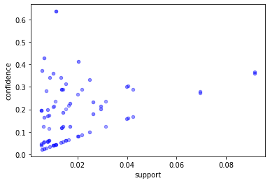

```python
plt.xlabel('support')
plt.ylabel('confidence')
for i in range(a_r.shape[0]):
    plt.scatter(a_r.support[i],a_r.confidence[i],s=20,c='b',alpha=(a_r.lift.iloc[i])/(a_r.lift.iloc[0])*0.8/(a_r.lift.iloc[0]-a_r.lift.iloc[-1])+0.2)
```

绘制support-confidence散点图  
其中cosine值的大小通过透明度反应出来

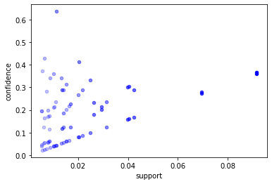

```python
plt.xlabel('support')
plt.ylabel('confidence')
a_r = a_r.sort_values(by='cosine',ascending=False).reset_index(drop=True)
for i in range(a_r.shape[0]):
    plt.scatter(a_r.support[i],a_r.confidence[i],s=20,c='b',alpha=(a_r.cosine.iloc[i])/(a_r.cosine.iloc[0]))
```

绘制support-confidence散点图  
其中Kulc值的大小通过透明度反应出来

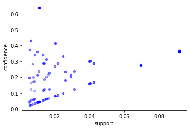

```python
plt.xlabel('support')
plt.ylabel('confidence')
a_r = a_r.sort_values(by='Kulc',ascending=False).reset_index(drop=True)
for i in range(a_r.shape[0]):
    plt.scatter(a_r.support[i],a_r.confidence[i],s=20,c='b',alpha=(a_r.Kulc.iloc[i])/(a_r.Kulc.iloc[0]))
```

绘制support-confidence散点图  
其中Jaccard值的大小通过透明度反应出来

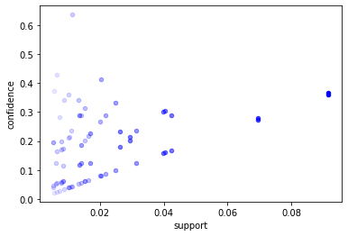

```python
plt.xlabel('support')
plt.ylabel('confidence')
a_r = a_r.sort_values(by='Jaccard',ascending=False).reset_index(drop=True)
for i in range(a_r.shape[0]):
    plt.scatter(a_r.support[i],a_r.confidence[i],s=20,c='b',alpha=(a_r.Jaccard.iloc[i])/(a_r.Jaccard.iloc[0]))
```

# 对US数据集进行频繁模式与关联规则挖掘

```python
file1 = "USvideos.csv"
file2 = "US_category_id.json"
data = pd.read_csv(file1, keep_default_na=False, low_memory=False)
data
```

|  | video_id | trending_date | title | channel_title | category_id | publish_time | tags | views | likes | dislikes | comment_count | thumbnail_link | comments_disabled | ratings_disabled | video_error_or_removed | description |
| --- | --- | --- | --- | --- | --- | --- | --- | --- | --- | --- | --- | --- | --- | --- | --- | --- |
| 0 | 2kyS6SvSYSE | 17.14.11 | WE WANT TO TALK ABOUT OUR MARRIAGE | CaseyNeistat | 22 | 2017-11-13T17:13:01.000Z | SHANtell martin | 748374 | 57527 | 2966 | 15954 | https://i.ytimg.com/vi/2kyS6SvSYSE/default.jpg | False | False | False | SHANTELL'S CHANNEL - https://www.youtube.com/s... |
| 1 | 1ZAPwfrtAFY | 17.14.11 | The Trump Presidency: Last Week Tonight with J... | LastWeekTonight | 24 | 2017-11-13T07:30:00.000Z | last week tonight trump presidency\|"last week ... | 2418783 | 97185 | 6146 | 12703 | https://i.ytimg.com/vi/1ZAPwfrtAFY/default.jpg | False | False | False | One year after the presidential election, John... |
| 2 | 5qpjK5DgCt4 | 17.14.11 | Racist Superman \| Rudy Mancuso, King Bach & Le... | Rudy Mancuso | 23 | 2017-11-12T19:05:24.000Z | racist superman\|"rudy"\|"mancuso"\|"king"\|"bach"... | 3191434 | 146033 | 5339 | 8181 | https://i.ytimg.com/vi/5qpjK5DgCt4/default.jpg | False | False | False | WATCH MY PREVIOUS VIDEO ▶ \n\nSUBSCRIBE ► http... |
| 3 | puqaWrEC7tY | 17.14.11 | Nickelback Lyrics: Real or Fake? | Good Mythical Morning | 24 | 2017-11-13T11:00:04.000Z | rhett and link\|"gmm"\|"good mythical morning"\|"... | 343168 | 10172 | 666 | 2146 | https://i.ytimg.com/vi/puqaWrEC7tY/default.jpg | False | False | False | Today we find out if Link is a Nickelback amat... |
| 4 | d380meD0W0M | 17.14.11 | I Dare You: GOING BALD!? | nigahiga | 24 | 2017-11-12T18:01:41.000Z | ryan\|"higa"\|"higatv"\|"nigahiga"\|"i dare you"\|"... | 2095731 | 132235 | 1989 | 17518 | https://i.ytimg.com/vi/d380meD0W0M/default.jpg | False | False | False | I know it's been a while since we did this sho... |
| ... | ... | ... | ... | ... | ... | ... | ... | ... | ... | ... | ... | ... | ... | ... | ... | ... |
| 40944 | BZt0qjTWNhw | 18.14.06 | The Cat Who Caught the Laser | AaronsAnimals | 15 | 2018-05-18T13:00:04.000Z | aarons animals\|"aarons"\|"animals"\|"cat"\|"cats"... | 1685609 | 38160 | 1385 | 2657 | https://i.ytimg.com/vi/BZt0qjTWNhw/default.jpg | False | False | False | The Cat Who Caught the Laser - Aaron's Animals |
| 40945 | 1h7KV2sjUWY | 18.14.06 | True Facts : Ant Mutualism | zefrank1 | 22 | 2018-05-18T01:00:06.000Z | [none] | 1064798 | 60008 | 382 | 3936 | https://i.ytimg.com/vi/1h7KV2sjUWY/default.jpg | False | False | False |  |
| 40946 | D6Oy4LfoqsU | 18.14.06 | I GAVE SAFIYA NYGAARD A PERFECT HAIR MAKEOVER ... | Brad Mondo | 24 | 2018-05-18T17:34:22.000Z | I gave safiya nygaard a perfect hair makeover ... | 1066451 | 48068 | 1032 | 3992 | https://i.ytimg.com/vi/D6Oy4LfoqsU/default.jpg | False | False | False | I had so much fun transforming Safiyas hair in... |
| 40947 | oV0zkMe1K8s | 18.14.06 | How Black Panther Should Have Ended | How It Should Have Ended | 1 | 2018-05-17T17:00:04.000Z | Black Panther\|"HISHE"\|"Marvel"\|"Infinity War"\|... | 5660813 | 192957 | 2846 | 13088 | https://i.ytimg.com/vi/oV0zkMe1K8s/default.jpg | False | False | False | How Black Panther Should Have EndedWatch More ... |
| 40948 | ooyjaVdt-jA | 18.14.06 | Official Call of Duty®: Black Ops 4 — Multipla... | Call of Duty | 20 | 2018-05-17T17:09:38.000Z | call of duty\|"cod"\|"activision"\|"Black Ops 4" | 10306119 | 357079 | 212976 | 144795 | https://i.ytimg.com/vi/ooyjaVdt-jA/default.jpg | False | False | False | Call of Duty: Black Ops 4 Multiplayer raises t... |

40949 rows × 16 columns

```python
print("数据包含：")
title_list = ('video_id  视频id','trending_date  流行日期','title  标题',
              'channel_title  频道标题','category_id  类别id','publish_time  发布时间',
              'tags  标签','views  观看量','likes  点赞量','dislikes  踩量',
              'comment_count  评论数量','thumbnail_link  视频链接',
              'comments_disabled  是否禁止评论','ratings_disabled  是否禁止评分',
              'video_error_or_removed  视频是否失效或被移除','description  介绍')
for i in range(len(title_list)):
    print(str(i+1) + '. ' + title_list[i])
```

```
数据包含：
1. video_id  视频id
2. trending_date  流行日期
3. title  标题
4. channel_title  频道标题
5. category_id  类别id
6. publish_time  发布时间
7. tags  标签
8. views  观看量
9. likes  点赞量
10. dislikes  踩量
11. comment_count  评论数量
12. thumbnail_link  视频链接
13. comments_disabled  是否禁止评论
14. ratings_disabled  是否禁止评分
15. video_error_or_removed  视频是否失效或被移除
16. description  介绍
```

# 对数据集进行处理，转换成适合进行关联规则挖掘的形式

在数据处理时，我们挖掘视频类别(category)与观看量(views)的关联关系，从而挖掘出更多人喜欢的视频类别。

```python
df = data[['category_id','views']]
df
```

|  | category_id | views |
| --- | --- | --- |
| 0 | 22 | 748374 |
| 1 | 24 | 2418783 |
| 2 | 23 | 3191434 |
| 3 | 24 | 343168 |
| 4 | 24 | 2095731 |
| ... | ... | ... |
| 40944 | 15 | 1685609 |
| 40945 | 22 | 1064798 |
| 40946 | 24 | 1066451 |
| 40947 | 1 | 5660813 |
| 40948 | 20 | 10306119 |

40949 rows × 2 columns

把.json文件中的category_id映射到具体的category类别名

```python
with open(file2, 'r') as f:
    content = json.load(f)
category_map = {}
for i in content['items']:
    category_map[int(i['id'])] = i['snippet']['title']
category_map
```

```
{1: 'Film & Animation',
 2: 'Autos & Vehicles',
 10: 'Music',
 15: 'Pets & Animals',
 17: 'Sports',
 18: 'Short Movies',
 19: 'Travel & Events',
 20: 'Gaming',
 21: 'Videoblogging',
 22: 'People & Blogs',
 23: 'Comedy',
 24: 'Entertainment',
 25: 'News & Politics',
 26: 'Howto & Style',
 27: 'Education',
```

[output cut: 17 more lines]

```python
t = df['category_id'].map(category_map)
df = pd.concat([df,t],axis=1)
df.columns=['category_id','views','category']
```

由于观看量（views）为数值型数据，需要将其转化为离散型数据。按照五数分布及离群点划分视频观看等级，并按照模型传入数据的格式将其转换为模型可接受的数据。

```python
grade = []
for i in df['views'].values:
    views_map = lambda x:{x>=4194399:'A',1823157<=x<4194399:'B',681861<=x<1823157:'C',
                          242329<=x<681861:'D',549<=x<242329:'E'}
    grade.append(views_map(i)[True])
df['views_grade'] = grade
df = df.drop(['category_id', 'views'], axis = 1)
df
```

|  | category | views_grade |
| --- | --- | --- |
| 0 | People & Blogs | C |
| 1 | Entertainment | B |
| 2 | Comedy | B |
| 3 | Entertainment | D |
| 4 | Entertainment | B |
| ... | ... | ... |
| 40944 | Pets & Animals | C |
| 40945 | People & Blogs | C |
| 40946 | Entertainment | C |
| 40947 | Film & Animation | A |
| 40948 | Gaming | A |

40949 rows × 2 columns

```python
def deal(data):
    return data.dropna().tolist()
df_arr = df.apply(deal,axis=1).tolist() # 转化成列表
te = TE()  # 定义模型
df_tf = te.fit_transform(df_arr)
df = pd.DataFrame(df_tf,columns=te.columns_)
df
```

|  | A | Autos & Vehicles | B | C | Comedy | D | E | Education | Entertainment | Film & Animation | ... | Howto & Style | Music | News & Politics | Nonprofits & Activism | People & Blogs | Pets & Animals | Science & Technology | Shows | Sports | Travel & Events |
| --- | --- | --- | --- | --- | --- | --- | --- | --- | --- | --- | --- | --- | --- | --- | --- | --- | --- | --- | --- | --- | --- |
| 0 | False | False | False | True | False | False | False | False | False | False | ... | False | False | False | False | True | False | False | False | False | False |
| 1 | False | False | True | False | False | False | False | False | True | False | ... | False | False | False | False | False | False | False | False | False | False |
| 2 | False | False | True | False | True | False | False | False | False | False | ... | False | False | False | False | False | False | False | False | False | False |
| 3 | False | False | False | False | False | True | False | False | True | False | ... | False | False | False | False | False | False | False | False | False | False |
| 4 | False | False | True | False | False | False | False | False | True | False | ... | False | False | False | False | False | False | False | False | False | False |
| ... | ... | ... | ... | ... | ... | ... | ... | ... | ... | ... | ... | ... | ... | ... | ... | ... | ... | ... | ... | ... | ... |
| 40944 | False | False | False | True | False | False | False | False | False | False | ... | False | False | False | False | False | True | False | False | False | False |
| 40945 | False | False | False | True | False | False | False | False | False | False | ... | False | False | False | False | True | False | False | False | False | False |
| 40946 | False | False | False | True | False | False | False | False | True | False | ... | False | False | False | False | False | False | False | False | False | False |
| 40947 | True | False | False | False | False | False | False | False | False | True | ... | False | False | False | False | False | False | False | False | False | False |
| 40948 | True | False | False | False | False | False | False | False | False | False | ... | False | False | False | False | False | False | False | False | False | False |

40949 rows × 21 columns

# 找出频繁模式

```python
freq_itemsets = apriori(df,min_support=0.005,use_colnames=True)
freq_itemsets.sort_values(by='support',ascending=False,inplace=True)
freq_itemsets
```

|  | support | itemsets |
| --- | --- | --- |
| 3 | 0.249994 | (C) |
| 5 | 0.249994 | (D) |
| 6 | 0.249994 | (E) |
| 8 | 0.243327 | (Entertainment) |
| 12 | 0.158050 | (Music) |
| ... | ... | ... |
| 23 | 0.005983 | (A, Sports) |
| 32 | 0.005470 | (B, Sports) |
| 27 | 0.005373 | (B, Gaming) |
| 42 | 0.005226 | (Pets & Animals, C) |
| 37 | 0.005006 | (C, Gaming) |

67 rows × 2 columns

# 导出关联规则，计算其支持度和置信度

```python
a_r = ar(freq_itemsets,metric='lift')
a_r = a_r.sort_values(by='lift',ascending=False).reset_index(drop=True)
a_r
```

|  | antecedents | consequents | antecedent support | consequent support | support | confidence | lift | leverage | conviction |
| --- | --- | --- | --- | --- | --- | --- | --- | --- | --- |
| 0 | (A) | (Music) | 0.109868 | 0.158050 | 0.043982 | 0.400311 | 2.532809 | 0.026617 | 1.403978 |
| 1 | (Music) | (A) | 0.158050 | 0.109868 | 0.043982 | 0.278276 | 2.532809 | 0.026617 | 1.233340 |
| 2 | (E) | (News & Politics) | 0.249994 | 0.060734 | 0.030111 | 0.120445 | 1.983161 | 0.014927 | 1.067888 |
| 3 | (News & Politics) | (E) | 0.060734 | 0.249994 | 0.030111 | 0.495778 | 1.983161 | 0.014927 | 1.487452 |
| 4 | (Gaming) | (B) | 0.019952 | 0.140150 | 0.005373 | 0.269278 | 1.921355 | 0.002576 | 1.176713 |
| ... | ... | ... | ... | ... | ... | ... | ... | ... | ... |
| 75 | (Science & Technology) | (B) | 0.058634 | 0.140150 | 0.007277 | 0.124115 | 0.885587 | -0.000940 | 0.981693 |
| 76 | (E) | (Film & Animation) | 0.249994 | 0.057266 | 0.012284 | 0.049135 | 0.858017 | -0.002033 | 0.991449 |
| 77 | (Film & Animation) | (E) | 0.057266 | 0.249994 | 0.012284 | 0.214499 | 0.858017 | -0.002033 | 0.954812 |
| 78 | (C) | (Education) | 0.249994 | 0.040441 | 0.008132 | 0.032529 | 0.804367 | -0.001978 | 0.991823 |
| 79 | (Education) | (C) | 0.040441 | 0.249994 | 0.008132 | 0.201087 | 0.804367 | -0.001978 | 0.938783 |

80 rows × 9 columns

# 对规则进行评价

对规则进行评价,计算余弦、Kulc和Jaccard

```python
t = []
for i in range(a_r.shape[0]):
    item = a_r.iloc[i]
    t.append(item.support/math.sqrt(item['antecedent support']*item['consequent support']))
a_r['cosine'] = t
```

```python
t = []
for i in range(a_r.shape[0]):
    item = a_r.iloc[i]
    t.append(0.5*(item.support/item['antecedent support']+item.support/item['consequent support']))
a_r['Kulc'] = t
```

```python
t = []
for i in range(a_r.shape[0]):
    item = a_r.iloc[i]
    t.append(item.support/(item['antecedent support']+item['consequent support']-item.support))
a_r['Jaccard'] = t
```

```python
a_r
```

|  | antecedents | consequents | antecedent support | consequent support | support | confidence | lift | leverage | conviction | cosine | Kulc | Jaccard |
| --- | --- | --- | --- | --- | --- | --- | --- | --- | --- | --- | --- | --- |
| 0 | (A) | (Music) | 0.109868 | 0.158050 | 0.043982 | 0.400311 | 2.532809 | 0.026617 | 1.403978 | 0.333762 | 0.339293 | 0.196401 |
| 1 | (Music) | (A) | 0.158050 | 0.109868 | 0.043982 | 0.278276 | 2.532809 | 0.026617 | 1.233340 | 0.333762 | 0.339293 | 0.196401 |
| 2 | (E) | (News & Politics) | 0.249994 | 0.060734 | 0.030111 | 0.120445 | 1.983161 | 0.014927 | 1.067888 | 0.244365 | 0.308112 | 0.107301 |
| 3 | (News & Politics) | (E) | 0.060734 | 0.249994 | 0.030111 | 0.495778 | 1.983161 | 0.014927 | 1.487452 | 0.244365 | 0.308112 | 0.107301 |
| 4 | (Gaming) | (B) | 0.019952 | 0.140150 | 0.005373 | 0.269278 | 1.921355 | 0.002576 | 1.176713 | 0.101600 | 0.153806 | 0.034722 |
| ... | ... | ... | ... | ... | ... | ... | ... | ... | ... | ... | ... | ... |
| 75 | (Science & Technology) | (B) | 0.058634 | 0.140150 | 0.007277 | 0.124115 | 0.885587 | -0.000940 | 0.981693 | 0.080279 | 0.088020 | 0.038001 |
| 76 | (E) | (Film & Animation) | 0.249994 | 0.057266 | 0.012284 | 0.049135 | 0.858017 | -0.002033 | 0.991449 | 0.102662 | 0.131817 | 0.041643 |
| 77 | (Film & Animation) | (E) | 0.057266 | 0.249994 | 0.012284 | 0.214499 | 0.858017 | -0.002033 | 0.954812 | 0.102662 | 0.131817 | 0.041643 |
| 78 | (C) | (Education) | 0.249994 | 0.040441 | 0.008132 | 0.032529 | 0.804367 | -0.001978 | 0.991823 | 0.080877 | 0.116808 | 0.028806 |
| 79 | (Education) | (C) | 0.040441 | 0.249994 | 0.008132 | 0.201087 | 0.804367 | -0.001978 | 0.938783 | 0.080877 | 0.116808 | 0.028806 |

80 rows × 12 columns

# 对挖掘结果进行分析

```python
a_r = a_r.sort_values(by='lift',ascending=False).reset_index(drop=True)
a_r.head(30)
```

|  | antecedents | consequents | antecedent support | consequent support | support | confidence | lift | leverage | conviction | cosine | Kulc | Jaccard |
| --- | --- | --- | --- | --- | --- | --- | --- | --- | --- | --- | --- | --- |
| 0 | (A) | (Music) | 0.109868 | 0.158050 | 0.043982 | 0.400311 | 2.532809 | 0.026617 | 1.403978 | 0.333762 | 0.339293 | 0.196401 |
| 1 | (Music) | (A) | 0.158050 | 0.109868 | 0.043982 | 0.278276 | 2.532809 | 0.026617 | 1.233340 | 0.333762 | 0.339293 | 0.196401 |
| 2 | (E) | (News & Politics) | 0.249994 | 0.060734 | 0.030111 | 0.120445 | 1.983161 | 0.014927 | 1.067888 | 0.244365 | 0.308112 | 0.107301 |
| 3 | (News & Politics) | (E) | 0.060734 | 0.249994 | 0.030111 | 0.495778 | 1.983161 | 0.014927 | 1.487452 | 0.244365 | 0.308112 | 0.107301 |
| 4 | (Gaming) | (B) | 0.019952 | 0.140150 | 0.005373 | 0.269278 | 1.921355 | 0.002576 | 1.176713 | 0.101600 | 0.153806 | 0.034722 |
| 5 | (B) | (Gaming) | 0.140150 | 0.019952 | 0.005373 | 0.038334 | 1.921355 | 0.002576 | 1.019115 | 0.101600 | 0.153806 | 0.034722 |
| 6 | (D) | (Education) | 0.249994 | 0.040441 | 0.019292 | 0.077171 | 1.908259 | 0.009182 | 1.039802 | 0.191872 | 0.277112 | 0.071152 |
| 7 | (Education) | (D) | 0.040441 | 0.249994 | 0.019292 | 0.477053 | 1.908259 | 0.009182 | 1.434192 | 0.191872 | 0.277112 | 0.071152 |
| 8 | (A) | (Film & Animation) | 0.109868 | 0.057266 | 0.011478 | 0.104468 | 1.824241 | 0.005186 | 1.052708 | 0.144700 | 0.152447 | 0.073737 |
| 9 | (Film & Animation) | (A) | 0.057266 | 0.109868 | 0.011478 | 0.200426 | 1.824241 | 0.005186 | 1.113258 | 0.144700 | 0.152447 | 0.073737 |
| 10 | (Comedy) | (B) | 0.084422 | 0.140150 | 0.017290 | 0.204802 | 1.461305 | 0.005458 | 1.081303 | 0.158952 | 0.164084 | 0.083412 |
| 11 | (B) | (Comedy) | 0.140150 | 0.084422 | 0.017290 | 0.123366 | 1.461305 | 0.005458 | 1.044425 | 0.158952 | 0.164084 | 0.083412 |
| 12 | (Pets & Animals) | (D) | 0.022467 | 0.249994 | 0.007986 | 0.355435 | 1.421774 | 0.002369 | 1.163585 | 0.106553 | 0.193689 | 0.030194 |
| 13 | (D) | (Pets & Animals) | 0.249994 | 0.022467 | 0.007986 | 0.031943 | 1.421774 | 0.002369 | 1.009789 | 0.106553 | 0.193689 | 0.030194 |
| 14 | (B) | (Film & Animation) | 0.140150 | 0.057266 | 0.010452 | 0.074577 | 1.302291 | 0.002426 | 1.018706 | 0.116669 | 0.128547 | 0.055904 |
| 15 | (Film & Animation) | (B) | 0.057266 | 0.140150 | 0.010452 | 0.182516 | 1.302291 | 0.002426 | 1.051825 | 0.116669 | 0.128547 | 0.055904 |
| 16 | (Howto & Style) | (D) | 0.101248 | 0.249994 | 0.032870 | 0.324650 | 1.298633 | 0.007559 | 1.110545 | 0.206607 | 0.228067 | 0.103245 |
| 17 | (D) | (Howto & Style) | 0.249994 | 0.101248 | 0.032870 | 0.131484 | 1.298633 | 0.007559 | 1.034813 | 0.206607 | 0.228067 | 0.103245 |
| 18 | (C) | (Comedy) | 0.249994 | 0.084422 | 0.027376 | 0.109505 | 1.297110 | 0.006271 | 1.028167 | 0.188438 | 0.216887 | 0.089159 |
| 19 | (Comedy) | (C) | 0.084422 | 0.249994 | 0.027376 | 0.324270 | 1.297110 | 0.006271 | 1.109919 | 0.188438 | 0.216887 | 0.089159 |
| 20 | (Music) | (B) | 0.158050 | 0.140150 | 0.027888 | 0.176452 | 1.259026 | 0.005738 | 1.044081 | 0.187382 | 0.187721 | 0.103171 |
| 21 | (B) | (Music) | 0.140150 | 0.158050 | 0.027888 | 0.198989 | 1.259026 | 0.005738 | 1.051109 | 0.187382 | 0.187721 | 0.103171 |
| 22 | (Pets & Animals) | (E) | 0.022467 | 0.249994 | 0.006789 | 0.302174 | 1.208725 | 0.001172 | 1.074775 | 0.090587 | 0.164665 | 0.025554 |
| 23 | (E) | (Pets & Animals) | 0.249994 | 0.022467 | 0.006789 | 0.027156 | 1.208725 | 0.001172 | 1.004820 | 0.090587 | 0.164665 | 0.025554 |
| 24 | (Sports) | (E) | 0.053090 | 0.249994 | 0.015605 | 0.293928 | 1.175742 | 0.002332 | 1.062224 | 0.135452 | 0.178174 | 0.054281 |
| 25 | (E) | (Sports) | 0.249994 | 0.053090 | 0.015605 | 0.062421 | 1.175742 | 0.002332 | 1.009951 | 0.135452 | 0.178174 | 0.054281 |
| 26 | (People & Blogs) | (E) | 0.078390 | 0.249994 | 0.023004 | 0.293458 | 1.173860 | 0.003407 | 1.061517 | 0.164328 | 0.192739 | 0.075330 |
| 27 | (E) | (People & Blogs) | 0.249994 | 0.078390 | 0.023004 | 0.092019 | 1.173860 | 0.003407 | 1.015010 | 0.164328 | 0.192739 | 0.075330 |
| 28 | (C) | (Entertainment) | 0.249994 | 0.243327 | 0.069501 | 0.278011 | 1.142541 | 0.008671 | 1.048040 | 0.281794 | 0.281820 | 0.163987 |
| 29 | (Entertainment) | (C) | 0.243327 | 0.249994 | 0.069501 | 0.285628 | 1.142541 | 0.008671 | 1.049882 | 0.281794 | 0.281820 | 0.163987 |

由结果可以看出，在US_video数据集中：  
类别（category）与观看量（views）相关性较强的前五个种类为：Music、News & Politics、Gaming、Education、Film & Animation 。  
Music种类视频的观看等级为A级，说明观看此类视频的人数最多，Music类别与观看量（views）之间有非常强的相关性。News & Politics种类视频的观看等级为E级，说明观看此类视频的人数最少，但News & Politics类别与观看量之间仍具有很强的相关性。

# 可视化展示

绘制support-confidence散点图  
其中lift值的大小通过透明度反应出来

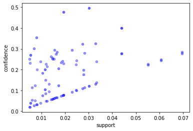

```python
plt.xlabel('support')
plt.ylabel('confidence')
for i in range(a_r.shape[0]):
    plt.scatter(a_r.support[i],a_r.confidence[i],s=20,c='b',alpha=(a_r.lift.iloc[i])/(a_r.lift.iloc[0])*0.8/(a_r.lift.iloc[0]-a_r.lift.iloc[-1])+0.2)
```

绘制support-confidence散点图  
其中cosine值的大小通过透明度反应出来

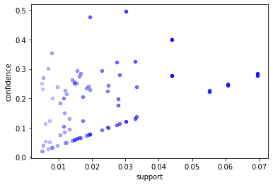

```python
plt.xlabel('support')
plt.ylabel('confidence')
a_r = a_r.sort_values(by='cosine',ascending=False).reset_index(drop=True)
for i in range(a_r.shape[0]):
    plt.scatter(a_r.support[i],a_r.confidence[i],s=20,c='b',alpha=(a_r.cosine.iloc[i])/(a_r.cosine.iloc[0]))
```

绘制support-confidence散点图  
其中Kulc值的大小通过透明度反应出来

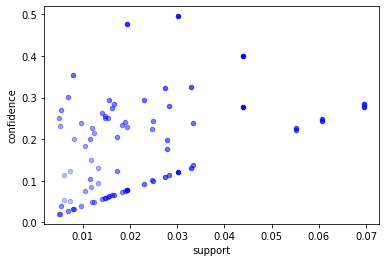

```python
plt.xlabel('support')
plt.ylabel('confidence')
a_r = a_r.sort_values(by='Kulc',ascending=False).reset_index(drop=True)
for i in range(a_r.shape[0]):
    plt.scatter(a_r.support[i],a_r.confidence[i],s=20,c='b',alpha=(a_r.Kulc.iloc[i])/(a_r.Kulc.iloc[0]))
```

绘制support-confidence散点图  
其中Jaccard值的大小通过透明度反应出来

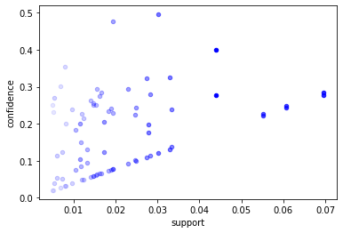

```python
plt.xlabel('support')
plt.ylabel('confidence')
a_r = a_r.sort_values(by='Jaccard',ascending=False).reset_index(drop=True)
for i in range(a_r.shape[0]):
    plt.scatter(a_r.support[i],a_r.confidence[i],s=20,c='b',alpha=(a_r.Jaccard.iloc[i])/(a_r.Jaccard.iloc[0]))
```